# HomeWork 2

## ID1:205914609

## ID2:207906884

Import relevant libraries

```python
import numpy as np
import pandas as pd
import matplotlib.pyplot as plt
import seaborn as sns
from datetime import datetime
```

## Sales:

Read sales data

```python
sales_df=pd.read_csv('sales.csv')
```

```python
sales_df.head()
```

|  | date | store_nbr | item_nbr | units |
| --- | --- | --- | --- | --- |
| 0 | 2012-01-01 | 1 | 1 | 0 |
| 1 | 2012-01-01 | 1 | 2 | 0 |
| 2 | 2012-01-01 | 1 | 3 | 0 |
| 3 | 2012-01-01 | 1 | 4 | 0 |
| 4 | 2012-01-01 | 1 | 5 | 0 |

Sales data consists of 4 attributes: date, store number, item number and units sold

```python
sales_df.shape
```

```
(4617600, 4)
```

```python
sales_df.dtypes
```

```
date         object
store_nbr     int64
item_nbr      int64
units         int64
dtype: object
```

Apart of the date attributes, all of the attributes are numeric  
All of the numeric attributes are integers, so we dont have mistakes in the data, like 1.5 units sold.

The sales data consists 4617600 rows of the number of items sold from each item in each store

```python
sales_df.describe()
```

|  | store_nbr | item_nbr | units |
| --- | --- | --- | --- |
| count | 4.617600e+06 | 4.617600e+06 | 4.617600e+06 |
| mean | 2.309108e+01 | 5.600000e+01 | 9.868756e-01 |
| std | 1.295281e+01 | 3.204164e+01 | 9.875798e+00 |
| min | 1.000000e+00 | 1.000000e+00 | 0.000000e+00 |
| 25% | 1.200000e+01 | 2.800000e+01 | 0.000000e+00 |
| 50% | 2.300000e+01 | 5.600000e+01 | 0.000000e+00 |
| 75% | 3.400000e+01 | 8.400000e+01 | 0.000000e+00 |
| max | 4.500000e+01 | 1.110000e+02 | 5.568000e+03 |

Obeservations:

```
1. most of the items did not sale at all durnig the years 2012-2014 <br>
2.We have 45 stores <br>
3.We have 111 different items in every store <br>
4.In average each item was sold less than 1 unit in every store <br>
5.The maximum units that were sold from an item form one store is 5568 units <br>
```

```python
sales_df.isnull().sum()
```

```
date         0
store_nbr    0
item_nbr     0
units        0
dtype: int64
```

We have no missing data at all.

```python
sales_df_grouped=sales_df.groupby('store_nbr')['units'].agg('sum')
```

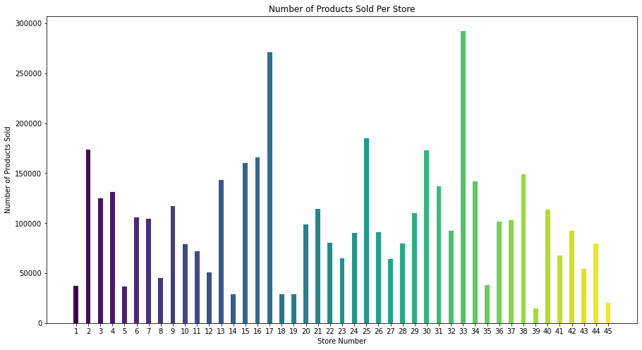

```python
my_cmap = plt.get_cmap("viridis")
rescale = lambda y: (y - np.min(sales_df_grouped.index)) / (np.max(sales_df_grouped.index) - np.min(sales_df_grouped.index))
plt.figure(figsize=(15, 8))
plt.bar(sales_df_grouped.index, sales_df_grouped, color=my_cmap(rescale(sales_df_grouped.index)),width = 0.4)

plt.xticks(np.arange(min(sales_df_grouped.index), max(sales_df_grouped.index)+1, 1))
plt.xlabel("Store Number")
plt.ylabel("Number of Products Sold")
plt.title("Number of Products Sold Per Store")
plt.show()
```

```python
sales_df_month=sales_df.copy()
sales_df_month
```

|  | date | store_nbr | item_nbr | units |
| --- | --- | --- | --- | --- |
| 0 | 2012-01-01 | 1 | 1 | 0 |
| 1 | 2012-01-01 | 1 | 2 | 0 |
| 2 | 2012-01-01 | 1 | 3 | 0 |
| 3 | 2012-01-01 | 1 | 4 | 0 |
| 4 | 2012-01-01 | 1 | 5 | 0 |
| ... | ... | ... | ... | ... |
| 4617595 | 2014-10-31 | 45 | 107 | 0 |
| 4617596 | 2014-10-31 | 45 | 108 | 0 |
| 4617597 | 2014-10-31 | 45 | 109 | 0 |
| 4617598 | 2014-10-31 | 45 | 110 | 0 |
| 4617599 | 2014-10-31 | 45 | 111 | 0 |

4617600 rows × 4 columns

```python
sales_df_month['year'] = pd.to_datetime(sales_df_month['date']).dt.year
sales_df_month['month']=pd.to_datetime(sales_df_month['date']).dt.month
sales_df_month['day']=pd.to_datetime(sales_df_month['date']).dt.day
sales_df_month.drop('date', axis=1, inplace=True)
sales_df_month
```

|  | store_nbr | item_nbr | units | year | month | day |
| --- | --- | --- | --- | --- | --- | --- |
| 0 | 1 | 1 | 0 | 2012 | 1 | 1 |
| 1 | 1 | 2 | 0 | 2012 | 1 | 1 |
| 2 | 1 | 3 | 0 | 2012 | 1 | 1 |
| 3 | 1 | 4 | 0 | 2012 | 1 | 1 |
| 4 | 1 | 5 | 0 | 2012 | 1 | 1 |
| ... | ... | ... | ... | ... | ... | ... |
| 4617595 | 45 | 107 | 0 | 2014 | 10 | 31 |
| 4617596 | 45 | 108 | 0 | 2014 | 10 | 31 |
| 4617597 | 45 | 109 | 0 | 2014 | 10 | 31 |
| 4617598 | 45 | 110 | 0 | 2014 | 10 | 31 |
| 4617599 | 45 | 111 | 0 | 2014 | 10 | 31 |

4617600 rows × 6 columns

```python
sales_df_grouped_month=sales_df_month.groupby('month')['units'].agg('sum')
```

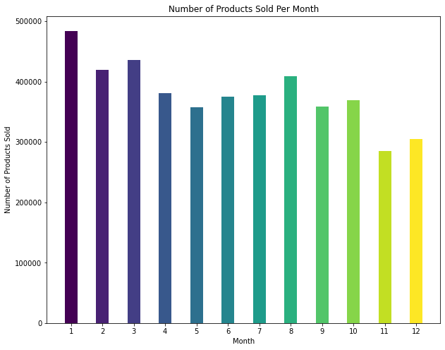

```python
my_cmap = plt.get_cmap("viridis")
rescale = lambda y: (y - np.min(sales_df_grouped_month.index)) / (np.max(sales_df_grouped_month.index) - np.min(sales_df_grouped_month.index))
plt.figure(figsize=(10, 8))
plt.bar(sales_df_grouped_month.index, sales_df_grouped_month, color=my_cmap(rescale(sales_df_grouped_month.index)),width = 0.4)

plt.xticks(np.arange(min(sales_df_grouped_month.index), max(sales_df_grouped_month.index)+1, 1))
plt.xlabel("Month")
plt.ylabel("Number of Products Sold")
plt.title("Number of Products Sold Per Month")
plt.show()
```

We can see that Januray is the month with the most products sold -probably because of new year's eve.

## Key:

Read key data

```python
key_df=pd.read_csv('key.csv')
```

```python
key_df.head()
```

|  | store_nbr | station_nbr |
| --- | --- | --- |
| 0 | 1 | 1 |
| 1 | 2 | 14 |
| 2 | 3 | 7 |
| 3 | 4 | 9 |
| 4 | 5 | 12 |

We can see that the key data tells us which store in near which weather station.  
The key data contains 2 attributes: store number and station number.

```python
key_df.shape
```

```
(45, 2)
```

The key data contains 45 rows- one row for each store

```python
key_df.dtypes
```

```
store_nbr      int64
station_nbr    int64
dtype: object
```

The key data contains only numeric attributes of type integer

```python
key_df.describe()
```

|  | store_nbr | station_nbr |
| --- | --- | --- |
| count | 45.000000 | 45.000000 |
| mean | 23.000000 | 11.266667 |
| std | 13.133926 | 5.019960 |
| min | 1.000000 | 1.000000 |
| 25% | 12.000000 | 7.000000 |
| 50% | 23.000000 | 12.000000 |
| 75% | 34.000000 | 15.000000 |
| max | 45.000000 | 20.000000 |

We can see that the staion numbers are betweeen 1 and 20.

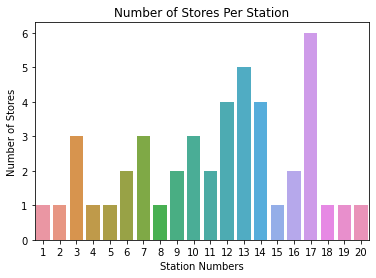

```python
key_countplot=sns.countplot(data=key_df, x='station_nbr')
key_countplot.set_title("Number of Stores Per Station")
key_countplot.set_ylabel("Number of Stores")
key_countplot.set_xlabel("Station Numbers")
```

We can see that station number 17 covers that most stores (6).  
Also every weather station covers at least 1 store.

```python
key_df.isnull().sum()
```

```
store_nbr      0
station_nbr    0
dtype: int64
```

We have no missing data at all.

## Weather:

Read weather data

```python
weather_df=pd.read_csv('weather.csv')
```

```python
weather_df.head()
```

|  | station_nbr | date | tmax | tmin | tavg | depart | dewpoint | wetbulb | heat | cool | sunrise | sunset | codesum | snowfall | preciptotal | stnpressure | sealevel | resultspeed | resultdir | avgspeed |
| --- | --- | --- | --- | --- | --- | --- | --- | --- | --- | --- | --- | --- | --- | --- | --- | --- | --- | --- | --- | --- |
| 0 | 1 | 2012-01-01 | 52 | 31 | 42 | M | 36 | 40 | 23 | 0 | - | - | RA FZFG BR | M | 0.05 | 29.78 | 29.92 | 3.6 | 20 | 4.6 |
| 1 | 2 | 2012-01-01 | 48 | 33 | 41 | 16 | 37 | 39 | 24 | 0 | 0716 | 1626 | RA | 0.0 | 0.07 | 28.82 | 29.91 | 9.1 | 23 | 11.3 |
| 2 | 3 | 2012-01-01 | 55 | 34 | 45 | 9 | 24 | 36 | 20 | 0 | 0735 | 1720 |  | 0.0 | 0.00 | 29.77 | 30.47 | 9.9 | 31 | 10.0 |
| 3 | 4 | 2012-01-01 | 63 | 47 | 55 | 4 | 28 | 43 | 10 | 0 | 0728 | 1742 |  | 0.0 | 0.00 | 29.79 | 30.48 | 8.0 | 35 | 8.2 |
| 4 | 6 | 2012-01-01 | 63 | 34 | 49 | 0 | 31 | 43 | 16 | 0 | 0727 | 1742 |  | 0.0 | 0.00 | 29.95 | 30.47 | 14.0 | 36 | 13.8 |

We can see that the weather data contains for every station various measurments in different days. There is missing data in column 'codesum'

```python
weather_df.tail(50)
```

|  | station_nbr | date | tmax | tmin | tavg | depart | dewpoint | wetbulb | heat | cool | sunrise | sunset | codesum | snowfall | preciptotal | stnpressure | sealevel | resultspeed | resultdir | avgspeed |
| --- | --- | --- | --- | --- | --- | --- | --- | --- | --- | --- | --- | --- | --- | --- | --- | --- | --- | --- | --- | --- |
| 20467 | 11 | 2014-10-29 | 85 | 58 | 72 | 5 | 62 | 65 | 0 | 7 | 0639 | 1742 | BR | 0.0 | 0.00 | 30.02 | 30.05 | 2.3 | 21 | 3.0 |
| 20468 | 12 | 2014-10-29 | 85 | 60 | 73 | M | 62 | 65 | 0 | 8 | - | - | BR | 0.0 | 0.00 | 30.02 | 30.05 | 1.8 | 21 | 3.3 |
| 20469 | 13 | 2014-10-29 | 69 | 29 | 49 | M | 18 | 37 | 16 | 0 | - | - |  | M | 0.00 | 24.34 | 30.12 | 1.6 | 15 | 6.3 |
| 20470 | 14 | 2014-10-29 | 74 | 41 | 58 | 2 | 36 | 47 | 7 | 0 | 0649 | 1739 |  | 0.0 | 0.00 | 28.77 | 30.16 | 2.8 | 17 | 4.0 |
| 20471 | 15 | 2014-10-29 | 58 | 41 | 50 | 7 | 48 | 49 | 15 | 0 | 0617 | 1642 | RA FG+ FG BR | 0.0 | 0.08 | 29.47 | 29.85 | 1.4 | 26 | 1.8 |
| 20472 | 16 | 2014-10-29 | 74 | 49 | 62 | M | 51 | 54 | 3 | 0 | - | - | RA FG+ FG BR | M | 0.04 | 29.72 | 29.82 | 3.7 | 27 | 4.7 |
| 20473 | 17 | 2014-10-29 | 73 | 39 | 56 | M | 42 | 48 | 9 | 0 | - | - |  | 0.0 | 0.00 | 29.50 | 30.19 | 0.9 | 19 | 1.4 |
| 20474 | 18 | 2014-10-29 | 77 | 56 | 67 | 3 | 46 | 56 | 0 | 2 | 0643 | 1740 |  | 0.0 | 0.00 | 29.62 | 30.13 | 5.1 | 09 | 6.8 |
| 20475 | 19 | 2014-10-29 | 49 | 36 | 43 | -3 | 32 | 40 | 22 | 0 | 0622 | 1648 |  | 0.0 | T | 29.32 | 30.04 | 9.6 | 30 | 10.1 |
| 20476 | 20 | 2014-10-29 | 78 | 55 | 67 | M | 47 | 56 | 0 | 2 | - | - |  | 0.0 | 0.00 | 29.42 | 30.12 | 4.9 | 06 | 6.1 |
| 20477 | 1 | 2014-10-30 | 57 | 39 | 48 | M | 39 | 43 | 17 | 0 | - | - |  | M | 0.00 | 29.78 | 29.95 | 2.1 | 28 | 3.7 |
| 20478 | 2 | 2014-10-30 | 52 | 39 | 46 | 1 | 36 | 41 | 19 | 0 | 0618 | 1644 |  | 0.0 | 0.00 | 28.84 | 29.95 | 9.0 | 28 | 9.4 |
| 20479 | 3 | 2014-10-30 | 78 | 51 | 65 | 9 | 41 | 51 | 0 | 0 | 0644 | 1730 |  | 0.0 | 0.00 | 29.38 | 30.09 | 4.9 | 28 | 10.2 |
| 20480 | 4 | 2014-10-30 | 82 | 63 | 73 | 6 | 59 | 64 | 0 | 8 | 0644 | 1746 | RA | 0.0 | T | 29.41 | 30.09 | 0.9 | 09 | 1.9 |
| 20481 | 5 | 2014-10-30 | M | M | M | M | 38 | M | M | M | 0615 | 1641 |  | M | M | M | 29.95 | 8.3 | 30 | M |
| 20482 | 6 | 2014-10-30 | 83 | 56 | 70 | 5 | 59 | 63 | 0 | 5 | 0643 | 1745 |  | 0.0 | T | 29.57 | 30.08 | 2.6 | 05 | 3.2 |
| 20483 | 7 | 2014-10-30 | 77 | 52 | 65 | M | 40 | 51 | 0 | 0 | - | - |  | 0.0 | 0.00 | 28.77 | 30.13 | 3.0 | 28 | 11.3 |
| 20484 | 8 | 2014-10-30 | 82 | 59 | 71 | M | 60 | 63 | 0 | 6 | - | - | BR HZ | M | 0.00 | 29.74 | M | 0.3 | 11 | 0.2 |
| 20485 | 9 | 2014-10-30 | 49 | 31 | 40 | M | 31 | 37 | 25 | 0 | - | - |  | M | T | 29.42 | 30.16 | 7.5 | 35 | 9.8 |
| 20486 | 10 | 2014-10-30 | 82 | 68 | 75 | M | 63 | 67 | 0 | 10 | 0639 | 1741 | TS RA BR HZ | M | 0.30 | 29.91 | 29.93 | 1.9 | 34 | 4.7 |
| 20487 | 11 | 2014-10-30 | 81 | 59 | 70 | 4 | 63 | 65 | 0 | 5 | 0640 | 1741 | TS BR | 0.0 | 0.00 | 29.91 | 29.94 | 1.6 | 36 | 3.4 |
| 20488 | 12 | 2014-10-30 | 81 | 61 | 71 | M | 63 | 66 | 0 | 6 | - | - | TSRA BR | 0.0 | 0.09 | 29.90 | 29.94 | 1.5 | 01 | 3.3 |
| 20489 | 13 | 2014-10-30 | 61 | 32 | 47 | M | 26 | 38 | 18 | 0 | - | - |  | M | 0.00 | 24.51 | 30.31 | 4.8 | 13 | 6.7 |
| 20490 | 14 | 2014-10-30 | 77 | 45 | 61 | 5 | 39 | 50 | 4 | 0 | 0650 | 1738 |  | 0.0 | 0.00 | 28.76 | 30.13 | 4.4 | 34 | 10.4 |
| 20491 | 15 | 2014-10-30 | 56 | 30 | 43 | 0 | 36 | 39 | 22 | 0 | 0618 | 1641 | FG BR | 0.0 | T | 29.54 | 29.94 | 1.7 | 31 | 2.7 |
| 20492 | 16 | 2014-10-30 | 57 | 34 | 46 | M | 39 | 43 | 19 | 0 | - | - |  | M | 0.00 | 29.79 | 29.91 | 4.0 | 30 | 4.6 |
| 20493 | 17 | 2014-10-30 | 77 | 43 | 60 | M | 41 | 50 | 5 | 0 | - | - |  | 0.0 | 0.00 | 29.45 | 30.14 | 2.6 | 32 | 5.1 |
| 20494 | 18 | 2014-10-30 | 79 | 56 | 68 | 5 | 51 | 58 | 0 | 3 | 0643 | 1739 | RA | 0.0 | T | 29.60 | 30.11 | 2.9 | 14 | 5.6 |
| 20495 | 19 | 2014-10-30 | 51 | 32 | 42 | -4 | 33 | 40 | 23 | 0 | 0623 | 1647 | RA | 0.0 | T | 29.31 | 30.08 | 5.5 | 27 | 6.0 |
| 20496 | 20 | 2014-10-30 | 80 | 52 | 66 | M | 50 | 57 | 0 | 1 | - | - |  | 0.0 | 0.00 | 29.40 | 30.11 | 1.6 | 14 | 4.9 |
| 20497 | 1 | 2014-10-31 | 53 | 40 | 47 | M | 36 | 41 | 18 | 0 | - | - |  | M | 0.00 | 29.87 | 30.03 | 5.4 | 04 | 5.8 |
| 20498 | 2 | 2014-10-31 | 49 | 40 | 45 | 0 | 35 | 40 | 20 | 0 | 0619 | 1643 |  | 0.0 | 0.00 | 28.90 | 30.00 | 6.2 | 05 | 7.0 |
| 20499 | 3 | 2014-10-31 | 55 | 33 | 44 | -12 | 32 | 41 | 21 | 0 | 0645 | 1729 |  | 0.0 | 0.00 | 29.65 | 30.36 | 11.1 | 35 | 11.5 |
| 20500 | 4 | 2014-10-31 | 76 | 56 | 66 | -1 | 47 | 56 | 0 | 1 | 0644 | 1745 | RA BR | 0.0 | 0.30 | 29.55 | 30.23 | 6.0 | 01 | 6.5 |
| 20501 | 5 | 2014-10-31 | M | M | M | M | 37 | M | M | M | 0616 | 1640 |  | M | M | M | 30.01 | 10.8 | 05 | M |
| 20502 | 6 | 2014-10-31 | 76 | 51 | 64 | 0 | 47 | 55 | 1 | 0 | 0644 | 1745 | RA BR | 0.0 | 0.17 | 29.72 | 30.22 | 11.3 | 36 | 11.7 |
| 20503 | 7 | 2014-10-31 | 58 | 38 | 48 | M | 32 | 41 | 17 | 0 | - | - |  | 0.0 | 0.00 | 29.00 | 30.37 | 11.0 | 01 | 11.6 |
| 20504 | 8 | 2014-10-31 | 78 | 55 | 67 | M | M | M | 0 | 2 | - | - | RA | M | T | 29.82 | M | M | M | 5.1 |
| 20505 | 9 | 2014-10-31 | 39 | 25 | 32 | M | 18 | 27 | 33 | 0 | - | - |  | M | 0.00 | 29.74 | 30.52 | 8.3 | 36 | 8.7 |
| 20506 | 10 | 2014-10-31 | 77 | 63 | 70 | M | 51 | 59 | 0 | 5 | 0640 | 1741 |  | M | 0.00 | 29.82 | 29.84 | 6.9 | 31 | 7.8 |
| 20507 | 11 | 2014-10-31 | 75 | 50 | 63 | -2 | 53 | 57 | 2 | 0 | 0640 | 1740 |  | 0.0 | 0.00 | 29.82 | 29.85 | 5.3 | 30 | 6.1 |
| 20508 | 12 | 2014-10-31 | 75 | 60 | 68 | M | 53 | 59 | 0 | 3 | - | - | BR | 0.0 | 0.00 | 29.80 | 29.85 | 7.0 | 32 | 7.5 |
| 20509 | 13 | 2014-10-31 | 58 | 35 | 47 | M | 28 | 37 | 18 | 0 | - | - |  | M | 0.00 | 24.36 | 30.18 | 6.1 | 17 | 7.2 |
| 20510 | 14 | 2014-10-31 | 60 | 38 | 49 | -7 | 31 | 42 | 16 | 0 | 0651 | 1737 |  | 0.0 | 0.00 | 28.98 | 30.36 | 11.9 | 01 | 12.5 |
| 20511 | 15 | 2014-10-31 | 50 | 32 | 41 | -2 | 34 | 38 | 24 | 0 | 0619 | 1640 |  | 0.0 | 0.00 | 29.65 | 30.03 | 0.3 | 03 | 0.6 |
| 20512 | 16 | 2014-10-31 | 53 | 34 | 44 | M | 35 | 41 | 21 | 0 | - | - |  | M | 0.00 | 29.90 | 29.99 | 4.5 | 03 | 5.3 |
| 20513 | 17 | 2014-10-31 | 59 | 34 | 47 | M | 32 | 41 | 18 | 0 | - | - | RA | 0.0 | 0.00 | 29.72 | 30.39 | 9.2 | 01 | 9.3 |
| 20514 | 18 | 2014-10-31 | 67 | 49 | 58 | -4 | 40 | 50 | 7 | 0 | 0644 | 1738 |  | 0.0 | 0.00 | 29.78 | 30.28 | 10.6 | 36 | 11.2 |
| 20515 | 19 | 2014-10-31 | 45 | 33 | 39 | -6 | 24 | 32 | 26 | 0 | 0624 | 1646 | RA SN | 0.1 | 0.02 | 29.51 | 30.24 | 20.4 | 34 | 20.9 |
| 20516 | 20 | 2014-10-31 | 68 | 50 | 59 | M | 39 | 50 | 6 | 0 | - | - |  | 0.0 | 0.00 | 29.57 | 30.27 | 10.5 | 36 | 11.2 |

```python
weather_df.shape
```

```
(20517, 20)
```

We can see that 18 different mesurments.

```python
weather_df.dtypes
```

```
station_nbr     int64
date           object
tmax           object
tmin           object
tavg           object
depart         object
dewpoint       object
wetbulb        object
heat           object
cool           object
sunrise        object
sunset         object
codesum        object
snowfall       object
preciptotal    object
stnpressure    object
sealevel       object
resultspeed    object
resultdir      object
avgspeed       object
dtype: object
```

We can see the measurmnets data are of type object. We might have to change the type of sum of the attributes to numeric.

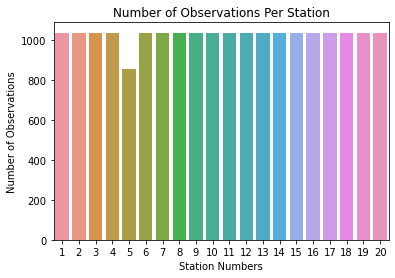

```python
weather_countplot=sns.countplot(data=weather_df, x='station_nbr')
weather_countplot.set_title("Number of Observations Per Station")
weather_countplot.set_ylabel("Number of Observations")
weather_countplot.set_xlabel("Station Numbers")
```

We can see that all stations have the same number of obseravtions, apart from station 5, that has less.

We will replace the empty data cells with NaN value to check how many missing data we have.  
First we will replace blank strings with NaN.

```python
weather_df.replace(r'^\s*$', np.nan, regex=True, inplace=True)
dates_column=weather_df.iloc[:,1]
```

```python
dates_column
```

```
0        2012-01-01
1        2012-01-01
2        2012-01-01
3        2012-01-01
4        2012-01-01
            ...
20512    2014-10-31
20513    2014-10-31
20514    2014-10-31
20515    2014-10-31
20516    2014-10-31
Name: date, Length: 20517, dtype: object
```

We store seperatley dates and depart columns and drop them from the data frame so we could replace '-' with NaN

```python
no_date_df=weather_df.drop("date", axis=1, inplace=False)
depart_column=weather_df.iloc[:,5]
no_date_df.drop("depart", axis=1, inplace=True)
```

```python
no_date_df
```

|  | station_nbr | tmax | tmin | tavg | dewpoint | wetbulb | heat | cool | sunrise | sunset | codesum | snowfall | preciptotal | stnpressure | sealevel | resultspeed | resultdir | avgspeed |
| --- | --- | --- | --- | --- | --- | --- | --- | --- | --- | --- | --- | --- | --- | --- | --- | --- | --- | --- |
| 0 | 1 | 52 | 31 | 42 | 36 | 40 | 23 | 0 | - | - | RA FZFG BR | M | 0.05 | 29.78 | 29.92 | 3.6 | 20 | 4.6 |
| 1 | 2 | 48 | 33 | 41 | 37 | 39 | 24 | 0 | 0716 | 1626 | RA | 0.0 | 0.07 | 28.82 | 29.91 | 9.1 | 23 | 11.3 |
| 2 | 3 | 55 | 34 | 45 | 24 | 36 | 20 | 0 | 0735 | 1720 | NaN | 0.0 | 0.00 | 29.77 | 30.47 | 9.9 | 31 | 10.0 |
| 3 | 4 | 63 | 47 | 55 | 28 | 43 | 10 | 0 | 0728 | 1742 | NaN | 0.0 | 0.00 | 29.79 | 30.48 | 8.0 | 35 | 8.2 |
| 4 | 6 | 63 | 34 | 49 | 31 | 43 | 16 | 0 | 0727 | 1742 | NaN | 0.0 | 0.00 | 29.95 | 30.47 | 14.0 | 36 | 13.8 |
| ... | ... | ... | ... | ... | ... | ... | ... | ... | ... | ... | ... | ... | ... | ... | ... | ... | ... | ... |
| 20512 | 16 | 53 | 34 | 44 | 35 | 41 | 21 | 0 | - | - | NaN | M | 0.00 | 29.90 | 29.99 | 4.5 | 03 | 5.3 |
| 20513 | 17 | 59 | 34 | 47 | 32 | 41 | 18 | 0 | - | - | RA | 0.0 | 0.00 | 29.72 | 30.39 | 9.2 | 01 | 9.3 |
| 20514 | 18 | 67 | 49 | 58 | 40 | 50 | 7 | 0 | 0644 | 1738 | NaN | 0.0 | 0.00 | 29.78 | 30.28 | 10.6 | 36 | 11.2 |
| 20515 | 19 | 45 | 33 | 39 | 24 | 32 | 26 | 0 | 0624 | 1646 | RA SN | 0.1 | 0.02 | 29.51 | 30.24 | 20.4 | 34 | 20.9 |
| 20516 | 20 | 68 | 50 | 59 | 39 | 50 | 6 | 0 | - | - | NaN | 0.0 | 0.00 | 29.57 | 30.27 | 10.5 | 36 | 11.2 |

20517 rows × 18 columns

We store seperatley the codesum column and drop it from the data frame so we could replace 'M' with NaN

```python
codesum_column=weather_df.iloc[:,12]
no_date_df.drop("codesum", axis=1, inplace=True)
no_date_df
```

|  | station_nbr | tmax | tmin | tavg | dewpoint | wetbulb | heat | cool | sunrise | sunset | snowfall | preciptotal | stnpressure | sealevel | resultspeed | resultdir | avgspeed |
| --- | --- | --- | --- | --- | --- | --- | --- | --- | --- | --- | --- | --- | --- | --- | --- | --- | --- |
| 0 | 1 | 52 | 31 | 42 | 36 | 40 | 23 | 0 | - | - | M | 0.05 | 29.78 | 29.92 | 3.6 | 20 | 4.6 |
| 1 | 2 | 48 | 33 | 41 | 37 | 39 | 24 | 0 | 0716 | 1626 | 0.0 | 0.07 | 28.82 | 29.91 | 9.1 | 23 | 11.3 |
| 2 | 3 | 55 | 34 | 45 | 24 | 36 | 20 | 0 | 0735 | 1720 | 0.0 | 0.00 | 29.77 | 30.47 | 9.9 | 31 | 10.0 |
| 3 | 4 | 63 | 47 | 55 | 28 | 43 | 10 | 0 | 0728 | 1742 | 0.0 | 0.00 | 29.79 | 30.48 | 8.0 | 35 | 8.2 |
| 4 | 6 | 63 | 34 | 49 | 31 | 43 | 16 | 0 | 0727 | 1742 | 0.0 | 0.00 | 29.95 | 30.47 | 14.0 | 36 | 13.8 |
| ... | ... | ... | ... | ... | ... | ... | ... | ... | ... | ... | ... | ... | ... | ... | ... | ... | ... |
| 20512 | 16 | 53 | 34 | 44 | 35 | 41 | 21 | 0 | - | - | M | 0.00 | 29.90 | 29.99 | 4.5 | 03 | 5.3 |
| 20513 | 17 | 59 | 34 | 47 | 32 | 41 | 18 | 0 | - | - | 0.0 | 0.00 | 29.72 | 30.39 | 9.2 | 01 | 9.3 |
| 20514 | 18 | 67 | 49 | 58 | 40 | 50 | 7 | 0 | 0644 | 1738 | 0.0 | 0.00 | 29.78 | 30.28 | 10.6 | 36 | 11.2 |
| 20515 | 19 | 45 | 33 | 39 | 24 | 32 | 26 | 0 | 0624 | 1646 | 0.1 | 0.02 | 29.51 | 30.24 | 20.4 | 34 | 20.9 |
| 20516 | 20 | 68 | 50 | 59 | 39 | 50 | 6 | 0 | - | - | 0.0 | 0.00 | 29.57 | 30.27 | 10.5 | 36 | 11.2 |

20517 rows × 17 columns

We repalce 'M' that denotes missing data to NaN

```python
no_date_df.replace(r'M',np.nan, regex=True, inplace=True)
no_date_df
```

|  | station_nbr | tmax | tmin | tavg | dewpoint | wetbulb | heat | cool | sunrise | sunset | snowfall | preciptotal | stnpressure | sealevel | resultspeed | resultdir | avgspeed |
| --- | --- | --- | --- | --- | --- | --- | --- | --- | --- | --- | --- | --- | --- | --- | --- | --- | --- |
| 0 | 1 | 52 | 31 | 42 | 36 | 40 | 23 | 0 | - | - | NaN | 0.05 | 29.78 | 29.92 | 3.6 | 20 | 4.6 |
| 1 | 2 | 48 | 33 | 41 | 37 | 39 | 24 | 0 | 0716 | 1626 | 0.0 | 0.07 | 28.82 | 29.91 | 9.1 | 23 | 11.3 |
| 2 | 3 | 55 | 34 | 45 | 24 | 36 | 20 | 0 | 0735 | 1720 | 0.0 | 0.00 | 29.77 | 30.47 | 9.9 | 31 | 10.0 |
| 3 | 4 | 63 | 47 | 55 | 28 | 43 | 10 | 0 | 0728 | 1742 | 0.0 | 0.00 | 29.79 | 30.48 | 8.0 | 35 | 8.2 |
| 4 | 6 | 63 | 34 | 49 | 31 | 43 | 16 | 0 | 0727 | 1742 | 0.0 | 0.00 | 29.95 | 30.47 | 14.0 | 36 | 13.8 |
| ... | ... | ... | ... | ... | ... | ... | ... | ... | ... | ... | ... | ... | ... | ... | ... | ... | ... |
| 20512 | 16 | 53 | 34 | 44 | 35 | 41 | 21 | 0 | - | - | NaN | 0.00 | 29.90 | 29.99 | 4.5 | 03 | 5.3 |
| 20513 | 17 | 59 | 34 | 47 | 32 | 41 | 18 | 0 | - | - | 0.0 | 0.00 | 29.72 | 30.39 | 9.2 | 01 | 9.3 |
| 20514 | 18 | 67 | 49 | 58 | 40 | 50 | 7 | 0 | 0644 | 1738 | 0.0 | 0.00 | 29.78 | 30.28 | 10.6 | 36 | 11.2 |
| 20515 | 19 | 45 | 33 | 39 | 24 | 32 | 26 | 0 | 0624 | 1646 | 0.1 | 0.02 | 29.51 | 30.24 | 20.4 | 34 | 20.9 |
| 20516 | 20 | 68 | 50 | 59 | 39 | 50 | 6 | 0 | - | - | 0.0 | 0.00 | 29.57 | 30.27 | 10.5 | 36 | 11.2 |

20517 rows × 17 columns

We replace '-' that denots missing data from the data frame with NaN

```python
no_date_df.replace(r'-', np.nan, regex=True, inplace=True)
no_date_df
```

|  | station_nbr | tmax | tmin | tavg | dewpoint | wetbulb | heat | cool | sunrise | sunset | snowfall | preciptotal | stnpressure | sealevel | resultspeed | resultdir | avgspeed |
| --- | --- | --- | --- | --- | --- | --- | --- | --- | --- | --- | --- | --- | --- | --- | --- | --- | --- |
| 0 | 1 | 52 | 31 | 42 | 36 | 40 | 23 | 0 | NaN | NaN | NaN | 0.05 | 29.78 | 29.92 | 3.6 | 20 | 4.6 |
| 1 | 2 | 48 | 33 | 41 | 37 | 39 | 24 | 0 | 0716 | 1626 | 0.0 | 0.07 | 28.82 | 29.91 | 9.1 | 23 | 11.3 |
| 2 | 3 | 55 | 34 | 45 | 24 | 36 | 20 | 0 | 0735 | 1720 | 0.0 | 0.00 | 29.77 | 30.47 | 9.9 | 31 | 10.0 |
| 3 | 4 | 63 | 47 | 55 | 28 | 43 | 10 | 0 | 0728 | 1742 | 0.0 | 0.00 | 29.79 | 30.48 | 8.0 | 35 | 8.2 |
| 4 | 6 | 63 | 34 | 49 | 31 | 43 | 16 | 0 | 0727 | 1742 | 0.0 | 0.00 | 29.95 | 30.47 | 14.0 | 36 | 13.8 |
| ... | ... | ... | ... | ... | ... | ... | ... | ... | ... | ... | ... | ... | ... | ... | ... | ... | ... |
| 20512 | 16 | 53 | 34 | 44 | 35 | 41 | 21 | 0 | NaN | NaN | NaN | 0.00 | 29.90 | 29.99 | 4.5 | 03 | 5.3 |
| 20513 | 17 | 59 | 34 | 47 | 32 | 41 | 18 | 0 | NaN | NaN | 0.0 | 0.00 | 29.72 | 30.39 | 9.2 | 01 | 9.3 |
| 20514 | 18 | 67 | 49 | 58 | 40 | 50 | 7 | 0 | 0644 | 1738 | 0.0 | 0.00 | 29.78 | 30.28 | 10.6 | 36 | 11.2 |
| 20515 | 19 | 45 | 33 | 39 | 24 | 32 | 26 | 0 | 0624 | 1646 | 0.1 | 0.02 | 29.51 | 30.24 | 20.4 | 34 | 20.9 |
| 20516 | 20 | 68 | 50 | 59 | 39 | 50 | 6 | 0 | NaN | NaN | 0.0 | 0.00 | 29.57 | 30.27 | 10.5 | 36 | 11.2 |

20517 rows × 17 columns

We replace the 'M' that denotes missing data in depart column to NaN

```python
depart_column.replace(r'M',np.nan, regex=True, inplace=True)
depart_column
```

```
0        NaN
1         16
2          9
3          4
4          0
        ...
20512    NaN
20513    NaN
20514     -4
20515     -6
20516    NaN
Name: depart, Length: 20517, dtype: object
```

We replace the value 'T' that denotes trace of snow or precipitation with 0.01 since this is the value of 'trace' in Meteorology terminology, to enable using KNN impuation (arbitrary value imputation)

```python
no_date_df.replace(r'T', 0.01, regex=True, inplace=True)
no_date_df
```

|  | station_nbr | tmax | tmin | tavg | dewpoint | wetbulb | heat | cool | sunrise | sunset | snowfall | preciptotal | stnpressure | sealevel | resultspeed | resultdir | avgspeed |
| --- | --- | --- | --- | --- | --- | --- | --- | --- | --- | --- | --- | --- | --- | --- | --- | --- | --- |
| 0 | 1 | 52 | 31 | 42 | 36 | 40 | 23 | 0 | NaN | NaN | NaN | 0.05 | 29.78 | 29.92 | 3.6 | 20 | 4.6 |
| 1 | 2 | 48 | 33 | 41 | 37 | 39 | 24 | 0 | 0716 | 1626 | 0.0 | 0.07 | 28.82 | 29.91 | 9.1 | 23 | 11.3 |
| 2 | 3 | 55 | 34 | 45 | 24 | 36 | 20 | 0 | 0735 | 1720 | 0.0 | 0.00 | 29.77 | 30.47 | 9.9 | 31 | 10.0 |
| 3 | 4 | 63 | 47 | 55 | 28 | 43 | 10 | 0 | 0728 | 1742 | 0.0 | 0.00 | 29.79 | 30.48 | 8.0 | 35 | 8.2 |
| 4 | 6 | 63 | 34 | 49 | 31 | 43 | 16 | 0 | 0727 | 1742 | 0.0 | 0.00 | 29.95 | 30.47 | 14.0 | 36 | 13.8 |
| ... | ... | ... | ... | ... | ... | ... | ... | ... | ... | ... | ... | ... | ... | ... | ... | ... | ... |
| 20512 | 16 | 53 | 34 | 44 | 35 | 41 | 21 | 0 | NaN | NaN | NaN | 0.00 | 29.90 | 29.99 | 4.5 | 03 | 5.3 |
| 20513 | 17 | 59 | 34 | 47 | 32 | 41 | 18 | 0 | NaN | NaN | 0.0 | 0.00 | 29.72 | 30.39 | 9.2 | 01 | 9.3 |
| 20514 | 18 | 67 | 49 | 58 | 40 | 50 | 7 | 0 | 0644 | 1738 | 0.0 | 0.00 | 29.78 | 30.28 | 10.6 | 36 | 11.2 |
| 20515 | 19 | 45 | 33 | 39 | 24 | 32 | 26 | 0 | 0624 | 1646 | 0.1 | 0.02 | 29.51 | 30.24 | 20.4 | 34 | 20.9 |
| 20516 | 20 | 68 | 50 | 59 | 39 | 50 | 6 | 0 | NaN | NaN | 0.0 | 0.00 | 29.57 | 30.27 | 10.5 | 36 | 11.2 |

20517 rows × 17 columns

Now we combine all the data together again to a complete data frame

```python
weather_df=pd.concat([dates_column,no_date_df,depart_column,codesum_column],axis=1)
weather_df
```

|  | date | station_nbr | tmax | tmin | tavg | dewpoint | wetbulb | heat | cool | sunrise | sunset | snowfall | preciptotal | stnpressure | sealevel | resultspeed | resultdir | avgspeed | depart | codesum |
| --- | --- | --- | --- | --- | --- | --- | --- | --- | --- | --- | --- | --- | --- | --- | --- | --- | --- | --- | --- | --- |
| 0 | 2012-01-01 | 1 | 52 | 31 | 42 | 36 | 40 | 23 | 0 | NaN | NaN | NaN | 0.05 | 29.78 | 29.92 | 3.6 | 20 | 4.6 | NaN | RA FZFG BR |
| 1 | 2012-01-01 | 2 | 48 | 33 | 41 | 37 | 39 | 24 | 0 | 0716 | 1626 | 0.0 | 0.07 | 28.82 | 29.91 | 9.1 | 23 | 11.3 | 16 | RA |
| 2 | 2012-01-01 | 3 | 55 | 34 | 45 | 24 | 36 | 20 | 0 | 0735 | 1720 | 0.0 | 0.00 | 29.77 | 30.47 | 9.9 | 31 | 10.0 | 9 | NaN |
| 3 | 2012-01-01 | 4 | 63 | 47 | 55 | 28 | 43 | 10 | 0 | 0728 | 1742 | 0.0 | 0.00 | 29.79 | 30.48 | 8.0 | 35 | 8.2 | 4 | NaN |
| 4 | 2012-01-01 | 6 | 63 | 34 | 49 | 31 | 43 | 16 | 0 | 0727 | 1742 | 0.0 | 0.00 | 29.95 | 30.47 | 14.0 | 36 | 13.8 | 0 | NaN |
| ... | ... | ... | ... | ... | ... | ... | ... | ... | ... | ... | ... | ... | ... | ... | ... | ... | ... | ... | ... | ... |
| 20512 | 2014-10-31 | 16 | 53 | 34 | 44 | 35 | 41 | 21 | 0 | NaN | NaN | NaN | 0.00 | 29.90 | 29.99 | 4.5 | 03 | 5.3 | NaN | NaN |
| 20513 | 2014-10-31 | 17 | 59 | 34 | 47 | 32 | 41 | 18 | 0 | NaN | NaN | 0.0 | 0.00 | 29.72 | 30.39 | 9.2 | 01 | 9.3 | NaN | RA |
| 20514 | 2014-10-31 | 18 | 67 | 49 | 58 | 40 | 50 | 7 | 0 | 0644 | 1738 | 0.0 | 0.00 | 29.78 | 30.28 | 10.6 | 36 | 11.2 | -4 | NaN |
| 20515 | 2014-10-31 | 19 | 45 | 33 | 39 | 24 | 32 | 26 | 0 | 0624 | 1646 | 0.1 | 0.02 | 29.51 | 30.24 | 20.4 | 34 | 20.9 | -6 | RA SN |
| 20516 | 2014-10-31 | 20 | 68 | 50 | 59 | 39 | 50 | 6 | 0 | NaN | NaN | 0.0 | 0.00 | 29.57 | 30.27 | 10.5 | 36 | 11.2 | NaN | NaN |

20517 rows × 20 columns

We check how many NaNs we have in the data frame

```python
weather_df.isnull().sum()
```

```
date               0
station_nbr        0
tmax             912
tmin            1055
tavg            1499
dewpoint         886
wetbulb         1279
heat            1469
cool            1469
sunrise         9656
sunset          9656
snowfall        7224
preciptotal      860
stnpressure      929
sealevel        1724
resultspeed      589
resultdir        589
avgspeed         875
depart         11511
codesum        11051
dtype: int64
```

We visualize the NaNs count

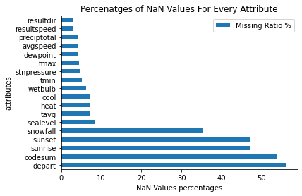

```python
na_df = (weather_df.isnull().sum() / len(weather_df)) * 100
na_df = na_df.drop(na_df[na_df == 0].index).sort_values(ascending=False)
missing_data = pd.DataFrame({'Missing Ratio %' :na_df})
missing_data.plot(kind = "barh")
plt.xlabel("NaN Values percentages")
plt.ylabel("attributes")
plt.title("Percenatges of NaN Values For Every Attribute")
plt.show()
```

We can see that there is missing data, we will need to use preprocessing tools to complete it. The codesum column consists a lot of missing values because it denotes whether there was a special weather that day, every case has it's code, if there was not anything special, then we get a NaN value.

## Section B

We convert all of the numeric features that are stored as object type to numeric type  
to enable simpler processing and understaning of the data

```python
weather_df['sunrise'] = pd.to_numeric(weather_df['sunrise'])
weather_df['sunset'] = pd.to_numeric(weather_df['sunset'])
weather_df['tmax'] = pd.to_numeric(weather_df['tmax'])
weather_df['tmin'] = pd.to_numeric(weather_df['tmin'])
weather_df['tavg'] = pd.to_numeric(weather_df['tavg'])
weather_df['depart'] = pd.to_numeric(weather_df['depart'])
weather_df['wetbulb'] = pd.to_numeric(weather_df['wetbulb'])
weather_df['dewpoint'] = pd.to_numeric(weather_df['dewpoint'])
weather_df['heat'] = pd.to_numeric(weather_df['heat'])
weather_df['cool'] = pd.to_numeric(weather_df['cool'])
weather_df['stnpressure'] = pd.to_numeric(weather_df['stnpressure'])
weather_df['sealevel'] = pd.to_numeric(weather_df['sealevel'])
weather_df['resultdir'] = pd.to_numeric(weather_df['resultdir'])
weather_df['avgspeed'] = pd.to_numeric(weather_df['avgspeed'])
weather_df['resultspeed'] = pd.to_numeric(weather_df['resultspeed'])
weather_df['resultdir'] = pd.to_numeric(weather_df['resultdir'])
weather_df['snowfall'] = pd.to_numeric(weather_df['snowfall'])
weather_df['preciptotal'] = pd.to_numeric(weather_df['preciptotal'])

weather_df.dtypes
```

```
date            object
station_nbr      int64
tmax           float64
tmin           float64
tavg           float64
dewpoint       float64
wetbulb        float64
heat           float64
cool           float64
sunrise        float64
sunset         float64
snowfall       float64
preciptotal    float64
stnpressure    float64
sealevel       float64
resultspeed    float64
resultdir      float64
avgspeed       float64
depart         float64
codesum         object
dtype: object
```

```python
numeric_features = weather_df.select_dtypes(include='number')
numeric_features
```

|  | station_nbr | tmax | tmin | tavg | dewpoint | wetbulb | heat | cool | sunrise | sunset | snowfall | preciptotal | stnpressure | sealevel | resultspeed | resultdir | avgspeed | depart |
| --- | --- | --- | --- | --- | --- | --- | --- | --- | --- | --- | --- | --- | --- | --- | --- | --- | --- | --- |
| 0 | 1 | 52.0 | 31.0 | 42.0 | 36.0 | 40.0 | 23.0 | 0.0 | NaN | NaN | NaN | 0.05 | 29.78 | 29.92 | 3.6 | 20.0 | 4.6 | NaN |
| 1 | 2 | 48.0 | 33.0 | 41.0 | 37.0 | 39.0 | 24.0 | 0.0 | 716.0 | 1626.0 | 0.0 | 0.07 | 28.82 | 29.91 | 9.1 | 23.0 | 11.3 | 16.0 |
| 2 | 3 | 55.0 | 34.0 | 45.0 | 24.0 | 36.0 | 20.0 | 0.0 | 735.0 | 1720.0 | 0.0 | 0.00 | 29.77 | 30.47 | 9.9 | 31.0 | 10.0 | 9.0 |
| 3 | 4 | 63.0 | 47.0 | 55.0 | 28.0 | 43.0 | 10.0 | 0.0 | 728.0 | 1742.0 | 0.0 | 0.00 | 29.79 | 30.48 | 8.0 | 35.0 | 8.2 | 4.0 |
| 4 | 6 | 63.0 | 34.0 | 49.0 | 31.0 | 43.0 | 16.0 | 0.0 | 727.0 | 1742.0 | 0.0 | 0.00 | 29.95 | 30.47 | 14.0 | 36.0 | 13.8 | 0.0 |
| ... | ... | ... | ... | ... | ... | ... | ... | ... | ... | ... | ... | ... | ... | ... | ... | ... | ... | ... |
| 20512 | 16 | 53.0 | 34.0 | 44.0 | 35.0 | 41.0 | 21.0 | 0.0 | NaN | NaN | NaN | 0.00 | 29.90 | 29.99 | 4.5 | 3.0 | 5.3 | NaN |
| 20513 | 17 | 59.0 | 34.0 | 47.0 | 32.0 | 41.0 | 18.0 | 0.0 | NaN | NaN | 0.0 | 0.00 | 29.72 | 30.39 | 9.2 | 1.0 | 9.3 | NaN |
| 20514 | 18 | 67.0 | 49.0 | 58.0 | 40.0 | 50.0 | 7.0 | 0.0 | 644.0 | 1738.0 | 0.0 | 0.00 | 29.78 | 30.28 | 10.6 | 36.0 | 11.2 | -4.0 |
| 20515 | 19 | 45.0 | 33.0 | 39.0 | 24.0 | 32.0 | 26.0 | 0.0 | 624.0 | 1646.0 | 0.1 | 0.02 | 29.51 | 30.24 | 20.4 | 34.0 | 20.9 | -6.0 |
| 20516 | 20 | 68.0 | 50.0 | 59.0 | 39.0 | 50.0 | 6.0 | 0.0 | NaN | NaN | 0.0 | 0.00 | 29.57 | 30.27 | 10.5 | 36.0 | 11.2 | NaN |

20517 rows × 18 columns

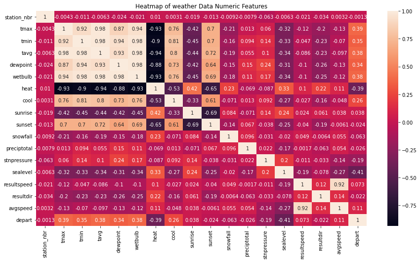

```python
plt.figure(figsize=(15,8) )
weather_heatmap=sns.heatmap(numeric_features.corr(),annot=True)
weather_heatmap.set_title("Heatmap of weather Data Numeric Features")
```

as we can see there is high correlation between tmax,tmin and tavg.  
because they all give us similliar information about the temperature  
for that reason we decided to exclude tmax and tmin.  
In addtion we can see high correlation between tavg and heat, wetbulb and tavg, dewpoint and tavg, heat and tavg.  
Therefore we can exclude wetbulb,dewpoint and heat.

```python
weather_df.drop(['tmax', 'tmin','dewpoint','wetbulb','heat'], axis=1, inplace=True)
weather_df
```

|  | date | station_nbr | tavg | cool | sunrise | sunset | snowfall | preciptotal | stnpressure | sealevel | resultspeed | resultdir | avgspeed | depart | codesum |
| --- | --- | --- | --- | --- | --- | --- | --- | --- | --- | --- | --- | --- | --- | --- | --- |
| 0 | 2012-01-01 | 1 | 42.0 | 0.0 | NaN | NaN | NaN | 0.05 | 29.78 | 29.92 | 3.6 | 20.0 | 4.6 | NaN | RA FZFG BR |
| 1 | 2012-01-01 | 2 | 41.0 | 0.0 | 716.0 | 1626.0 | 0.0 | 0.07 | 28.82 | 29.91 | 9.1 | 23.0 | 11.3 | 16.0 | RA |
| 2 | 2012-01-01 | 3 | 45.0 | 0.0 | 735.0 | 1720.0 | 0.0 | 0.00 | 29.77 | 30.47 | 9.9 | 31.0 | 10.0 | 9.0 | NaN |
| 3 | 2012-01-01 | 4 | 55.0 | 0.0 | 728.0 | 1742.0 | 0.0 | 0.00 | 29.79 | 30.48 | 8.0 | 35.0 | 8.2 | 4.0 | NaN |
| 4 | 2012-01-01 | 6 | 49.0 | 0.0 | 727.0 | 1742.0 | 0.0 | 0.00 | 29.95 | 30.47 | 14.0 | 36.0 | 13.8 | 0.0 | NaN |
| ... | ... | ... | ... | ... | ... | ... | ... | ... | ... | ... | ... | ... | ... | ... | ... |
| 20512 | 2014-10-31 | 16 | 44.0 | 0.0 | NaN | NaN | NaN | 0.00 | 29.90 | 29.99 | 4.5 | 3.0 | 5.3 | NaN | NaN |
| 20513 | 2014-10-31 | 17 | 47.0 | 0.0 | NaN | NaN | 0.0 | 0.00 | 29.72 | 30.39 | 9.2 | 1.0 | 9.3 | NaN | RA |
| 20514 | 2014-10-31 | 18 | 58.0 | 0.0 | 644.0 | 1738.0 | 0.0 | 0.00 | 29.78 | 30.28 | 10.6 | 36.0 | 11.2 | -4.0 | NaN |
| 20515 | 2014-10-31 | 19 | 39.0 | 0.0 | 624.0 | 1646.0 | 0.1 | 0.02 | 29.51 | 30.24 | 20.4 | 34.0 | 20.9 | -6.0 | RA SN |
| 20516 | 2014-10-31 | 20 | 59.0 | 0.0 | NaN | NaN | 0.0 | 0.00 | 29.57 | 30.27 | 10.5 | 36.0 | 11.2 | NaN | NaN |

20517 rows × 15 columns

Now let's look on our updated heatmap

```python
numeric_features = weather_df.select_dtypes(include='number')
numeric_features
```

|  | station_nbr | tavg | cool | sunrise | sunset | snowfall | preciptotal | stnpressure | sealevel | resultspeed | resultdir | avgspeed | depart |
| --- | --- | --- | --- | --- | --- | --- | --- | --- | --- | --- | --- | --- | --- |
| 0 | 1 | 42.0 | 0.0 | NaN | NaN | NaN | 0.05 | 29.78 | 29.92 | 3.6 | 20.0 | 4.6 | NaN |
| 1 | 2 | 41.0 | 0.0 | 716.0 | 1626.0 | 0.0 | 0.07 | 28.82 | 29.91 | 9.1 | 23.0 | 11.3 | 16.0 |
| 2 | 3 | 45.0 | 0.0 | 735.0 | 1720.0 | 0.0 | 0.00 | 29.77 | 30.47 | 9.9 | 31.0 | 10.0 | 9.0 |
| 3 | 4 | 55.0 | 0.0 | 728.0 | 1742.0 | 0.0 | 0.00 | 29.79 | 30.48 | 8.0 | 35.0 | 8.2 | 4.0 |
| 4 | 6 | 49.0 | 0.0 | 727.0 | 1742.0 | 0.0 | 0.00 | 29.95 | 30.47 | 14.0 | 36.0 | 13.8 | 0.0 |
| ... | ... | ... | ... | ... | ... | ... | ... | ... | ... | ... | ... | ... | ... |
| 20512 | 16 | 44.0 | 0.0 | NaN | NaN | NaN | 0.00 | 29.90 | 29.99 | 4.5 | 3.0 | 5.3 | NaN |
| 20513 | 17 | 47.0 | 0.0 | NaN | NaN | 0.0 | 0.00 | 29.72 | 30.39 | 9.2 | 1.0 | 9.3 | NaN |
| 20514 | 18 | 58.0 | 0.0 | 644.0 | 1738.0 | 0.0 | 0.00 | 29.78 | 30.28 | 10.6 | 36.0 | 11.2 | -4.0 |
| 20515 | 19 | 39.0 | 0.0 | 624.0 | 1646.0 | 0.1 | 0.02 | 29.51 | 30.24 | 20.4 | 34.0 | 20.9 | -6.0 |
| 20516 | 20 | 59.0 | 0.0 | NaN | NaN | 0.0 | 0.00 | 29.57 | 30.27 | 10.5 | 36.0 | 11.2 | NaN |

20517 rows × 13 columns

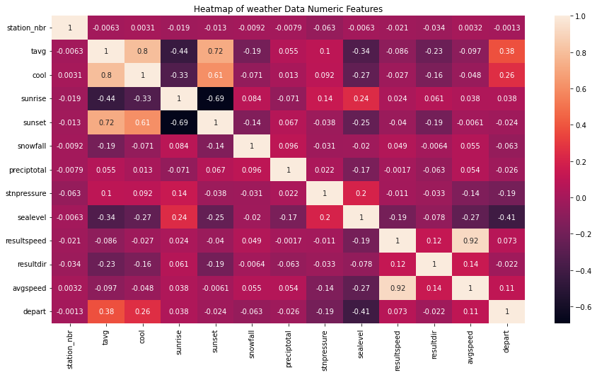

```python
plt.figure(figsize=(15,8) )
weather_heatmap=sns.heatmap(numeric_features.corr(),annot=True)
weather_heatmap.set_title("Heatmap of weather Data Numeric Features")
```

Instead of having NaNs in codesum column where the value is 'moderate', we will change the NaN value to the value 'MO' (arbitrary value imputation)

```python
weather_df['codesum'] =weather_df['codesum'].fillna('MO')
weather_df
```

|  | date | station_nbr | tavg | cool | sunrise | sunset | snowfall | preciptotal | stnpressure | sealevel | resultspeed | resultdir | avgspeed | depart | codesum |
| --- | --- | --- | --- | --- | --- | --- | --- | --- | --- | --- | --- | --- | --- | --- | --- |
| 0 | 2012-01-01 | 1 | 42.0 | 0.0 | NaN | NaN | NaN | 0.05 | 29.78 | 29.92 | 3.6 | 20.0 | 4.6 | NaN | RA FZFG BR |
| 1 | 2012-01-01 | 2 | 41.0 | 0.0 | 716.0 | 1626.0 | 0.0 | 0.07 | 28.82 | 29.91 | 9.1 | 23.0 | 11.3 | 16.0 | RA |
| 2 | 2012-01-01 | 3 | 45.0 | 0.0 | 735.0 | 1720.0 | 0.0 | 0.00 | 29.77 | 30.47 | 9.9 | 31.0 | 10.0 | 9.0 | MO |
| 3 | 2012-01-01 | 4 | 55.0 | 0.0 | 728.0 | 1742.0 | 0.0 | 0.00 | 29.79 | 30.48 | 8.0 | 35.0 | 8.2 | 4.0 | MO |
| 4 | 2012-01-01 | 6 | 49.0 | 0.0 | 727.0 | 1742.0 | 0.0 | 0.00 | 29.95 | 30.47 | 14.0 | 36.0 | 13.8 | 0.0 | MO |
| ... | ... | ... | ... | ... | ... | ... | ... | ... | ... | ... | ... | ... | ... | ... | ... |
| 20512 | 2014-10-31 | 16 | 44.0 | 0.0 | NaN | NaN | NaN | 0.00 | 29.90 | 29.99 | 4.5 | 3.0 | 5.3 | NaN | MO |
| 20513 | 2014-10-31 | 17 | 47.0 | 0.0 | NaN | NaN | 0.0 | 0.00 | 29.72 | 30.39 | 9.2 | 1.0 | 9.3 | NaN | RA |
| 20514 | 2014-10-31 | 18 | 58.0 | 0.0 | 644.0 | 1738.0 | 0.0 | 0.00 | 29.78 | 30.28 | 10.6 | 36.0 | 11.2 | -4.0 | MO |
| 20515 | 2014-10-31 | 19 | 39.0 | 0.0 | 624.0 | 1646.0 | 0.1 | 0.02 | 29.51 | 30.24 | 20.4 | 34.0 | 20.9 | -6.0 | RA SN |
| 20516 | 2014-10-31 | 20 | 59.0 | 0.0 | NaN | NaN | 0.0 | 0.00 | 29.57 | 30.27 | 10.5 | 36.0 | 11.2 | NaN | MO |

20517 rows × 15 columns

We use one hot encoding to change codesum- a categorial feature to binary feature

```python
weather_df['codesum'] = weather_df['codesum'].astype('category')
weather_df.dtypes
```

```
date             object
station_nbr       int64
tavg            float64
cool            float64
sunrise         float64
sunset          float64
snowfall        float64
preciptotal     float64
stnpressure     float64
sealevel        float64
resultspeed     float64
resultdir       float64
avgspeed        float64
depart          float64
codesum        category
dtype: object
```

codesum is a categorial feature so we use one-hot encoding transformation on codesum feature to enable KNN imputation for other features, to replace missing data of obesrvations

```python
encoded = pd.get_dummies(weather_df['codesum'], drop_first=True)
weather_df.drop('codesum', axis=1, inplace=True)
weather_df = pd.concat([weather_df, encoded], axis=1)
weather_df
```

|  | date | station_nbr | tavg | cool | sunrise | sunset | snowfall | preciptotal | stnpressure | sealevel | ... | TSSN FG+ BR VCTS | TSSN RA DZ SN BR VCTS | TSSN RA SN FG+ FZFG BR | TSSN SN BR UP | TSSN UP VCTS | UP | UP BLSN | UP HZ | VCFG | VCTS |
| --- | --- | --- | --- | --- | --- | --- | --- | --- | --- | --- | --- | --- | --- | --- | --- | --- | --- | --- | --- | --- | --- |
| 0 | 2012-01-01 | 1 | 42.0 | 0.0 | NaN | NaN | NaN | 0.05 | 29.78 | 29.92 | ... | 0 | 0 | 0 | 0 | 0 | 0 | 0 | 0 | 0 | 0 |
| 1 | 2012-01-01 | 2 | 41.0 | 0.0 | 716.0 | 1626.0 | 0.0 | 0.07 | 28.82 | 29.91 | ... | 0 | 0 | 0 | 0 | 0 | 0 | 0 | 0 | 0 | 0 |
| 2 | 2012-01-01 | 3 | 45.0 | 0.0 | 735.0 | 1720.0 | 0.0 | 0.00 | 29.77 | 30.47 | ... | 0 | 0 | 0 | 0 | 0 | 0 | 0 | 0 | 0 | 0 |
| 3 | 2012-01-01 | 4 | 55.0 | 0.0 | 728.0 | 1742.0 | 0.0 | 0.00 | 29.79 | 30.48 | ... | 0 | 0 | 0 | 0 | 0 | 0 | 0 | 0 | 0 | 0 |
| 4 | 2012-01-01 | 6 | 49.0 | 0.0 | 727.0 | 1742.0 | 0.0 | 0.00 | 29.95 | 30.47 | ... | 0 | 0 | 0 | 0 | 0 | 0 | 0 | 0 | 0 | 0 |
| ... | ... | ... | ... | ... | ... | ... | ... | ... | ... | ... | ... | ... | ... | ... | ... | ... | ... | ... | ... | ... | ... |
| 20512 | 2014-10-31 | 16 | 44.0 | 0.0 | NaN | NaN | NaN | 0.00 | 29.90 | 29.99 | ... | 0 | 0 | 0 | 0 | 0 | 0 | 0 | 0 | 0 | 0 |
| 20513 | 2014-10-31 | 17 | 47.0 | 0.0 | NaN | NaN | 0.0 | 0.00 | 29.72 | 30.39 | ... | 0 | 0 | 0 | 0 | 0 | 0 | 0 | 0 | 0 | 0 |
| 20514 | 2014-10-31 | 18 | 58.0 | 0.0 | 644.0 | 1738.0 | 0.0 | 0.00 | 29.78 | 30.28 | ... | 0 | 0 | 0 | 0 | 0 | 0 | 0 | 0 | 0 | 0 |
| 20515 | 2014-10-31 | 19 | 39.0 | 0.0 | 624.0 | 1646.0 | 0.1 | 0.02 | 29.51 | 30.24 | ... | 0 | 0 | 0 | 0 | 0 | 0 | 0 | 0 | 0 | 0 |
| 20516 | 2014-10-31 | 20 | 59.0 | 0.0 | NaN | NaN | 0.0 | 0.00 | 29.57 | 30.27 | ... | 0 | 0 | 0 | 0 | 0 | 0 | 0 | 0 | 0 | 0 |

20517 rows × 462 columns

```python
weather_df.shape
```

```
(20517, 462)
```

Now the weather data frame contains 462 columns because of the one hot encoding transformation

Lets check how many NaNs we have in the depart column

```python
weather_df['depart'].value_counts(dropna=False)
```

```
 NaN     11511
 3.0       564
 4.0       531
 1.0       522
 2.0       515
         ...
 30.0        1
-28.0        1
 33.0        1
 32.0        1
-35.0        1
Name: depart, Length: 66, dtype: int64
```

We convert the date column to 3 numeric columns:  
year, month, day.  
afterwards we will drop the old date column  
This way we convert date column from data type datetime to numeric to enable using machine learning algorithms afterwards

```python
weather_df['year'] = pd.to_datetime(weather_df['date']).dt.year
weather_df['month']=pd.to_datetime(weather_df['date']).dt.month
weather_df['day']=pd.to_datetime(weather_df['date']).dt.day
weather_df.drop('date', axis=1, inplace=True)
weather_df
```

|  | station_nbr | tavg | cool | sunrise | sunset | snowfall | preciptotal | stnpressure | sealevel | resultspeed | ... | TSSN SN BR UP | TSSN UP VCTS | UP | UP BLSN | UP HZ | VCFG | VCTS | year | month | day |
| --- | --- | --- | --- | --- | --- | --- | --- | --- | --- | --- | --- | --- | --- | --- | --- | --- | --- | --- | --- | --- | --- |
| 0 | 1 | 42.0 | 0.0 | NaN | NaN | NaN | 0.05 | 29.78 | 29.92 | 3.6 | ... | 0 | 0 | 0 | 0 | 0 | 0 | 0 | 2012 | 1 | 1 |
| 1 | 2 | 41.0 | 0.0 | 716.0 | 1626.0 | 0.0 | 0.07 | 28.82 | 29.91 | 9.1 | ... | 0 | 0 | 0 | 0 | 0 | 0 | 0 | 2012 | 1 | 1 |
| 2 | 3 | 45.0 | 0.0 | 735.0 | 1720.0 | 0.0 | 0.00 | 29.77 | 30.47 | 9.9 | ... | 0 | 0 | 0 | 0 | 0 | 0 | 0 | 2012 | 1 | 1 |
| 3 | 4 | 55.0 | 0.0 | 728.0 | 1742.0 | 0.0 | 0.00 | 29.79 | 30.48 | 8.0 | ... | 0 | 0 | 0 | 0 | 0 | 0 | 0 | 2012 | 1 | 1 |
| 4 | 6 | 49.0 | 0.0 | 727.0 | 1742.0 | 0.0 | 0.00 | 29.95 | 30.47 | 14.0 | ... | 0 | 0 | 0 | 0 | 0 | 0 | 0 | 2012 | 1 | 1 |
| ... | ... | ... | ... | ... | ... | ... | ... | ... | ... | ... | ... | ... | ... | ... | ... | ... | ... | ... | ... | ... | ... |
| 20512 | 16 | 44.0 | 0.0 | NaN | NaN | NaN | 0.00 | 29.90 | 29.99 | 4.5 | ... | 0 | 0 | 0 | 0 | 0 | 0 | 0 | 2014 | 10 | 31 |
| 20513 | 17 | 47.0 | 0.0 | NaN | NaN | 0.0 | 0.00 | 29.72 | 30.39 | 9.2 | ... | 0 | 0 | 0 | 0 | 0 | 0 | 0 | 2014 | 10 | 31 |
| 20514 | 18 | 58.0 | 0.0 | 644.0 | 1738.0 | 0.0 | 0.00 | 29.78 | 30.28 | 10.6 | ... | 0 | 0 | 0 | 0 | 0 | 0 | 0 | 2014 | 10 | 31 |
| 20515 | 19 | 39.0 | 0.0 | 624.0 | 1646.0 | 0.1 | 0.02 | 29.51 | 30.24 | 20.4 | ... | 0 | 0 | 0 | 0 | 0 | 0 | 0 | 2014 | 10 | 31 |
| 20516 | 20 | 59.0 | 0.0 | NaN | NaN | 0.0 | 0.00 | 29.57 | 30.27 | 10.5 | ... | 0 | 0 | 0 | 0 | 0 | 0 | 0 | 2014 | 10 | 31 |

20517 rows × 464 columns

```python
weather_df.dtypes
```

```
station_nbr      int64
tavg           float64
cool           float64
sunrise        float64
sunset         float64
                ...
VCFG             uint8
VCTS             uint8
year             int64
month            int64
day              int64
Length: 464, dtype: object
```

```python
from sklearn.impute import KNNImputer
imputer = KNNImputer(n_neighbors=5, weights="distance")
imputed = imputer.fit_transform(weather_df)

imputed=imputer.fit_transform(weather_df)
```

```python
imputed
```

```
array([[1.000e+00, 4.200e+01, 0.000e+00, ..., 2.012e+03, 1.000e+00,
        1.000e+00],
       [2.000e+00, 4.100e+01, 0.000e+00, ..., 2.012e+03, 1.000e+00,
        1.000e+00],
       [3.000e+00, 4.500e+01, 0.000e+00, ..., 2.012e+03, 1.000e+00,
        1.000e+00],
       ...,
       [1.800e+01, 5.800e+01, 0.000e+00, ..., 2.014e+03, 1.000e+01,
        3.100e+01],
       [1.900e+01, 3.900e+01, 0.000e+00, ..., 2.014e+03, 1.000e+01,
        3.100e+01],
       [2.000e+01, 5.900e+01, 0.000e+00, ..., 2.014e+03, 1.000e+01,
        3.100e+01]])
```

We will overwrite the old data frame with the new array with the complementry values for NaN values that we recieved from KNN imputation

```python
weather_df[weather_df.columns]=imputed
weather_df
```

|  | station_nbr | tavg | cool | sunrise | sunset | snowfall | preciptotal | stnpressure | sealevel | resultspeed | ... | TSSN SN BR UP | TSSN UP VCTS | UP | UP BLSN | UP HZ | VCFG | VCTS | year | month | day |
| --- | --- | --- | --- | --- | --- | --- | --- | --- | --- | --- | --- | --- | --- | --- | --- | --- | --- | --- | --- | --- | --- |
| 0 | 1.0 | 42.0 | 0.0 | 673.203060 | 1658.590332 | 0.0 | 0.05 | 29.78 | 29.92 | 3.6 | ... | 0.0 | 0.0 | 0.0 | 0.0 | 0.0 | 0.0 | 0.0 | 2012.0 | 1.0 | 1.0 |
| 1 | 2.0 | 41.0 | 0.0 | 716.000000 | 1626.000000 | 0.0 | 0.07 | 28.82 | 29.91 | 9.1 | ... | 0.0 | 0.0 | 0.0 | 0.0 | 0.0 | 0.0 | 0.0 | 2012.0 | 1.0 | 1.0 |
| 2 | 3.0 | 45.0 | 0.0 | 735.000000 | 1720.000000 | 0.0 | 0.00 | 29.77 | 30.47 | 9.9 | ... | 0.0 | 0.0 | 0.0 | 0.0 | 0.0 | 0.0 | 0.0 | 2012.0 | 1.0 | 1.0 |
| 3 | 4.0 | 55.0 | 0.0 | 728.000000 | 1742.000000 | 0.0 | 0.00 | 29.79 | 30.48 | 8.0 | ... | 0.0 | 0.0 | 0.0 | 0.0 | 0.0 | 0.0 | 0.0 | 2012.0 | 1.0 | 1.0 |
| 4 | 6.0 | 49.0 | 0.0 | 727.000000 | 1742.000000 | 0.0 | 0.00 | 29.95 | 30.47 | 14.0 | ... | 0.0 | 0.0 | 0.0 | 0.0 | 0.0 | 0.0 | 0.0 | 2012.0 | 1.0 | 1.0 |
| ... | ... | ... | ... | ... | ... | ... | ... | ... | ... | ... | ... | ... | ... | ... | ... | ... | ... | ... | ... | ... | ... |
| 20512 | 16.0 | 44.0 | 0.0 | 659.274077 | 1685.177153 | 0.0 | 0.00 | 29.90 | 29.99 | 4.5 | ... | 0.0 | 0.0 | 0.0 | 0.0 | 0.0 | 0.0 | 0.0 | 2014.0 | 10.0 | 31.0 |
| 20513 | 17.0 | 47.0 | 0.0 | 640.808551 | 1734.105631 | 0.0 | 0.00 | 29.72 | 30.39 | 9.2 | ... | 0.0 | 0.0 | 0.0 | 0.0 | 0.0 | 0.0 | 0.0 | 2014.0 | 10.0 | 31.0 |
| 20514 | 18.0 | 58.0 | 0.0 | 644.000000 | 1738.000000 | 0.0 | 0.00 | 29.78 | 30.28 | 10.6 | ... | 0.0 | 0.0 | 0.0 | 0.0 | 0.0 | 0.0 | 0.0 | 2014.0 | 10.0 | 31.0 |
| 20515 | 19.0 | 39.0 | 0.0 | 624.000000 | 1646.000000 | 0.1 | 0.02 | 29.51 | 30.24 | 20.4 | ... | 0.0 | 0.0 | 0.0 | 0.0 | 0.0 | 0.0 | 0.0 | 2014.0 | 10.0 | 31.0 |
| 20516 | 20.0 | 59.0 | 0.0 | 650.922962 | 1724.305255 | 0.0 | 0.00 | 29.57 | 30.27 | 10.5 | ... | 0.0 | 0.0 | 0.0 | 0.0 | 0.0 | 0.0 | 0.0 | 2014.0 | 10.0 | 31.0 |

20517 rows × 464 columns

Create a csv file of the imputed data frame to enable reading it afterwards

```python
weather_df.to_csv(r'C:\Users\taldu\OneDrive\Desktop\לימודים\מערכות מידע\למידת מכונה\HW2\weather_df_imputed.csv')
```

Read the csv file to skip the section B process and get the imputed data frame

```python
weather_df=pd.read_csv('weather_df_imputed.csv', index_col=[0] )
weather_df
```

|  | station_nbr | tavg | cool | sunrise | sunset | snowfall | preciptotal | stnpressure | sealevel | resultspeed | ... | TSSN SN BR UP | TSSN UP VCTS | UP | UP BLSN | UP HZ | VCFG | VCTS | year | month | day |
| --- | --- | --- | --- | --- | --- | --- | --- | --- | --- | --- | --- | --- | --- | --- | --- | --- | --- | --- | --- | --- | --- |
| 0 | 1.0 | 42.0 | 0.0 | 673.203060 | 1658.590332 | 0.0 | 0.05 | 29.78 | 29.92 | 3.6 | ... | 0.0 | 0.0 | 0.0 | 0.0 | 0.0 | 0.0 | 0.0 | 2012.0 | 1.0 | 1.0 |
| 1 | 2.0 | 41.0 | 0.0 | 716.000000 | 1626.000000 | 0.0 | 0.07 | 28.82 | 29.91 | 9.1 | ... | 0.0 | 0.0 | 0.0 | 0.0 | 0.0 | 0.0 | 0.0 | 2012.0 | 1.0 | 1.0 |
| 2 | 3.0 | 45.0 | 0.0 | 735.000000 | 1720.000000 | 0.0 | 0.00 | 29.77 | 30.47 | 9.9 | ... | 0.0 | 0.0 | 0.0 | 0.0 | 0.0 | 0.0 | 0.0 | 2012.0 | 1.0 | 1.0 |
| 3 | 4.0 | 55.0 | 0.0 | 728.000000 | 1742.000000 | 0.0 | 0.00 | 29.79 | 30.48 | 8.0 | ... | 0.0 | 0.0 | 0.0 | 0.0 | 0.0 | 0.0 | 0.0 | 2012.0 | 1.0 | 1.0 |
| 4 | 6.0 | 49.0 | 0.0 | 727.000000 | 1742.000000 | 0.0 | 0.00 | 29.95 | 30.47 | 14.0 | ... | 0.0 | 0.0 | 0.0 | 0.0 | 0.0 | 0.0 | 0.0 | 2012.0 | 1.0 | 1.0 |
| ... | ... | ... | ... | ... | ... | ... | ... | ... | ... | ... | ... | ... | ... | ... | ... | ... | ... | ... | ... | ... | ... |
| 20512 | 16.0 | 44.0 | 0.0 | 659.274077 | 1685.177153 | 0.0 | 0.00 | 29.90 | 29.99 | 4.5 | ... | 0.0 | 0.0 | 0.0 | 0.0 | 0.0 | 0.0 | 0.0 | 2014.0 | 10.0 | 31.0 |
| 20513 | 17.0 | 47.0 | 0.0 | 640.808551 | 1734.105631 | 0.0 | 0.00 | 29.72 | 30.39 | 9.2 | ... | 0.0 | 0.0 | 0.0 | 0.0 | 0.0 | 0.0 | 0.0 | 2014.0 | 10.0 | 31.0 |
| 20514 | 18.0 | 58.0 | 0.0 | 644.000000 | 1738.000000 | 0.0 | 0.00 | 29.78 | 30.28 | 10.6 | ... | 0.0 | 0.0 | 0.0 | 0.0 | 0.0 | 0.0 | 0.0 | 2014.0 | 10.0 | 31.0 |
| 20515 | 19.0 | 39.0 | 0.0 | 624.000000 | 1646.000000 | 0.1 | 0.02 | 29.51 | 30.24 | 20.4 | ... | 0.0 | 0.0 | 0.0 | 0.0 | 0.0 | 0.0 | 0.0 | 2014.0 | 10.0 | 31.0 |
| 20516 | 20.0 | 59.0 | 0.0 | 650.922962 | 1724.305255 | 0.0 | 0.00 | 29.57 | 30.27 | 10.5 | ... | 0.0 | 0.0 | 0.0 | 0.0 | 0.0 | 0.0 | 0.0 | 2014.0 | 10.0 | 31.0 |

20517 rows × 464 columns

Now let's look if we replaced all the NaNs

```python
weather_df.isnull().sum()
```

```
station_nbr    0
tavg           0
cool           0
sunrise        0
sunset         0
              ..
VCFG           0
VCTS           0
year           0
month          0
day            0
Length: 464, dtype: int64
```

Now the dataframe is complete, there are no NaNs and we can use it with machine learning models

## Section C

Use item_nbr column values as new features , so for every date and store_nbr we will get for every item_nbr how many units were sold at that date for every store

```python
pivoted_sales=sales_df.pivot( index=['date','store_nbr'], columns='item_nbr', values='units')
pivoted_sales
```

| date | item_nbr store_nbr | 1 | 2 | 3 | 4 | 5 | 6 | 7 | 8 | 9 | 10 | ... | 102 | 103 | 104 | 105 | 106 | 107 | 108 | 109 | 110 | 111 |
| --- | --- | --- | --- | --- | --- | --- | --- | --- | --- | --- | --- | --- | --- | --- | --- | --- | --- | --- | --- | --- | --- | --- |
| 2012-01-01 | 1 | 0 | 0 | 0 | 0 | 0 | 0 | 0 | 0 | 29 | 0 | ... | 0 | 0 | 0 | 0 | 0 | 0 | 0 | 0 | 0 | 0 |
|  | 2 | 0 | 0 | 0 | 0 | 191 | 0 | 0 | 0 | 0 | 0 | ... | 0 | 0 | 0 | 0 | 0 | 0 | 0 | 0 | 0 | 0 |
|  | 3 | 0 | 0 | 0 | 0 | 214 | 0 | 0 | 0 | 0 | 0 | ... | 0 | 0 | 0 | 0 | 0 | 0 | 0 | 0 | 0 | 0 |
|  | 4 | 0 | 0 | 0 | 0 | 0 | 0 | 0 | 0 | 61 | 0 | ... | 0 | 0 | 0 | 0 | 0 | 0 | 0 | 0 | 0 | 0 |
|  | 5 | 0 | 0 | 0 | 0 | 0 | 0 | 0 | 0 | 0 | 0 | ... | 0 | 0 | 0 | 0 | 0 | 0 | 0 | 0 | 0 | 0 |
| ... | ... | ... | ... | ... | ... | ... | ... | ... | ... | ... | ... | ... | ... | ... | ... | ... | ... | ... | ... | ... | ... | ... |
| 2014-10-31 | 41 | 0 | 0 | 0 | 0 | 0 | 0 | 0 | 0 | 0 | 0 | ... | 0 | 0 | 0 | 0 | 0 | 0 | 7 | 0 | 0 | 0 |
|  | 42 | 0 | 0 | 0 | 0 | 29 | 0 | 0 | 0 | 0 | 0 | ... | 0 | 0 | 0 | 0 | 0 | 0 | 0 | 0 | 0 | 0 |
|  | 43 | 0 | 0 | 0 | 0 | 0 | 0 | 0 | 0 | 0 | 0 | ... | 0 | 0 | 0 | 0 | 0 | 0 | 0 | 0 | 0 | 0 |
|  | 44 | 0 | 0 | 0 | 0 | 47 | 0 | 0 | 0 | 0 | 0 | ... | 0 | 0 | 0 | 0 | 0 | 0 | 0 | 0 | 0 | 0 |
|  | 45 | 0 | 0 | 0 | 0 | 0 | 0 | 0 | 0 | 10 | 0 | ... | 0 | 0 | 0 | 0 | 0 | 0 | 0 | 0 | 0 | 0 |

41600 rows × 111 columns

Using reset_index will give us a dataframe such that for every row there is date,store_nbr and the number of units sold for every item_nbr

```python
pivoted_sales=pivoted_sales.reset_index()
pivoted_sales
```

| item_nbr | date | store_nbr | 1 | 2 | 3 | 4 | 5 | 6 | 7 | 8 | ... | 102 | 103 | 104 | 105 | 106 | 107 | 108 | 109 | 110 | 111 |
| --- | --- | --- | --- | --- | --- | --- | --- | --- | --- | --- | --- | --- | --- | --- | --- | --- | --- | --- | --- | --- | --- |
| 0 | 2012-01-01 | 1 | 0 | 0 | 0 | 0 | 0 | 0 | 0 | 0 | ... | 0 | 0 | 0 | 0 | 0 | 0 | 0 | 0 | 0 | 0 |
| 1 | 2012-01-01 | 2 | 0 | 0 | 0 | 0 | 191 | 0 | 0 | 0 | ... | 0 | 0 | 0 | 0 | 0 | 0 | 0 | 0 | 0 | 0 |
| 2 | 2012-01-01 | 3 | 0 | 0 | 0 | 0 | 214 | 0 | 0 | 0 | ... | 0 | 0 | 0 | 0 | 0 | 0 | 0 | 0 | 0 | 0 |
| 3 | 2012-01-01 | 4 | 0 | 0 | 0 | 0 | 0 | 0 | 0 | 0 | ... | 0 | 0 | 0 | 0 | 0 | 0 | 0 | 0 | 0 | 0 |
| 4 | 2012-01-01 | 5 | 0 | 0 | 0 | 0 | 0 | 0 | 0 | 0 | ... | 0 | 0 | 0 | 0 | 0 | 0 | 0 | 0 | 0 | 0 |
| ... | ... | ... | ... | ... | ... | ... | ... | ... | ... | ... | ... | ... | ... | ... | ... | ... | ... | ... | ... | ... | ... |
| 41595 | 2014-10-31 | 41 | 0 | 0 | 0 | 0 | 0 | 0 | 0 | 0 | ... | 0 | 0 | 0 | 0 | 0 | 0 | 7 | 0 | 0 | 0 |
| 41596 | 2014-10-31 | 42 | 0 | 0 | 0 | 0 | 29 | 0 | 0 | 0 | ... | 0 | 0 | 0 | 0 | 0 | 0 | 0 | 0 | 0 | 0 |
| 41597 | 2014-10-31 | 43 | 0 | 0 | 0 | 0 | 0 | 0 | 0 | 0 | ... | 0 | 0 | 0 | 0 | 0 | 0 | 0 | 0 | 0 | 0 |
| 41598 | 2014-10-31 | 44 | 0 | 0 | 0 | 0 | 47 | 0 | 0 | 0 | ... | 0 | 0 | 0 | 0 | 0 | 0 | 0 | 0 | 0 | 0 |
| 41599 | 2014-10-31 | 45 | 0 | 0 | 0 | 0 | 0 | 0 | 0 | 0 | ... | 0 | 0 | 0 | 0 | 0 | 0 | 0 | 0 | 0 | 0 |

41600 rows × 113 columns

Save date and store_nbr columns of sales_df in a new dataframe to enable adding prefix for every item_number column name

```python
date_store_df=pivoted_sales[['date','store_nbr']]
date_store_df
```

| item_nbr | date | store_nbr |
| --- | --- | --- |
| 0 | 2012-01-01 | 1 |
| 1 | 2012-01-01 | 2 |
| 2 | 2012-01-01 | 3 |
| 3 | 2012-01-01 | 4 |
| 4 | 2012-01-01 | 5 |
| ... | ... | ... |
| 41595 | 2014-10-31 | 41 |
| 41596 | 2014-10-31 | 42 |
| 41597 | 2014-10-31 | 43 |
| 41598 | 2014-10-31 | 44 |
| 41599 | 2014-10-31 | 45 |

41600 rows × 2 columns

Drop the date and store_nbr columns from the original dataframe to enable the prefix adding

```python
pivoted_sales.drop(['date','store_nbr'], inplace=True, axis=1)
pivoted_sales
```

| item_nbr | 1 | 2 | 3 | 4 | 5 | 6 | 7 | 8 | 9 | 10 | ... | 102 | 103 | 104 | 105 | 106 | 107 | 108 | 109 | 110 | 111 |
| --- | --- | --- | --- | --- | --- | --- | --- | --- | --- | --- | --- | --- | --- | --- | --- | --- | --- | --- | --- | --- | --- |
| 0 | 0 | 0 | 0 | 0 | 0 | 0 | 0 | 0 | 29 | 0 | ... | 0 | 0 | 0 | 0 | 0 | 0 | 0 | 0 | 0 | 0 |
| 1 | 0 | 0 | 0 | 0 | 191 | 0 | 0 | 0 | 0 | 0 | ... | 0 | 0 | 0 | 0 | 0 | 0 | 0 | 0 | 0 | 0 |
| 2 | 0 | 0 | 0 | 0 | 214 | 0 | 0 | 0 | 0 | 0 | ... | 0 | 0 | 0 | 0 | 0 | 0 | 0 | 0 | 0 | 0 |
| 3 | 0 | 0 | 0 | 0 | 0 | 0 | 0 | 0 | 61 | 0 | ... | 0 | 0 | 0 | 0 | 0 | 0 | 0 | 0 | 0 | 0 |
| 4 | 0 | 0 | 0 | 0 | 0 | 0 | 0 | 0 | 0 | 0 | ... | 0 | 0 | 0 | 0 | 0 | 0 | 0 | 0 | 0 | 0 |
| ... | ... | ... | ... | ... | ... | ... | ... | ... | ... | ... | ... | ... | ... | ... | ... | ... | ... | ... | ... | ... | ... |
| 41595 | 0 | 0 | 0 | 0 | 0 | 0 | 0 | 0 | 0 | 0 | ... | 0 | 0 | 0 | 0 | 0 | 0 | 7 | 0 | 0 | 0 |
| 41596 | 0 | 0 | 0 | 0 | 29 | 0 | 0 | 0 | 0 | 0 | ... | 0 | 0 | 0 | 0 | 0 | 0 | 0 | 0 | 0 | 0 |
| 41597 | 0 | 0 | 0 | 0 | 0 | 0 | 0 | 0 | 0 | 0 | ... | 0 | 0 | 0 | 0 | 0 | 0 | 0 | 0 | 0 | 0 |
| 41598 | 0 | 0 | 0 | 0 | 47 | 0 | 0 | 0 | 0 | 0 | ... | 0 | 0 | 0 | 0 | 0 | 0 | 0 | 0 | 0 | 0 |
| 41599 | 0 | 0 | 0 | 0 | 0 | 0 | 0 | 0 | 10 | 0 | ... | 0 | 0 | 0 | 0 | 0 | 0 | 0 | 0 | 0 | 0 |

41600 rows × 111 columns

Adding the prefix 'item*nbr*' for every item_nbr column to make the columns' name meaningful and not just numbers

```python
pivoted_sales=pivoted_sales.add_prefix('item_nbr_')
pivoted_sales
```

| item_nbr | item_nbr_1 | item_nbr_2 | item_nbr_3 | item_nbr_4 | item_nbr_5 | item_nbr_6 | item_nbr_7 | item_nbr_8 | item_nbr_9 | item_nbr_10 | ... | item_nbr_102 | item_nbr_103 | item_nbr_104 | item_nbr_105 | item_nbr_106 | item_nbr_107 | item_nbr_108 | item_nbr_109 | item_nbr_110 | item_nbr_111 |
| --- | --- | --- | --- | --- | --- | --- | --- | --- | --- | --- | --- | --- | --- | --- | --- | --- | --- | --- | --- | --- | --- |
| 0 | 0 | 0 | 0 | 0 | 0 | 0 | 0 | 0 | 29 | 0 | ... | 0 | 0 | 0 | 0 | 0 | 0 | 0 | 0 | 0 | 0 |
| 1 | 0 | 0 | 0 | 0 | 191 | 0 | 0 | 0 | 0 | 0 | ... | 0 | 0 | 0 | 0 | 0 | 0 | 0 | 0 | 0 | 0 |
| 2 | 0 | 0 | 0 | 0 | 214 | 0 | 0 | 0 | 0 | 0 | ... | 0 | 0 | 0 | 0 | 0 | 0 | 0 | 0 | 0 | 0 |
| 3 | 0 | 0 | 0 | 0 | 0 | 0 | 0 | 0 | 61 | 0 | ... | 0 | 0 | 0 | 0 | 0 | 0 | 0 | 0 | 0 | 0 |
| 4 | 0 | 0 | 0 | 0 | 0 | 0 | 0 | 0 | 0 | 0 | ... | 0 | 0 | 0 | 0 | 0 | 0 | 0 | 0 | 0 | 0 |
| ... | ... | ... | ... | ... | ... | ... | ... | ... | ... | ... | ... | ... | ... | ... | ... | ... | ... | ... | ... | ... | ... |
| 41595 | 0 | 0 | 0 | 0 | 0 | 0 | 0 | 0 | 0 | 0 | ... | 0 | 0 | 0 | 0 | 0 | 0 | 7 | 0 | 0 | 0 |
| 41596 | 0 | 0 | 0 | 0 | 29 | 0 | 0 | 0 | 0 | 0 | ... | 0 | 0 | 0 | 0 | 0 | 0 | 0 | 0 | 0 | 0 |
| 41597 | 0 | 0 | 0 | 0 | 0 | 0 | 0 | 0 | 0 | 0 | ... | 0 | 0 | 0 | 0 | 0 | 0 | 0 | 0 | 0 | 0 |
| 41598 | 0 | 0 | 0 | 0 | 47 | 0 | 0 | 0 | 0 | 0 | ... | 0 | 0 | 0 | 0 | 0 | 0 | 0 | 0 | 0 | 0 |
| 41599 | 0 | 0 | 0 | 0 | 0 | 0 | 0 | 0 | 10 | 0 | ... | 0 | 0 | 0 | 0 | 0 | 0 | 0 | 0 | 0 | 0 |

41600 rows × 111 columns

Concat back the date and store_nbr columns to the modified original dataframe

```python
pivoted_sales = pd.concat([date_store_df, pivoted_sales], axis=1)
pivoted_sales
```

| item_nbr | date | store_nbr | item_nbr_1 | item_nbr_2 | item_nbr_3 | item_nbr_4 | item_nbr_5 | item_nbr_6 | item_nbr_7 | item_nbr_8 | ... | item_nbr_102 | item_nbr_103 | item_nbr_104 | item_nbr_105 | item_nbr_106 | item_nbr_107 | item_nbr_108 | item_nbr_109 | item_nbr_110 | item_nbr_111 |
| --- | --- | --- | --- | --- | --- | --- | --- | --- | --- | --- | --- | --- | --- | --- | --- | --- | --- | --- | --- | --- | --- |
| 0 | 2012-01-01 | 1 | 0 | 0 | 0 | 0 | 0 | 0 | 0 | 0 | ... | 0 | 0 | 0 | 0 | 0 | 0 | 0 | 0 | 0 | 0 |
| 1 | 2012-01-01 | 2 | 0 | 0 | 0 | 0 | 191 | 0 | 0 | 0 | ... | 0 | 0 | 0 | 0 | 0 | 0 | 0 | 0 | 0 | 0 |
| 2 | 2012-01-01 | 3 | 0 | 0 | 0 | 0 | 214 | 0 | 0 | 0 | ... | 0 | 0 | 0 | 0 | 0 | 0 | 0 | 0 | 0 | 0 |
| 3 | 2012-01-01 | 4 | 0 | 0 | 0 | 0 | 0 | 0 | 0 | 0 | ... | 0 | 0 | 0 | 0 | 0 | 0 | 0 | 0 | 0 | 0 |
| 4 | 2012-01-01 | 5 | 0 | 0 | 0 | 0 | 0 | 0 | 0 | 0 | ... | 0 | 0 | 0 | 0 | 0 | 0 | 0 | 0 | 0 | 0 |
| ... | ... | ... | ... | ... | ... | ... | ... | ... | ... | ... | ... | ... | ... | ... | ... | ... | ... | ... | ... | ... | ... |
| 41595 | 2014-10-31 | 41 | 0 | 0 | 0 | 0 | 0 | 0 | 0 | 0 | ... | 0 | 0 | 0 | 0 | 0 | 0 | 7 | 0 | 0 | 0 |
| 41596 | 2014-10-31 | 42 | 0 | 0 | 0 | 0 | 29 | 0 | 0 | 0 | ... | 0 | 0 | 0 | 0 | 0 | 0 | 0 | 0 | 0 | 0 |
| 41597 | 2014-10-31 | 43 | 0 | 0 | 0 | 0 | 0 | 0 | 0 | 0 | ... | 0 | 0 | 0 | 0 | 0 | 0 | 0 | 0 | 0 | 0 |
| 41598 | 2014-10-31 | 44 | 0 | 0 | 0 | 0 | 47 | 0 | 0 | 0 | ... | 0 | 0 | 0 | 0 | 0 | 0 | 0 | 0 | 0 | 0 |
| 41599 | 2014-10-31 | 45 | 0 | 0 | 0 | 0 | 0 | 0 | 0 | 0 | ... | 0 | 0 | 0 | 0 | 0 | 0 | 0 | 0 | 0 | 0 |

41600 rows × 113 columns

Add and calculate key_sum for every date for each store:  
Summing the number of units sold in every store_nbr for each date, just from the items: 5,6,9,16,45

```python
pivoted_sales['key_sum']=pivoted_sales['item_nbr_5']+pivoted_sales['item_nbr_6']+pivoted_sales['item_nbr_9']+pivoted_sales['item_nbr_16']+pivoted_sales['item_nbr_45']
pivoted_sales
```

| item_nbr | date | store_nbr | item_nbr_1 | item_nbr_2 | item_nbr_3 | item_nbr_4 | item_nbr_5 | item_nbr_6 | item_nbr_7 | item_nbr_8 | ... | item_nbr_103 | item_nbr_104 | item_nbr_105 | item_nbr_106 | item_nbr_107 | item_nbr_108 | item_nbr_109 | item_nbr_110 | item_nbr_111 | key_sum |
| --- | --- | --- | --- | --- | --- | --- | --- | --- | --- | --- | --- | --- | --- | --- | --- | --- | --- | --- | --- | --- | --- |
| 0 | 2012-01-01 | 1 | 0 | 0 | 0 | 0 | 0 | 0 | 0 | 0 | ... | 0 | 0 | 0 | 0 | 0 | 0 | 0 | 0 | 0 | 29 |
| 1 | 2012-01-01 | 2 | 0 | 0 | 0 | 0 | 191 | 0 | 0 | 0 | ... | 0 | 0 | 0 | 0 | 0 | 0 | 0 | 0 | 0 | 191 |
| 2 | 2012-01-01 | 3 | 0 | 0 | 0 | 0 | 214 | 0 | 0 | 0 | ... | 0 | 0 | 0 | 0 | 0 | 0 | 0 | 0 | 0 | 326 |
| 3 | 2012-01-01 | 4 | 0 | 0 | 0 | 0 | 0 | 0 | 0 | 0 | ... | 0 | 0 | 0 | 0 | 0 | 0 | 0 | 0 | 0 | 61 |
| 4 | 2012-01-01 | 5 | 0 | 0 | 0 | 0 | 0 | 0 | 0 | 0 | ... | 0 | 0 | 0 | 0 | 0 | 0 | 0 | 0 | 0 | 24 |
| ... | ... | ... | ... | ... | ... | ... | ... | ... | ... | ... | ... | ... | ... | ... | ... | ... | ... | ... | ... | ... | ... |
| 41595 | 2014-10-31 | 41 | 0 | 0 | 0 | 0 | 0 | 0 | 0 | 0 | ... | 0 | 0 | 0 | 0 | 0 | 7 | 0 | 0 | 0 | 30 |
| 41596 | 2014-10-31 | 42 | 0 | 0 | 0 | 0 | 29 | 0 | 0 | 0 | ... | 0 | 0 | 0 | 0 | 0 | 0 | 0 | 0 | 0 | 64 |
| 41597 | 2014-10-31 | 43 | 0 | 0 | 0 | 0 | 0 | 0 | 0 | 0 | ... | 0 | 0 | 0 | 0 | 0 | 0 | 0 | 0 | 0 | 39 |
| 41598 | 2014-10-31 | 44 | 0 | 0 | 0 | 0 | 47 | 0 | 0 | 0 | ... | 0 | 0 | 0 | 0 | 0 | 0 | 0 | 0 | 0 | 47 |
| 41599 | 2014-10-31 | 45 | 0 | 0 | 0 | 0 | 0 | 0 | 0 | 0 | ... | 0 | 0 | 0 | 0 | 0 | 0 | 0 | 0 | 0 | 10 |

41600 rows × 114 columns

Drop the item_nbr columns of items 5,6,9,16,45, because we can't use them to predict key_sum-they create key_sum

```python
pivoted_sales.drop(['item_nbr_5','item_nbr_6','item_nbr_9','item_nbr_16','item_nbr_45'],inplace=True,axis=1)
pivoted_sales
```

| item_nbr | date | store_nbr | item_nbr_1 | item_nbr_2 | item_nbr_3 | item_nbr_4 | item_nbr_7 | item_nbr_8 | item_nbr_10 | item_nbr_11 | ... | item_nbr_103 | item_nbr_104 | item_nbr_105 | item_nbr_106 | item_nbr_107 | item_nbr_108 | item_nbr_109 | item_nbr_110 | item_nbr_111 | key_sum |
| --- | --- | --- | --- | --- | --- | --- | --- | --- | --- | --- | --- | --- | --- | --- | --- | --- | --- | --- | --- | --- | --- |
| 0 | 2012-01-01 | 1 | 0 | 0 | 0 | 0 | 0 | 0 | 0 | 0 | ... | 0 | 0 | 0 | 0 | 0 | 0 | 0 | 0 | 0 | 29 |
| 1 | 2012-01-01 | 2 | 0 | 0 | 0 | 0 | 0 | 0 | 0 | 0 | ... | 0 | 0 | 0 | 0 | 0 | 0 | 0 | 0 | 0 | 191 |
| 2 | 2012-01-01 | 3 | 0 | 0 | 0 | 0 | 0 | 0 | 0 | 0 | ... | 0 | 0 | 0 | 0 | 0 | 0 | 0 | 0 | 0 | 326 |
| 3 | 2012-01-01 | 4 | 0 | 0 | 0 | 0 | 0 | 0 | 0 | 0 | ... | 0 | 0 | 0 | 0 | 0 | 0 | 0 | 0 | 0 | 61 |
| 4 | 2012-01-01 | 5 | 0 | 0 | 0 | 0 | 0 | 0 | 0 | 0 | ... | 0 | 0 | 0 | 0 | 0 | 0 | 0 | 0 | 0 | 24 |
| ... | ... | ... | ... | ... | ... | ... | ... | ... | ... | ... | ... | ... | ... | ... | ... | ... | ... | ... | ... | ... | ... |
| 41595 | 2014-10-31 | 41 | 0 | 0 | 0 | 0 | 0 | 0 | 0 | 0 | ... | 0 | 0 | 0 | 0 | 0 | 7 | 0 | 0 | 0 | 30 |
| 41596 | 2014-10-31 | 42 | 0 | 0 | 0 | 0 | 0 | 0 | 0 | 0 | ... | 0 | 0 | 0 | 0 | 0 | 0 | 0 | 0 | 0 | 64 |
| 41597 | 2014-10-31 | 43 | 0 | 0 | 0 | 0 | 0 | 0 | 0 | 0 | ... | 0 | 0 | 0 | 0 | 0 | 0 | 0 | 0 | 0 | 39 |
| 41598 | 2014-10-31 | 44 | 0 | 0 | 0 | 0 | 0 | 0 | 0 | 0 | ... | 0 | 0 | 0 | 0 | 0 | 0 | 0 | 0 | 0 | 47 |
| 41599 | 2014-10-31 | 45 | 0 | 0 | 0 | 0 | 0 | 0 | 0 | 0 | ... | 0 | 0 | 0 | 0 | 0 | 0 | 0 | 0 | 0 | 10 |

41600 rows × 109 columns

We convert the date column to 3 numeric columns:  
year, month, day.  
afterwards we will drop the old date column  
This way we convert date column from data type datetime to numeric to enable using machine learning algorithms afterwards

```python
pivoted_sales['year'] = pd.to_datetime(pivoted_sales['date']).dt.year
pivoted_sales['month']=pd.to_datetime(pivoted_sales['date']).dt.month
pivoted_sales['day']=pd.to_datetime(pivoted_sales['date']).dt.day
pivoted_sales.drop('date', axis=1, inplace=True)
pivoted_sales
```

| item_nbr | store_nbr | item_nbr_1 | item_nbr_2 | item_nbr_3 | item_nbr_4 | item_nbr_7 | item_nbr_8 | item_nbr_10 | item_nbr_11 | item_nbr_12 | ... | item_nbr_106 | item_nbr_107 | item_nbr_108 | item_nbr_109 | item_nbr_110 | item_nbr_111 | key_sum | year | month | day |
| --- | --- | --- | --- | --- | --- | --- | --- | --- | --- | --- | --- | --- | --- | --- | --- | --- | --- | --- | --- | --- | --- |
| 0 | 1 | 0 | 0 | 0 | 0 | 0 | 0 | 0 | 0 | 0 | ... | 0 | 0 | 0 | 0 | 0 | 0 | 29 | 2012 | 1 | 1 |
| 1 | 2 | 0 | 0 | 0 | 0 | 0 | 0 | 0 | 0 | 0 | ... | 0 | 0 | 0 | 0 | 0 | 0 | 191 | 2012 | 1 | 1 |
| 2 | 3 | 0 | 0 | 0 | 0 | 0 | 0 | 0 | 0 | 0 | ... | 0 | 0 | 0 | 0 | 0 | 0 | 326 | 2012 | 1 | 1 |
| 3 | 4 | 0 | 0 | 0 | 0 | 0 | 0 | 0 | 0 | 0 | ... | 0 | 0 | 0 | 0 | 0 | 0 | 61 | 2012 | 1 | 1 |
| 4 | 5 | 0 | 0 | 0 | 0 | 0 | 0 | 0 | 0 | 0 | ... | 0 | 0 | 0 | 0 | 0 | 0 | 24 | 2012 | 1 | 1 |
| ... | ... | ... | ... | ... | ... | ... | ... | ... | ... | ... | ... | ... | ... | ... | ... | ... | ... | ... | ... | ... | ... |
| 41595 | 41 | 0 | 0 | 0 | 0 | 0 | 0 | 0 | 0 | 0 | ... | 0 | 0 | 7 | 0 | 0 | 0 | 30 | 2014 | 10 | 31 |
| 41596 | 42 | 0 | 0 | 0 | 0 | 0 | 0 | 0 | 0 | 0 | ... | 0 | 0 | 0 | 0 | 0 | 0 | 64 | 2014 | 10 | 31 |
| 41597 | 43 | 0 | 0 | 0 | 0 | 0 | 0 | 0 | 0 | 0 | ... | 0 | 0 | 0 | 0 | 0 | 0 | 39 | 2014 | 10 | 31 |
| 41598 | 44 | 0 | 0 | 0 | 0 | 0 | 0 | 0 | 0 | 0 | ... | 0 | 0 | 0 | 0 | 0 | 0 | 47 | 2014 | 10 | 31 |
| 41599 | 45 | 0 | 0 | 0 | 0 | 0 | 0 | 0 | 0 | 0 | ... | 0 | 0 | 0 | 0 | 0 | 0 | 10 | 2014 | 10 | 31 |

41600 rows × 111 columns

Do inner join on the key dataframe and weather dataframe on the feature 'station_nbr', to enable joining afterwards sales datafarme with weather dataframe

```python
weather_key_df=pd.merge(weather_df, key_df, on=['station_nbr'])
weather_key_df
```

|  | station_nbr | tavg | cool | sunrise | sunset | snowfall | preciptotal | stnpressure | sealevel | resultspeed | ... | TSSN UP VCTS | UP | UP BLSN | UP HZ | VCFG | VCTS | year | month | day | store_nbr |
| --- | --- | --- | --- | --- | --- | --- | --- | --- | --- | --- | --- | --- | --- | --- | --- | --- | --- | --- | --- | --- | --- |
| 0 | 1.0 | 42.000000 | 0.000000 | 673.203060 | 1658.590332 | 0.000000 | 0.050000 | 29.780000 | 29.92 | 3.6 | ... | 0.0 | 0.0 | 0.0 | 0.0 | 0.0 | 0.0 | 2012.0 | 1.0 | 1.0 | 1 |
| 1 | 1.0 | 41.000000 | 0.000000 | 693.716209 | 1646.190482 | 0.000000 | 0.010000 | 29.440000 | 29.62 | 9.8 | ... | 0.0 | 0.0 | 0.0 | 0.0 | 0.0 | 0.0 | 2012.0 | 1.0 | 2.0 | 1 |
| 2 | 1.0 | 22.000000 | 0.000000 | 702.577706 | 1640.417094 | 0.003756 | 0.000000 | 29.670000 | 29.87 | 10.8 | ... | 0.0 | 0.0 | 0.0 | 0.0 | 0.0 | 0.0 | 2012.0 | 1.0 | 3.0 | 1 |
| 3 | 1.0 | 19.000000 | 0.000000 | 690.314581 | 1655.786107 | 0.006420 | 0.000000 | 29.860000 | 30.03 | 6.3 | ... | 0.0 | 0.0 | 0.0 | 0.0 | 0.0 | 0.0 | 2012.0 | 1.0 | 4.0 | 1 |
| 4 | 1.0 | 32.000000 | 0.000000 | 694.673421 | 1650.512755 | 0.086410 | 0.000000 | 29.670000 | 29.84 | 6.9 | ... | 0.0 | 0.0 | 0.0 | 0.0 | 0.0 | 0.0 | 2012.0 | 1.0 | 5.0 | 1 |
| ... | ... | ... | ... | ... | ... | ... | ... | ... | ... | ... | ... | ... | ... | ... | ... | ... | ... | ... | ... | ... | ... |
| 46387 | 5.0 | 63.997673 | 6.730151 | 611.000000 | 1645.000000 | 0.000000 | 0.000000 | 29.719085 | 29.91 | 13.4 | ... | 0.0 | 0.0 | 0.0 | 0.0 | 0.0 | 0.0 | 2014.0 | 10.0 | 27.0 | 35 |
| 46388 | 5.0 | 72.603095 | 10.330141 | 612.000000 | 1644.000000 | 0.000000 | 0.000000 | 28.766371 | 30.03 | 7.0 | ... | 0.0 | 0.0 | 0.0 | 0.0 | 0.0 | 0.0 | 2014.0 | 10.0 | 28.0 | 35 |
| 46389 | 5.0 | 74.242604 | 10.827266 | 613.000000 | 1643.000000 | 0.000000 | 0.000000 | 29.210534 | 29.87 | 8.2 | ... | 0.0 | 0.0 | 0.0 | 0.0 | 0.0 | 0.0 | 2014.0 | 10.0 | 29.0 | 35 |
| 46390 | 5.0 | 72.788074 | 9.412076 | 615.000000 | 1641.000000 | 0.002199 | 0.052362 | 29.656515 | 29.95 | 8.3 | ... | 0.0 | 0.0 | 0.0 | 0.0 | 0.0 | 0.0 | 2014.0 | 10.0 | 30.0 | 35 |
| 46391 | 5.0 | 73.427817 | 10.035689 | 616.000000 | 1640.000000 | 0.000000 | 0.055537 | 29.672358 | 30.01 | 10.8 | ... | 0.0 | 0.0 | 0.0 | 0.0 | 0.0 | 0.0 | 2014.0 | 10.0 | 31.0 | 35 |

46392 rows × 465 columns

Do inner join on the modified sales dataframe and the joined weather dataframe with the features: store_nbr,year,month,day  
to get the weather data for every date for each store, combined together in the same dataframe

```python
weather_key_sum_df=pd.merge(weather_key_df,pivoted_sales, on=['store_nbr','year','month','day'])
weather_key_sum_df
```

|  | station_nbr | tavg | cool | sunrise | sunset | snowfall | preciptotal | stnpressure | sealevel | resultspeed | ... | item_nbr_103 | item_nbr_104 | item_nbr_105 | item_nbr_106 | item_nbr_107 | item_nbr_108 | item_nbr_109 | item_nbr_110 | item_nbr_111 | key_sum |
| --- | --- | --- | --- | --- | --- | --- | --- | --- | --- | --- | --- | --- | --- | --- | --- | --- | --- | --- | --- | --- | --- |
| 0 | 1.0 | 42.000000 | 0.000000 | 673.203060 | 1658.590332 | 0.000000 | 0.050000 | 29.780000 | 29.92 | 3.6 | ... | 0 | 0 | 0 | 0 | 0 | 0 | 0 | 0 | 0 | 29 |
| 1 | 1.0 | 41.000000 | 0.000000 | 693.716209 | 1646.190482 | 0.000000 | 0.010000 | 29.440000 | 29.62 | 9.8 | ... | 0 | 0 | 0 | 0 | 0 | 0 | 0 | 0 | 0 | 60 |
| 2 | 1.0 | 22.000000 | 0.000000 | 702.577706 | 1640.417094 | 0.003756 | 0.000000 | 29.670000 | 29.87 | 10.8 | ... | 0 | 0 | 0 | 0 | 0 | 0 | 0 | 0 | 0 | 15 |
| 3 | 1.0 | 19.000000 | 0.000000 | 690.314581 | 1655.786107 | 0.006420 | 0.000000 | 29.860000 | 30.03 | 6.3 | ... | 0 | 0 | 0 | 0 | 0 | 0 | 0 | 0 | 0 | 20 |
| 4 | 1.0 | 32.000000 | 0.000000 | 694.673421 | 1650.512755 | 0.086410 | 0.000000 | 29.670000 | 29.84 | 6.9 | ... | 0 | 0 | 0 | 0 | 0 | 0 | 0 | 0 | 0 | 16 |
| ... | ... | ... | ... | ... | ... | ... | ... | ... | ... | ... | ... | ... | ... | ... | ... | ... | ... | ... | ... | ... | ... |
| 41595 | 5.0 | 63.997673 | 6.730151 | 611.000000 | 1645.000000 | 0.000000 | 0.000000 | 29.719085 | 29.91 | 13.4 | ... | 0 | 0 | 0 | 0 | 0 | 0 | 0 | 0 | 0 | 17 |
| 41596 | 5.0 | 72.603095 | 10.330141 | 612.000000 | 1644.000000 | 0.000000 | 0.000000 | 28.766371 | 30.03 | 7.0 | ... | 0 | 0 | 0 | 0 | 0 | 0 | 0 | 0 | 0 | 11 |
| 41597 | 5.0 | 74.242604 | 10.827266 | 613.000000 | 1643.000000 | 0.000000 | 0.000000 | 29.210534 | 29.87 | 8.2 | ... | 0 | 0 | 0 | 0 | 0 | 0 | 0 | 0 | 0 | 20 |
| 41598 | 5.0 | 72.788074 | 9.412076 | 615.000000 | 1641.000000 | 0.002199 | 0.052362 | 29.656515 | 29.95 | 8.3 | ... | 0 | 0 | 0 | 0 | 0 | 0 | 0 | 0 | 0 | 16 |
| 41599 | 5.0 | 73.427817 | 10.035689 | 616.000000 | 1640.000000 | 0.000000 | 0.055537 | 29.672358 | 30.01 | 10.8 | ... | 0 | 0 | 0 | 0 | 0 | 0 | 0 | 0 | 0 | 18 |

41600 rows × 572 columns

Because store_nbr is a categorial feature, let's use one hot encoding to convert it to a numeric feature.

```python
encoded = pd.get_dummies(weather_key_sum_df['store_nbr'], drop_first=True, prefix='store_nbr')
weather_key_sum_df.drop('store_nbr', axis=1, inplace=True)
weather_key_sum_df = pd.concat([weather_key_sum_df, encoded], axis=1)
weather_key_sum_df
```

|  | station_nbr | tavg | cool | sunrise | sunset | snowfall | preciptotal | stnpressure | sealevel | resultspeed | ... | store_nbr_36 | store_nbr_37 | store_nbr_38 | store_nbr_39 | store_nbr_40 | store_nbr_41 | store_nbr_42 | store_nbr_43 | store_nbr_44 | store_nbr_45 |
| --- | --- | --- | --- | --- | --- | --- | --- | --- | --- | --- | --- | --- | --- | --- | --- | --- | --- | --- | --- | --- | --- |
| 0 | 1.0 | 42.000000 | 0.000000 | 673.203060 | 1658.590332 | 0.000000 | 0.050000 | 29.780000 | 29.92 | 3.6 | ... | 0 | 0 | 0 | 0 | 0 | 0 | 0 | 0 | 0 | 0 |
| 1 | 1.0 | 41.000000 | 0.000000 | 693.716209 | 1646.190482 | 0.000000 | 0.010000 | 29.440000 | 29.62 | 9.8 | ... | 0 | 0 | 0 | 0 | 0 | 0 | 0 | 0 | 0 | 0 |
| 2 | 1.0 | 22.000000 | 0.000000 | 702.577706 | 1640.417094 | 0.003756 | 0.000000 | 29.670000 | 29.87 | 10.8 | ... | 0 | 0 | 0 | 0 | 0 | 0 | 0 | 0 | 0 | 0 |
| 3 | 1.0 | 19.000000 | 0.000000 | 690.314581 | 1655.786107 | 0.006420 | 0.000000 | 29.860000 | 30.03 | 6.3 | ... | 0 | 0 | 0 | 0 | 0 | 0 | 0 | 0 | 0 | 0 |
| 4 | 1.0 | 32.000000 | 0.000000 | 694.673421 | 1650.512755 | 0.086410 | 0.000000 | 29.670000 | 29.84 | 6.9 | ... | 0 | 0 | 0 | 0 | 0 | 0 | 0 | 0 | 0 | 0 |
| ... | ... | ... | ... | ... | ... | ... | ... | ... | ... | ... | ... | ... | ... | ... | ... | ... | ... | ... | ... | ... | ... |
| 41595 | 5.0 | 63.997673 | 6.730151 | 611.000000 | 1645.000000 | 0.000000 | 0.000000 | 29.719085 | 29.91 | 13.4 | ... | 0 | 0 | 0 | 0 | 0 | 0 | 0 | 0 | 0 | 0 |
| 41596 | 5.0 | 72.603095 | 10.330141 | 612.000000 | 1644.000000 | 0.000000 | 0.000000 | 28.766371 | 30.03 | 7.0 | ... | 0 | 0 | 0 | 0 | 0 | 0 | 0 | 0 | 0 | 0 |
| 41597 | 5.0 | 74.242604 | 10.827266 | 613.000000 | 1643.000000 | 0.000000 | 0.000000 | 29.210534 | 29.87 | 8.2 | ... | 0 | 0 | 0 | 0 | 0 | 0 | 0 | 0 | 0 | 0 |
| 41598 | 5.0 | 72.788074 | 9.412076 | 615.000000 | 1641.000000 | 0.002199 | 0.052362 | 29.656515 | 29.95 | 8.3 | ... | 0 | 0 | 0 | 0 | 0 | 0 | 0 | 0 | 0 | 0 |
| 41599 | 5.0 | 73.427817 | 10.035689 | 616.000000 | 1640.000000 | 0.000000 | 0.055537 | 29.672358 | 30.01 | 10.8 | ... | 0 | 0 | 0 | 0 | 0 | 0 | 0 | 0 | 0 | 0 |

41600 rows × 615 columns

Since station_nbr is a categorial feature too, we will use one hot encoding on it too.

```python
encoded = pd.get_dummies(weather_key_sum_df['station_nbr'], drop_first=True, prefix='station_nbr')
weather_key_sum_df.drop('station_nbr', axis=1, inplace=True)
weather_key_sum_df = pd.concat([weather_key_sum_df, encoded], axis=1)
weather_key_sum_df
```

|  | tavg | cool | sunrise | sunset | snowfall | preciptotal | stnpressure | sealevel | resultspeed | resultdir | ... | station_nbr_11.0 | station_nbr_12.0 | station_nbr_13.0 | station_nbr_14.0 | station_nbr_15.0 | station_nbr_16.0 | station_nbr_17.0 | station_nbr_18.0 | station_nbr_19.0 | station_nbr_20.0 |
| --- | --- | --- | --- | --- | --- | --- | --- | --- | --- | --- | --- | --- | --- | --- | --- | --- | --- | --- | --- | --- | --- |
| 0 | 42.000000 | 0.000000 | 673.203060 | 1658.590332 | 0.000000 | 0.050000 | 29.780000 | 29.92 | 3.6 | 20.0 | ... | 0 | 0 | 0 | 0 | 0 | 0 | 0 | 0 | 0 | 0 |
| 1 | 41.000000 | 0.000000 | 693.716209 | 1646.190482 | 0.000000 | 0.010000 | 29.440000 | 29.62 | 9.8 | 24.0 | ... | 0 | 0 | 0 | 0 | 0 | 0 | 0 | 0 | 0 | 0 |
| 2 | 22.000000 | 0.000000 | 702.577706 | 1640.417094 | 0.003756 | 0.000000 | 29.670000 | 29.87 | 10.8 | 31.0 | ... | 0 | 0 | 0 | 0 | 0 | 0 | 0 | 0 | 0 | 0 |
| 3 | 19.000000 | 0.000000 | 690.314581 | 1655.786107 | 0.006420 | 0.000000 | 29.860000 | 30.03 | 6.3 | 27.0 | ... | 0 | 0 | 0 | 0 | 0 | 0 | 0 | 0 | 0 | 0 |
| 4 | 32.000000 | 0.000000 | 694.673421 | 1650.512755 | 0.086410 | 0.000000 | 29.670000 | 29.84 | 6.9 | 25.0 | ... | 0 | 0 | 0 | 0 | 0 | 0 | 0 | 0 | 0 | 0 |
| ... | ... | ... | ... | ... | ... | ... | ... | ... | ... | ... | ... | ... | ... | ... | ... | ... | ... | ... | ... | ... | ... |
| 41595 | 63.997673 | 6.730151 | 611.000000 | 1645.000000 | 0.000000 | 0.000000 | 29.719085 | 29.91 | 13.4 | 28.0 | ... | 0 | 0 | 0 | 0 | 0 | 0 | 0 | 0 | 0 | 0 |
| 41596 | 72.603095 | 10.330141 | 612.000000 | 1644.000000 | 0.000000 | 0.000000 | 28.766371 | 30.03 | 7.0 | 19.0 | ... | 0 | 0 | 0 | 0 | 0 | 0 | 0 | 0 | 0 | 0 |
| 41597 | 74.242604 | 10.827266 | 613.000000 | 1643.000000 | 0.000000 | 0.000000 | 29.210534 | 29.87 | 8.2 | 23.0 | ... | 0 | 0 | 0 | 0 | 0 | 0 | 0 | 0 | 0 | 0 |
| 41598 | 72.788074 | 9.412076 | 615.000000 | 1641.000000 | 0.002199 | 0.052362 | 29.656515 | 29.95 | 8.3 | 30.0 | ... | 0 | 0 | 0 | 0 | 0 | 0 | 0 | 0 | 0 | 0 |
| 41599 | 73.427817 | 10.035689 | 616.000000 | 1640.000000 | 0.000000 | 0.055537 | 29.672358 | 30.01 | 10.8 | 5.0 | ... | 0 | 0 | 0 | 0 | 0 | 0 | 0 | 0 | 0 | 0 |

41600 rows × 633 columns

Let's look at the values of key_sum that we got by using a plot

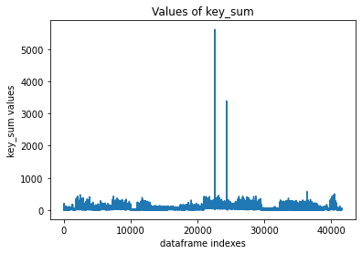

```python
plt.plot(weather_key_sum_df.index,weather_key_sum_df['key_sum'])
plt.ylabel("key_sum values")
plt.xlabel("dataframe indexes")
plt.title("Values of key_sum")
```

It seems that most of the key sum_values are between 0 and 500, except for 2 that have much more higher values.

We chose to use regression tree to predict key_sum value

Import relevant packages

```python
#Regression Tree
from sklearn import tree
from sklearn.tree import DecisionTreeRegressor

# model building
from sklearn.model_selection import train_test_split, GridSearchCV

# model evaluation
from sklearn.metrics import mean_squared_error

# set seed for reproducible results
RSEED = 10
```

We are interesed in predicting key_sum

```python
y_reg = weather_key_sum_df['key_sum']
X_reg = weather_key_sum_df.drop('key_sum',axis=1)
```

Split dataset into training set and test set

```python
X_reg_train, X_reg_test, y_reg_train, y_reg_test = train_test_split(X_reg, y_reg, test_size=0.3, random_state=RSEED)
```

Let's plot and look at the key_sum values of the test data

First we reset the index of y_reg_test

```python
y_reg_test=y_reg_test.reset_index()
y_reg_test.drop('index', axis=1,inplace=True)
y_reg_test
```

|  | key_sum |
| --- | --- |
| 0 | 17 |
| 1 | 93 |
| 2 | 39 |
| 3 | 60 |
| 4 | 46 |
| ... | ... |
| 12475 | 21 |
| 12476 | 25 |
| 12477 | 62 |
| 12478 | 49 |
| 12479 | 203 |

12480 rows × 1 columns

Then we plot the values according to the index

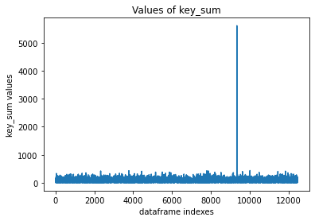

```python
plt.plot(y_reg_test.index,plot_y_reg_test)
plt.ylabel("key_sum values")
plt.xlabel("dataframe indexes")
plt.title("Values of key_sum")
```

We can see we have an outlayer value in the test dataset, so we will remove from X_reg_test and y_reg_test both because it can harm the accuracy test of our models.

```python
y_reg_test_max=max(y_reg_test['key_sum'])
max_y_index=y_reg_test['key_sum'][y_reg_test['key_sum'] == y_reg_test_max].index.tolist()
X_reg_test=X_reg_test.drop(X_reg_test.index[max_y_index])
y_reg_test.drop(y_reg_test[y_reg_test['key_sum'] == y_reg_test_max].index, inplace = True)
```

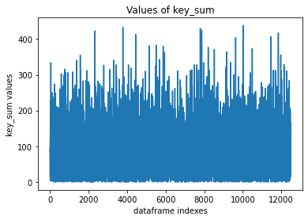

```python
plt.plot(y_reg_test.index,y_reg_test)
plt.ylabel("key_sum values")
plt.xlabel("dataframe indexes")
plt.title("Values of key_sum")
```

Define the model

```python
# define model
dt = DecisionTreeRegressor(random_state=RSEED)

# define parameter grid
parameters_grid = {
    'max_depth': [2, 4, 8, 10],
    'min_samples_split': [10, 20,30],
    'min_samples_leaf': [10, 20, 30]
}

# define grid search
grid_search = GridSearchCV(estimator=dt, param_grid=parameters_grid)
```

Fit the model

```python
# fit estimator
start_time=datetime.now()
grid_search.fit(X_reg_train, y_reg_train)
end_time=datetime.now()
performance_time=end_time-start_time
# get best estimator
best = grid_search.best_estimator_
```

Print best parameters

```python
pd.DataFrame.from_dict(grid_search.best_params_, orient='index', columns=['Selected Value'])
```

|  | Selected Value |
| --- | --- |
| max_depth | 10 |
| min_samples_leaf | 30 |
| min_samples_split | 10 |

From maximum depth of the tree options (2,4,8,10) the best max depth is 10.  
From the minimum samples in a leaf options (10,20,30), the best one is 30.  
From the minimum samples that under this number we do not do more splits, from the options (10,20,30) the best one is 10.

Predict key_sum value

```python
y_pred_regtree = best.predict(X_reg_test)
y_pred_regtree
```

```
array([ 44.00719424,  61.17070358,  41.49463883, ...,  90.9583958 ,
        49.26839827, 204.23404255])
```

Calculate MSE

```python
MSE_tree = round(mean_squared_error(y_reg_test, y_pred_regtree), 3)

df = pd.DataFrame([MSE_tree]).T
df = df.rename(index={0: 'Decision Tree Regressor'}, columns={0: 'MSE'})
run_time=performance_time.total_seconds()
df['run time(seconds)']=run_time
df
```

|  | MSE | run time(seconds) |
| --- | --- | --- |
| Decision Tree Regressor | 1629.083 | 99.390431 |

Check features importance

```python
# get feature importance
imp = pd.DataFrame(grid_search.best_estimator_.fit(X_reg_train, y_reg_train).feature_importances_,
                   index=X_reg_train.columns, columns=['Importance']).sort_values('Importance')
```

Sort features according to their importance

```python
imp=imp.sort_values('Importance')
imp
```

|  | Importance |
| --- | --- |
| SN UP HZ | 0.000000 |
| BR UP | 0.000000 |
| BR HZ VCTS | 0.000000 |
| cool | 0.000000 |
| BCFG BR | 0.000000 |
| ... | ... |
| store_nbr_15 | 0.061450 |
| item_nbr_37 | 0.066604 |
| item_nbr_52 | 0.070939 |
| store_nbr_25 | 0.096523 |
| stnpressure | 0.302042 |

632 rows × 1 columns

Select top 5 feautres according to importance

```python
top_5_features=imp.tail()
top_5_features
```

|  | Importance |
| --- | --- |
| store_nbr_15 | 0.061450 |
| item_nbr_37 | 0.066604 |
| item_nbr_52 | 0.070939 |
| store_nbr_25 | 0.096523 |
| stnpressure | 0.302042 |

Plot feature importance

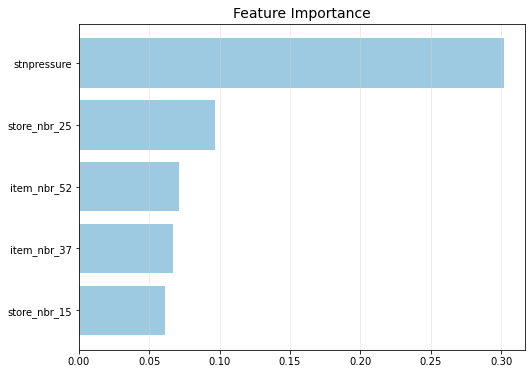

```python
plt.figure(figsize=(8, 6))
plt.barh(range(0, len(top_5_features)), top_5_features['Importance'], color='#9ecae1')
plt.grid(axis='x', alpha=0.5, color='lightgrey')
plt.yticks(range(0, len(top_5_features)), top_5_features.index)
plt.title('Feature Importance', fontsize=14)
plt.show()
```

We can see that the most important feature to predict key_sum is stnpressure.

We will now try to predict key_sum with KNN regressor

Import relevant package

```python
# KNN
from sklearn.neighbors import KNeighborsRegressor
```

Define model

```python
knn = KNeighborsRegressor()

# define parameter grid
parameters_grid = {
    'n_neighbors': [2, 6, 10],
    'weights': ['uniform', 'distance']
}

# define grid search
grid_search = GridSearchCV(estimator=knn, param_grid=parameters_grid)
```

Fit the model

```python
# fit estimator
start_time=datetime.now()
grid_search.fit(X_reg_train, y_reg_train)
end_time=datetime.now()
performance_time=end_time-start_time

# get best estimator
best = grid_search.best_estimator_
```

Print best parameters

```python
pd.DataFrame.from_dict(grid_search.best_params_, orient='index', columns=['Selected Value'])
```

|  | Selected Value |
| --- | --- |
| n_neighbors | 10 |
| weights | distance |

Best number of neighbors to use:10  
Best weights to use: distance

Predict key_sum values with KNN using the best parameters we got from parameters tuning

```python
y_pred_KNN = best.predict(X_reg_test)
y_pred_KNN
```

```
array([ 33.40860852, 162.47060181,  49.46053619, ..., 102.50776391,
        57.86159532, 119.7332863 ])
```

Evaluate model

```python
# calculate MSE
MSE_KNN = round(mean_squared_error(y_reg_test, y_pred_KNN), 3)

df_knn = pd.DataFrame([MSE_KNN]).T
df_knn = df_knn.rename(index={0: 'KNN Regressor'}, columns={0: 'MSE'})
run_time=performance_time.total_seconds()
df_knn['run time(seconds)']=run_time
df = pd.concat([df_knn, df], axis=0)
df
```

|  | MSE | run time(seconds) |
| --- | --- | --- |
| KNN Regressor | 2045.002 | 170.504590 |
| Decision Tree Regressor | 1629.083 | 99.390431 |

let's see the key_sum values of the test data and predictions of KNN and Regression Tree model in a plot, compared to each other

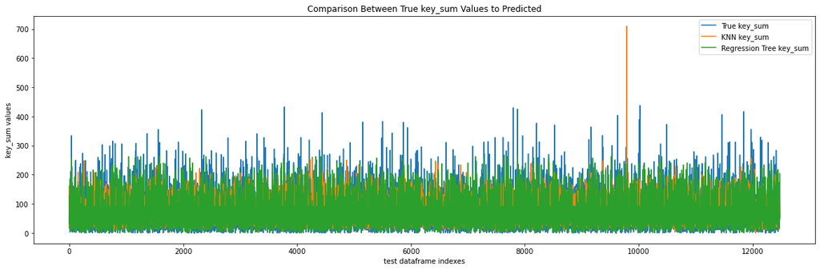

```python
plt.figure(figsize=(20, 6))
plt.plot(y_reg_test.index,y_reg_test['key_sum'], label="True key_sum")
plt.plot(y_reg_test.index,y_pred_KNN,label='KNN key_sum')
plt.plot(y_reg_test.index,y_pred_regtree,label="Regression Tree key_sum")
plt.legend()
plt.ylabel('key_sum values')
plt.xlabel('test dataframe indexes')
plt.title('Comparison Between True key_sum Values to Predicted')
```

It seems that our best model-Regression Tree succeeds pretty well in predicting the key_sum values

## Section D

We will use pivoted_sales from section C in this section too

```python
pivoted_sales=sales_df.pivot( index=['date','store_nbr'], columns='item_nbr', values='units')
pivoted_sales
```

| date | item_nbr store_nbr | 1 | 2 | 3 | 4 | 5 | 6 | 7 | 8 | 9 | 10 | ... | 102 | 103 | 104 | 105 | 106 | 107 | 108 | 109 | 110 | 111 |
| --- | --- | --- | --- | --- | --- | --- | --- | --- | --- | --- | --- | --- | --- | --- | --- | --- | --- | --- | --- | --- | --- | --- |
| 2012-01-01 | 1 | 0 | 0 | 0 | 0 | 0 | 0 | 0 | 0 | 29 | 0 | ... | 0 | 0 | 0 | 0 | 0 | 0 | 0 | 0 | 0 | 0 |
|  | 2 | 0 | 0 | 0 | 0 | 191 | 0 | 0 | 0 | 0 | 0 | ... | 0 | 0 | 0 | 0 | 0 | 0 | 0 | 0 | 0 | 0 |
|  | 3 | 0 | 0 | 0 | 0 | 214 | 0 | 0 | 0 | 0 | 0 | ... | 0 | 0 | 0 | 0 | 0 | 0 | 0 | 0 | 0 | 0 |
|  | 4 | 0 | 0 | 0 | 0 | 0 | 0 | 0 | 0 | 61 | 0 | ... | 0 | 0 | 0 | 0 | 0 | 0 | 0 | 0 | 0 | 0 |
|  | 5 | 0 | 0 | 0 | 0 | 0 | 0 | 0 | 0 | 0 | 0 | ... | 0 | 0 | 0 | 0 | 0 | 0 | 0 | 0 | 0 | 0 |
| ... | ... | ... | ... | ... | ... | ... | ... | ... | ... | ... | ... | ... | ... | ... | ... | ... | ... | ... | ... | ... | ... | ... |
| 2014-10-31 | 41 | 0 | 0 | 0 | 0 | 0 | 0 | 0 | 0 | 0 | 0 | ... | 0 | 0 | 0 | 0 | 0 | 0 | 7 | 0 | 0 | 0 |
|  | 42 | 0 | 0 | 0 | 0 | 29 | 0 | 0 | 0 | 0 | 0 | ... | 0 | 0 | 0 | 0 | 0 | 0 | 0 | 0 | 0 | 0 |
|  | 43 | 0 | 0 | 0 | 0 | 0 | 0 | 0 | 0 | 0 | 0 | ... | 0 | 0 | 0 | 0 | 0 | 0 | 0 | 0 | 0 | 0 |
|  | 44 | 0 | 0 | 0 | 0 | 47 | 0 | 0 | 0 | 0 | 0 | ... | 0 | 0 | 0 | 0 | 0 | 0 | 0 | 0 | 0 | 0 |
|  | 45 | 0 | 0 | 0 | 0 | 0 | 0 | 0 | 0 | 10 | 0 | ... | 0 | 0 | 0 | 0 | 0 | 0 | 0 | 0 | 0 | 0 |

41600 rows × 111 columns

Resest index to enable using the dataframe for model training

```python
pivoted_sales=pivoted_sales.reset_index()
pivoted_sales
```

| item_nbr | date | store_nbr | 1 | 2 | 3 | 4 | 5 | 6 | 7 | 8 | ... | 102 | 103 | 104 | 105 | 106 | 107 | 108 | 109 | 110 | 111 |
| --- | --- | --- | --- | --- | --- | --- | --- | --- | --- | --- | --- | --- | --- | --- | --- | --- | --- | --- | --- | --- | --- |
| 0 | 2012-01-01 | 1 | 0 | 0 | 0 | 0 | 0 | 0 | 0 | 0 | ... | 0 | 0 | 0 | 0 | 0 | 0 | 0 | 0 | 0 | 0 |
| 1 | 2012-01-01 | 2 | 0 | 0 | 0 | 0 | 191 | 0 | 0 | 0 | ... | 0 | 0 | 0 | 0 | 0 | 0 | 0 | 0 | 0 | 0 |
| 2 | 2012-01-01 | 3 | 0 | 0 | 0 | 0 | 214 | 0 | 0 | 0 | ... | 0 | 0 | 0 | 0 | 0 | 0 | 0 | 0 | 0 | 0 |
| 3 | 2012-01-01 | 4 | 0 | 0 | 0 | 0 | 0 | 0 | 0 | 0 | ... | 0 | 0 | 0 | 0 | 0 | 0 | 0 | 0 | 0 | 0 |
| 4 | 2012-01-01 | 5 | 0 | 0 | 0 | 0 | 0 | 0 | 0 | 0 | ... | 0 | 0 | 0 | 0 | 0 | 0 | 0 | 0 | 0 | 0 |
| ... | ... | ... | ... | ... | ... | ... | ... | ... | ... | ... | ... | ... | ... | ... | ... | ... | ... | ... | ... | ... | ... |
| 41595 | 2014-10-31 | 41 | 0 | 0 | 0 | 0 | 0 | 0 | 0 | 0 | ... | 0 | 0 | 0 | 0 | 0 | 0 | 7 | 0 | 0 | 0 |
| 41596 | 2014-10-31 | 42 | 0 | 0 | 0 | 0 | 29 | 0 | 0 | 0 | ... | 0 | 0 | 0 | 0 | 0 | 0 | 0 | 0 | 0 | 0 |
| 41597 | 2014-10-31 | 43 | 0 | 0 | 0 | 0 | 0 | 0 | 0 | 0 | ... | 0 | 0 | 0 | 0 | 0 | 0 | 0 | 0 | 0 | 0 |
| 41598 | 2014-10-31 | 44 | 0 | 0 | 0 | 0 | 47 | 0 | 0 | 0 | ... | 0 | 0 | 0 | 0 | 0 | 0 | 0 | 0 | 0 | 0 |
| 41599 | 2014-10-31 | 45 | 0 | 0 | 0 | 0 | 0 | 0 | 0 | 0 | ... | 0 | 0 | 0 | 0 | 0 | 0 | 0 | 0 | 0 | 0 |

41600 rows × 113 columns

Seperate date and store_nbr to enable adding prefix for item_nbr

```python
date_store_df=pivoted_sales[['date','store_nbr']]
date_store_df
```

| item_nbr | date | store_nbr |
| --- | --- | --- |
| 0 | 2012-01-01 | 1 |
| 1 | 2012-01-01 | 2 |
| 2 | 2012-01-01 | 3 |
| 3 | 2012-01-01 | 4 |
| 4 | 2012-01-01 | 5 |
| ... | ... | ... |
| 41595 | 2014-10-31 | 41 |
| 41596 | 2014-10-31 | 42 |
| 41597 | 2014-10-31 | 43 |
| 41598 | 2014-10-31 | 44 |
| 41599 | 2014-10-31 | 45 |

41600 rows × 2 columns

```python
pivoted_sales.drop(['date','store_nbr'], inplace=True, axis=1)
pivoted_sales
```

| item_nbr | 1 | 2 | 3 | 4 | 5 | 6 | 7 | 8 | 9 | 10 | ... | 102 | 103 | 104 | 105 | 106 | 107 | 108 | 109 | 110 | 111 |
| --- | --- | --- | --- | --- | --- | --- | --- | --- | --- | --- | --- | --- | --- | --- | --- | --- | --- | --- | --- | --- | --- |
| 0 | 0 | 0 | 0 | 0 | 0 | 0 | 0 | 0 | 29 | 0 | ... | 0 | 0 | 0 | 0 | 0 | 0 | 0 | 0 | 0 | 0 |
| 1 | 0 | 0 | 0 | 0 | 191 | 0 | 0 | 0 | 0 | 0 | ... | 0 | 0 | 0 | 0 | 0 | 0 | 0 | 0 | 0 | 0 |
| 2 | 0 | 0 | 0 | 0 | 214 | 0 | 0 | 0 | 0 | 0 | ... | 0 | 0 | 0 | 0 | 0 | 0 | 0 | 0 | 0 | 0 |
| 3 | 0 | 0 | 0 | 0 | 0 | 0 | 0 | 0 | 61 | 0 | ... | 0 | 0 | 0 | 0 | 0 | 0 | 0 | 0 | 0 | 0 |
| 4 | 0 | 0 | 0 | 0 | 0 | 0 | 0 | 0 | 0 | 0 | ... | 0 | 0 | 0 | 0 | 0 | 0 | 0 | 0 | 0 | 0 |
| ... | ... | ... | ... | ... | ... | ... | ... | ... | ... | ... | ... | ... | ... | ... | ... | ... | ... | ... | ... | ... | ... |
| 41595 | 0 | 0 | 0 | 0 | 0 | 0 | 0 | 0 | 0 | 0 | ... | 0 | 0 | 0 | 0 | 0 | 0 | 7 | 0 | 0 | 0 |
| 41596 | 0 | 0 | 0 | 0 | 29 | 0 | 0 | 0 | 0 | 0 | ... | 0 | 0 | 0 | 0 | 0 | 0 | 0 | 0 | 0 | 0 |
| 41597 | 0 | 0 | 0 | 0 | 0 | 0 | 0 | 0 | 0 | 0 | ... | 0 | 0 | 0 | 0 | 0 | 0 | 0 | 0 | 0 | 0 |
| 41598 | 0 | 0 | 0 | 0 | 47 | 0 | 0 | 0 | 0 | 0 | ... | 0 | 0 | 0 | 0 | 0 | 0 | 0 | 0 | 0 | 0 |
| 41599 | 0 | 0 | 0 | 0 | 0 | 0 | 0 | 0 | 10 | 0 | ... | 0 | 0 | 0 | 0 | 0 | 0 | 0 | 0 | 0 | 0 |

41600 rows × 111 columns

Add prefix to all item_nbr columns for meaningful columns' names

```python
pivoted_sales=pivoted_sales.add_prefix('item_nbr_')
pivoted_sales
```

| item_nbr | item_nbr_1 | item_nbr_2 | item_nbr_3 | item_nbr_4 | item_nbr_5 | item_nbr_6 | item_nbr_7 | item_nbr_8 | item_nbr_9 | item_nbr_10 | ... | item_nbr_102 | item_nbr_103 | item_nbr_104 | item_nbr_105 | item_nbr_106 | item_nbr_107 | item_nbr_108 | item_nbr_109 | item_nbr_110 | item_nbr_111 |
| --- | --- | --- | --- | --- | --- | --- | --- | --- | --- | --- | --- | --- | --- | --- | --- | --- | --- | --- | --- | --- | --- |
| 0 | 0 | 0 | 0 | 0 | 0 | 0 | 0 | 0 | 29 | 0 | ... | 0 | 0 | 0 | 0 | 0 | 0 | 0 | 0 | 0 | 0 |
| 1 | 0 | 0 | 0 | 0 | 191 | 0 | 0 | 0 | 0 | 0 | ... | 0 | 0 | 0 | 0 | 0 | 0 | 0 | 0 | 0 | 0 |
| 2 | 0 | 0 | 0 | 0 | 214 | 0 | 0 | 0 | 0 | 0 | ... | 0 | 0 | 0 | 0 | 0 | 0 | 0 | 0 | 0 | 0 |
| 3 | 0 | 0 | 0 | 0 | 0 | 0 | 0 | 0 | 61 | 0 | ... | 0 | 0 | 0 | 0 | 0 | 0 | 0 | 0 | 0 | 0 |
| 4 | 0 | 0 | 0 | 0 | 0 | 0 | 0 | 0 | 0 | 0 | ... | 0 | 0 | 0 | 0 | 0 | 0 | 0 | 0 | 0 | 0 |
| ... | ... | ... | ... | ... | ... | ... | ... | ... | ... | ... | ... | ... | ... | ... | ... | ... | ... | ... | ... | ... | ... |
| 41595 | 0 | 0 | 0 | 0 | 0 | 0 | 0 | 0 | 0 | 0 | ... | 0 | 0 | 0 | 0 | 0 | 0 | 7 | 0 | 0 | 0 |
| 41596 | 0 | 0 | 0 | 0 | 29 | 0 | 0 | 0 | 0 | 0 | ... | 0 | 0 | 0 | 0 | 0 | 0 | 0 | 0 | 0 | 0 |
| 41597 | 0 | 0 | 0 | 0 | 0 | 0 | 0 | 0 | 0 | 0 | ... | 0 | 0 | 0 | 0 | 0 | 0 | 0 | 0 | 0 | 0 |
| 41598 | 0 | 0 | 0 | 0 | 47 | 0 | 0 | 0 | 0 | 0 | ... | 0 | 0 | 0 | 0 | 0 | 0 | 0 | 0 | 0 | 0 |
| 41599 | 0 | 0 | 0 | 0 | 0 | 0 | 0 | 0 | 10 | 0 | ... | 0 | 0 | 0 | 0 | 0 | 0 | 0 | 0 | 0 | 0 |

41600 rows × 111 columns

Concat together the date and store number columns back to the item_nbr columns

```python
pivoted_sales = pd.concat([date_store_df, pivoted_sales], axis=1)
pivoted_sales
```

| item_nbr | date | store_nbr | item_nbr_1 | item_nbr_2 | item_nbr_3 | item_nbr_4 | item_nbr_5 | item_nbr_6 | item_nbr_7 | item_nbr_8 | ... | item_nbr_102 | item_nbr_103 | item_nbr_104 | item_nbr_105 | item_nbr_106 | item_nbr_107 | item_nbr_108 | item_nbr_109 | item_nbr_110 | item_nbr_111 |
| --- | --- | --- | --- | --- | --- | --- | --- | --- | --- | --- | --- | --- | --- | --- | --- | --- | --- | --- | --- | --- | --- |
| 0 | 2012-01-01 | 1 | 0 | 0 | 0 | 0 | 0 | 0 | 0 | 0 | ... | 0 | 0 | 0 | 0 | 0 | 0 | 0 | 0 | 0 | 0 |
| 1 | 2012-01-01 | 2 | 0 | 0 | 0 | 0 | 191 | 0 | 0 | 0 | ... | 0 | 0 | 0 | 0 | 0 | 0 | 0 | 0 | 0 | 0 |
| 2 | 2012-01-01 | 3 | 0 | 0 | 0 | 0 | 214 | 0 | 0 | 0 | ... | 0 | 0 | 0 | 0 | 0 | 0 | 0 | 0 | 0 | 0 |
| 3 | 2012-01-01 | 4 | 0 | 0 | 0 | 0 | 0 | 0 | 0 | 0 | ... | 0 | 0 | 0 | 0 | 0 | 0 | 0 | 0 | 0 | 0 |
| 4 | 2012-01-01 | 5 | 0 | 0 | 0 | 0 | 0 | 0 | 0 | 0 | ... | 0 | 0 | 0 | 0 | 0 | 0 | 0 | 0 | 0 | 0 |
| ... | ... | ... | ... | ... | ... | ... | ... | ... | ... | ... | ... | ... | ... | ... | ... | ... | ... | ... | ... | ... | ... |
| 41595 | 2014-10-31 | 41 | 0 | 0 | 0 | 0 | 0 | 0 | 0 | 0 | ... | 0 | 0 | 0 | 0 | 0 | 0 | 7 | 0 | 0 | 0 |
| 41596 | 2014-10-31 | 42 | 0 | 0 | 0 | 0 | 29 | 0 | 0 | 0 | ... | 0 | 0 | 0 | 0 | 0 | 0 | 0 | 0 | 0 | 0 |
| 41597 | 2014-10-31 | 43 | 0 | 0 | 0 | 0 | 0 | 0 | 0 | 0 | ... | 0 | 0 | 0 | 0 | 0 | 0 | 0 | 0 | 0 | 0 |
| 41598 | 2014-10-31 | 44 | 0 | 0 | 0 | 0 | 47 | 0 | 0 | 0 | ... | 0 | 0 | 0 | 0 | 0 | 0 | 0 | 0 | 0 | 0 |
| 41599 | 2014-10-31 | 45 | 0 | 0 | 0 | 0 | 0 | 0 | 0 | 0 | ... | 0 | 0 | 0 | 0 | 0 | 0 | 0 | 0 | 0 | 0 |

41600 rows × 113 columns

Separate the date to 3 different columns to make the date a numeric column

```python
pivoted_sales['year'] = pd.to_datetime(pivoted_sales['date']).dt.year
pivoted_sales['month']=pd.to_datetime(pivoted_sales['date']).dt.month
pivoted_sales['day']=pd.to_datetime(pivoted_sales['date']).dt.day
pivoted_sales.drop('date', axis=1, inplace=True)
pivoted_sales
```

| item_nbr | store_nbr | item_nbr_1 | item_nbr_2 | item_nbr_3 | item_nbr_4 | item_nbr_5 | item_nbr_6 | item_nbr_7 | item_nbr_8 | item_nbr_9 | ... | item_nbr_105 | item_nbr_106 | item_nbr_107 | item_nbr_108 | item_nbr_109 | item_nbr_110 | item_nbr_111 | year | month | day |
| --- | --- | --- | --- | --- | --- | --- | --- | --- | --- | --- | --- | --- | --- | --- | --- | --- | --- | --- | --- | --- | --- |
| 0 | 1 | 0 | 0 | 0 | 0 | 0 | 0 | 0 | 0 | 29 | ... | 0 | 0 | 0 | 0 | 0 | 0 | 0 | 2012 | 1 | 1 |
| 1 | 2 | 0 | 0 | 0 | 0 | 191 | 0 | 0 | 0 | 0 | ... | 0 | 0 | 0 | 0 | 0 | 0 | 0 | 2012 | 1 | 1 |
| 2 | 3 | 0 | 0 | 0 | 0 | 214 | 0 | 0 | 0 | 0 | ... | 0 | 0 | 0 | 0 | 0 | 0 | 0 | 2012 | 1 | 1 |
| 3 | 4 | 0 | 0 | 0 | 0 | 0 | 0 | 0 | 0 | 61 | ... | 0 | 0 | 0 | 0 | 0 | 0 | 0 | 2012 | 1 | 1 |
| 4 | 5 | 0 | 0 | 0 | 0 | 0 | 0 | 0 | 0 | 0 | ... | 0 | 0 | 0 | 0 | 0 | 0 | 0 | 2012 | 1 | 1 |
| ... | ... | ... | ... | ... | ... | ... | ... | ... | ... | ... | ... | ... | ... | ... | ... | ... | ... | ... | ... | ... | ... |
| 41595 | 41 | 0 | 0 | 0 | 0 | 0 | 0 | 0 | 0 | 0 | ... | 0 | 0 | 0 | 7 | 0 | 0 | 0 | 2014 | 10 | 31 |
| 41596 | 42 | 0 | 0 | 0 | 0 | 29 | 0 | 0 | 0 | 0 | ... | 0 | 0 | 0 | 0 | 0 | 0 | 0 | 2014 | 10 | 31 |
| 41597 | 43 | 0 | 0 | 0 | 0 | 0 | 0 | 0 | 0 | 0 | ... | 0 | 0 | 0 | 0 | 0 | 0 | 0 | 2014 | 10 | 31 |
| 41598 | 44 | 0 | 0 | 0 | 0 | 47 | 0 | 0 | 0 | 0 | ... | 0 | 0 | 0 | 0 | 0 | 0 | 0 | 2014 | 10 | 31 |
| 41599 | 45 | 0 | 0 | 0 | 0 | 0 | 0 | 0 | 0 | 10 | ... | 0 | 0 | 0 | 0 | 0 | 0 | 0 | 2014 | 10 | 31 |

41600 rows × 115 columns

Take the date,station_nbr and precipotal columns to join them with the pivoted_sales dataframe

```python
rainy_df=weather_df[['year','month','day','station_nbr','preciptotal']]
rainy_df
```

|  | year | month | day | station_nbr | preciptotal |
| --- | --- | --- | --- | --- | --- |
| 0 | 2012.0 | 1.0 | 1.0 | 1.0 | 0.05 |
| 1 | 2012.0 | 1.0 | 1.0 | 2.0 | 0.07 |
| 2 | 2012.0 | 1.0 | 1.0 | 3.0 | 0.00 |
| 3 | 2012.0 | 1.0 | 1.0 | 4.0 | 0.00 |
| 4 | 2012.0 | 1.0 | 1.0 | 6.0 | 0.00 |
| ... | ... | ... | ... | ... | ... |
| 20512 | 2014.0 | 10.0 | 31.0 | 16.0 | 0.00 |
| 20513 | 2014.0 | 10.0 | 31.0 | 17.0 | 0.00 |
| 20514 | 2014.0 | 10.0 | 31.0 | 18.0 | 0.00 |
| 20515 | 2014.0 | 10.0 | 31.0 | 19.0 | 0.02 |
| 20516 | 2014.0 | 10.0 | 31.0 | 20.0 | 0.00 |

20517 rows × 5 columns

We use inner join on key dataframe and rainy_df

```python
rainy_key_df=pd.merge(rainy_df, key_df, on=['station_nbr'])
rainy_key_df
```

|  | year | month | day | station_nbr | preciptotal | store_nbr |
| --- | --- | --- | --- | --- | --- | --- |
| 0 | 2012.0 | 1.0 | 1.0 | 1.0 | 0.050000 | 1 |
| 1 | 2012.0 | 1.0 | 2.0 | 1.0 | 0.010000 | 1 |
| 2 | 2012.0 | 1.0 | 3.0 | 1.0 | 0.000000 | 1 |
| 3 | 2012.0 | 1.0 | 4.0 | 1.0 | 0.000000 | 1 |
| 4 | 2012.0 | 1.0 | 5.0 | 1.0 | 0.000000 | 1 |
| ... | ... | ... | ... | ... | ... | ... |
| 46387 | 2014.0 | 10.0 | 27.0 | 5.0 | 0.000000 | 35 |
| 46388 | 2014.0 | 10.0 | 28.0 | 5.0 | 0.000000 | 35 |
| 46389 | 2014.0 | 10.0 | 29.0 | 5.0 | 0.000000 | 35 |
| 46390 | 2014.0 | 10.0 | 30.0 | 5.0 | 0.052362 | 35 |
| 46391 | 2014.0 | 10.0 | 31.0 | 5.0 | 0.055537 | 35 |

46392 rows × 6 columns

We use inner join on the joined key and rainy dataframe with pivoted_sales dataframe to enable training the model on the sales data for inferring if there was rain at a a specific day or not.

```python
sales_rainy_df=pd.merge(pivoted_sales, rainy_key_df, on=['store_nbr','year','month','day'])
sales_rainy_df
```

|  | store_nbr | item_nbr_1 | item_nbr_2 | item_nbr_3 | item_nbr_4 | item_nbr_5 | item_nbr_6 | item_nbr_7 | item_nbr_8 | item_nbr_9 | ... | item_nbr_107 | item_nbr_108 | item_nbr_109 | item_nbr_110 | item_nbr_111 | year | month | day | station_nbr | preciptotal |
| --- | --- | --- | --- | --- | --- | --- | --- | --- | --- | --- | --- | --- | --- | --- | --- | --- | --- | --- | --- | --- | --- |
| 0 | 1 | 0 | 0 | 0 | 0 | 0 | 0 | 0 | 0 | 29 | ... | 0 | 0 | 0 | 0 | 0 | 2012 | 1 | 1 | 1.0 | 0.05 |
| 1 | 2 | 0 | 0 | 0 | 0 | 191 | 0 | 0 | 0 | 0 | ... | 0 | 0 | 0 | 0 | 0 | 2012 | 1 | 1 | 14.0 | 0.00 |
| 2 | 3 | 0 | 0 | 0 | 0 | 214 | 0 | 0 | 0 | 0 | ... | 0 | 0 | 0 | 0 | 0 | 2012 | 1 | 1 | 7.0 | 0.00 |
| 3 | 4 | 0 | 0 | 0 | 0 | 0 | 0 | 0 | 0 | 61 | ... | 0 | 0 | 0 | 0 | 0 | 2012 | 1 | 1 | 9.0 | 0.01 |
| 4 | 5 | 0 | 0 | 0 | 0 | 0 | 0 | 0 | 0 | 0 | ... | 0 | 0 | 0 | 0 | 0 | 2012 | 1 | 1 | 12.0 | 0.00 |
| ... | ... | ... | ... | ... | ... | ... | ... | ... | ... | ... | ... | ... | ... | ... | ... | ... | ... | ... | ... | ... | ... |
| 41595 | 41 | 0 | 0 | 0 | 0 | 0 | 0 | 0 | 0 | 0 | ... | 0 | 7 | 0 | 0 | 0 | 2014 | 10 | 31 | 12.0 | 0.00 |
| 41596 | 42 | 0 | 0 | 0 | 0 | 29 | 0 | 0 | 0 | 0 | ... | 0 | 0 | 0 | 0 | 0 | 2014 | 10 | 31 | 14.0 | 0.00 |
| 41597 | 43 | 0 | 0 | 0 | 0 | 0 | 0 | 0 | 0 | 0 | ... | 0 | 0 | 0 | 0 | 0 | 2014 | 10 | 31 | 11.0 | 0.00 |
| 41598 | 44 | 0 | 0 | 0 | 0 | 47 | 0 | 0 | 0 | 0 | ... | 0 | 0 | 0 | 0 | 0 | 2014 | 10 | 31 | 12.0 | 0.00 |
| 41599 | 45 | 0 | 0 | 0 | 0 | 0 | 0 | 0 | 0 | 10 | ... | 0 | 0 | 0 | 0 | 0 | 2014 | 10 | 31 | 16.0 | 0.00 |

41600 rows × 117 columns

Since store_nbr is a categorial feature we will use One Hot Encoding to convert it to numeric

```python
encoded = pd.get_dummies(sales_rainy_df['store_nbr'], drop_first=True, prefix='store_nbr')
sales_rainy_df.drop('store_nbr', axis=1, inplace=True)
sales_rainy_df_encoded = pd.concat([sales_rainy_df, encoded], axis=1)
sales_rainy_df_encoded
```

|  | item_nbr_1 | item_nbr_2 | item_nbr_3 | item_nbr_4 | item_nbr_5 | item_nbr_6 | item_nbr_7 | item_nbr_8 | item_nbr_9 | item_nbr_10 | ... | store_nbr_36 | store_nbr_37 | store_nbr_38 | store_nbr_39 | store_nbr_40 | store_nbr_41 | store_nbr_42 | store_nbr_43 | store_nbr_44 | store_nbr_45 |
| --- | --- | --- | --- | --- | --- | --- | --- | --- | --- | --- | --- | --- | --- | --- | --- | --- | --- | --- | --- | --- | --- |
| 0 | 0 | 0 | 0 | 0 | 0 | 0 | 0 | 0 | 29 | 0 | ... | 0 | 0 | 0 | 0 | 0 | 0 | 0 | 0 | 0 | 0 |
| 1 | 0 | 0 | 0 | 0 | 191 | 0 | 0 | 0 | 0 | 0 | ... | 0 | 0 | 0 | 0 | 0 | 0 | 0 | 0 | 0 | 0 |
| 2 | 0 | 0 | 0 | 0 | 214 | 0 | 0 | 0 | 0 | 0 | ... | 0 | 0 | 0 | 0 | 0 | 0 | 0 | 0 | 0 | 0 |
| 3 | 0 | 0 | 0 | 0 | 0 | 0 | 0 | 0 | 61 | 0 | ... | 0 | 0 | 0 | 0 | 0 | 0 | 0 | 0 | 0 | 0 |
| 4 | 0 | 0 | 0 | 0 | 0 | 0 | 0 | 0 | 0 | 0 | ... | 0 | 0 | 0 | 0 | 0 | 0 | 0 | 0 | 0 | 0 |
| ... | ... | ... | ... | ... | ... | ... | ... | ... | ... | ... | ... | ... | ... | ... | ... | ... | ... | ... | ... | ... | ... |
| 41595 | 0 | 0 | 0 | 0 | 0 | 0 | 0 | 0 | 0 | 0 | ... | 0 | 0 | 0 | 0 | 0 | 1 | 0 | 0 | 0 | 0 |
| 41596 | 0 | 0 | 0 | 0 | 29 | 0 | 0 | 0 | 0 | 0 | ... | 0 | 0 | 0 | 0 | 0 | 0 | 1 | 0 | 0 | 0 |
| 41597 | 0 | 0 | 0 | 0 | 0 | 0 | 0 | 0 | 0 | 0 | ... | 0 | 0 | 0 | 0 | 0 | 0 | 0 | 1 | 0 | 0 |
| 41598 | 0 | 0 | 0 | 0 | 47 | 0 | 0 | 0 | 0 | 0 | ... | 0 | 0 | 0 | 0 | 0 | 0 | 0 | 0 | 1 | 0 |
| 41599 | 0 | 0 | 0 | 0 | 0 | 0 | 0 | 0 | 10 | 0 | ... | 0 | 0 | 0 | 0 | 0 | 0 | 0 | 0 | 0 | 1 |

41600 rows × 160 columns

We remove the station_nbr column from the dataframe because it is a part from the weather dataframe and we want to use only the sales dataframe to predict if rains in the area of every store in a ceratin date

```python
sales_rainy_df_encoded.drop('station_nbr', axis=1, inplace=True)
sales_rainy_df_encoded
```

|  | item_nbr_1 | item_nbr_2 | item_nbr_3 | item_nbr_4 | item_nbr_5 | item_nbr_6 | item_nbr_7 | item_nbr_8 | item_nbr_9 | item_nbr_10 | ... | store_nbr_36 | store_nbr_37 | store_nbr_38 | store_nbr_39 | store_nbr_40 | store_nbr_41 | store_nbr_42 | store_nbr_43 | store_nbr_44 | store_nbr_45 |
| --- | --- | --- | --- | --- | --- | --- | --- | --- | --- | --- | --- | --- | --- | --- | --- | --- | --- | --- | --- | --- | --- |
| 0 | 0 | 0 | 0 | 0 | 0 | 0 | 0 | 0 | 29 | 0 | ... | 0 | 0 | 0 | 0 | 0 | 0 | 0 | 0 | 0 | 0 |
| 1 | 0 | 0 | 0 | 0 | 191 | 0 | 0 | 0 | 0 | 0 | ... | 0 | 0 | 0 | 0 | 0 | 0 | 0 | 0 | 0 | 0 |
| 2 | 0 | 0 | 0 | 0 | 214 | 0 | 0 | 0 | 0 | 0 | ... | 0 | 0 | 0 | 0 | 0 | 0 | 0 | 0 | 0 | 0 |
| 3 | 0 | 0 | 0 | 0 | 0 | 0 | 0 | 0 | 61 | 0 | ... | 0 | 0 | 0 | 0 | 0 | 0 | 0 | 0 | 0 | 0 |
| 4 | 0 | 0 | 0 | 0 | 0 | 0 | 0 | 0 | 0 | 0 | ... | 0 | 0 | 0 | 0 | 0 | 0 | 0 | 0 | 0 | 0 |
| ... | ... | ... | ... | ... | ... | ... | ... | ... | ... | ... | ... | ... | ... | ... | ... | ... | ... | ... | ... | ... | ... |
| 41595 | 0 | 0 | 0 | 0 | 0 | 0 | 0 | 0 | 0 | 0 | ... | 0 | 0 | 0 | 0 | 0 | 1 | 0 | 0 | 0 | 0 |
| 41596 | 0 | 0 | 0 | 0 | 29 | 0 | 0 | 0 | 0 | 0 | ... | 0 | 0 | 0 | 0 | 0 | 0 | 1 | 0 | 0 | 0 |
| 41597 | 0 | 0 | 0 | 0 | 0 | 0 | 0 | 0 | 0 | 0 | ... | 0 | 0 | 0 | 0 | 0 | 0 | 0 | 1 | 0 | 0 |
| 41598 | 0 | 0 | 0 | 0 | 47 | 0 | 0 | 0 | 0 | 0 | ... | 0 | 0 | 0 | 0 | 0 | 0 | 0 | 0 | 1 | 0 |
| 41599 | 0 | 0 | 0 | 0 | 0 | 0 | 0 | 0 | 10 | 0 | ... | 0 | 0 | 0 | 0 | 0 | 0 | 0 | 0 | 0 | 1 |

41600 rows × 159 columns

Create a new column called 'is_rainy' which will contain True value for every row with preciptotal bigger than 0, else will contain False

```python
sales_rainy_df_encoded['is_rainy'] = np.where(sales_rainy_df_encoded['preciptotal']>0, True, False)
sales_rainy_df_encoded
```

|  | item_nbr_1 | item_nbr_2 | item_nbr_3 | item_nbr_4 | item_nbr_5 | item_nbr_6 | item_nbr_7 | item_nbr_8 | item_nbr_9 | item_nbr_10 | ... | store_nbr_37 | store_nbr_38 | store_nbr_39 | store_nbr_40 | store_nbr_41 | store_nbr_42 | store_nbr_43 | store_nbr_44 | store_nbr_45 | is_rainy |
| --- | --- | --- | --- | --- | --- | --- | --- | --- | --- | --- | --- | --- | --- | --- | --- | --- | --- | --- | --- | --- | --- |
| 0 | 0 | 0 | 0 | 0 | 0 | 0 | 0 | 0 | 29 | 0 | ... | 0 | 0 | 0 | 0 | 0 | 0 | 0 | 0 | 0 | True |
| 1 | 0 | 0 | 0 | 0 | 191 | 0 | 0 | 0 | 0 | 0 | ... | 0 | 0 | 0 | 0 | 0 | 0 | 0 | 0 | 0 | False |
| 2 | 0 | 0 | 0 | 0 | 214 | 0 | 0 | 0 | 0 | 0 | ... | 0 | 0 | 0 | 0 | 0 | 0 | 0 | 0 | 0 | False |
| 3 | 0 | 0 | 0 | 0 | 0 | 0 | 0 | 0 | 61 | 0 | ... | 0 | 0 | 0 | 0 | 0 | 0 | 0 | 0 | 0 | True |
| 4 | 0 | 0 | 0 | 0 | 0 | 0 | 0 | 0 | 0 | 0 | ... | 0 | 0 | 0 | 0 | 0 | 0 | 0 | 0 | 0 | False |
| ... | ... | ... | ... | ... | ... | ... | ... | ... | ... | ... | ... | ... | ... | ... | ... | ... | ... | ... | ... | ... | ... |
| 41595 | 0 | 0 | 0 | 0 | 0 | 0 | 0 | 0 | 0 | 0 | ... | 0 | 0 | 0 | 0 | 1 | 0 | 0 | 0 | 0 | False |
| 41596 | 0 | 0 | 0 | 0 | 29 | 0 | 0 | 0 | 0 | 0 | ... | 0 | 0 | 0 | 0 | 0 | 1 | 0 | 0 | 0 | False |
| 41597 | 0 | 0 | 0 | 0 | 0 | 0 | 0 | 0 | 0 | 0 | ... | 0 | 0 | 0 | 0 | 0 | 0 | 1 | 0 | 0 | False |
| 41598 | 0 | 0 | 0 | 0 | 47 | 0 | 0 | 0 | 0 | 0 | ... | 0 | 0 | 0 | 0 | 0 | 0 | 0 | 1 | 0 | False |
| 41599 | 0 | 0 | 0 | 0 | 0 | 0 | 0 | 0 | 10 | 0 | ... | 0 | 0 | 0 | 0 | 0 | 0 | 0 | 0 | 1 | False |

41600 rows × 160 columns

Create a neew dataframe with no store_nbr 11 rows, so we will not train and test our models on the data we want to use to predict if it is a rainy day or not

```python
sales_rainy_df_encoded_no_11=sales_rainy_df_encoded[sales_rainy_df_encoded['store_nbr_11']!=1]

sales_rainy_df_encoded_no_11
```

|  | item_nbr_1 | item_nbr_2 | item_nbr_3 | item_nbr_4 | item_nbr_5 | item_nbr_6 | item_nbr_7 | item_nbr_8 | item_nbr_9 | item_nbr_10 | ... | store_nbr_37 | store_nbr_38 | store_nbr_39 | store_nbr_40 | store_nbr_41 | store_nbr_42 | store_nbr_43 | store_nbr_44 | store_nbr_45 | is_rainy |
| --- | --- | --- | --- | --- | --- | --- | --- | --- | --- | --- | --- | --- | --- | --- | --- | --- | --- | --- | --- | --- | --- |
| 0 | 0 | 0 | 0 | 0 | 0 | 0 | 0 | 0 | 29 | 0 | ... | 0 | 0 | 0 | 0 | 0 | 0 | 0 | 0 | 0 | True |
| 1 | 0 | 0 | 0 | 0 | 191 | 0 | 0 | 0 | 0 | 0 | ... | 0 | 0 | 0 | 0 | 0 | 0 | 0 | 0 | 0 | False |
| 2 | 0 | 0 | 0 | 0 | 214 | 0 | 0 | 0 | 0 | 0 | ... | 0 | 0 | 0 | 0 | 0 | 0 | 0 | 0 | 0 | False |
| 3 | 0 | 0 | 0 | 0 | 0 | 0 | 0 | 0 | 61 | 0 | ... | 0 | 0 | 0 | 0 | 0 | 0 | 0 | 0 | 0 | True |
| 4 | 0 | 0 | 0 | 0 | 0 | 0 | 0 | 0 | 0 | 0 | ... | 0 | 0 | 0 | 0 | 0 | 0 | 0 | 0 | 0 | False |
| ... | ... | ... | ... | ... | ... | ... | ... | ... | ... | ... | ... | ... | ... | ... | ... | ... | ... | ... | ... | ... | ... |
| 41595 | 0 | 0 | 0 | 0 | 0 | 0 | 0 | 0 | 0 | 0 | ... | 0 | 0 | 0 | 0 | 1 | 0 | 0 | 0 | 0 | False |
| 41596 | 0 | 0 | 0 | 0 | 29 | 0 | 0 | 0 | 0 | 0 | ... | 0 | 0 | 0 | 0 | 0 | 1 | 0 | 0 | 0 | False |
| 41597 | 0 | 0 | 0 | 0 | 0 | 0 | 0 | 0 | 0 | 0 | ... | 0 | 0 | 0 | 0 | 0 | 0 | 1 | 0 | 0 | False |
| 41598 | 0 | 0 | 0 | 0 | 47 | 0 | 0 | 0 | 0 | 0 | ... | 0 | 0 | 0 | 0 | 0 | 0 | 0 | 1 | 0 | False |
| 41599 | 0 | 0 | 0 | 0 | 0 | 0 | 0 | 0 | 10 | 0 | ... | 0 | 0 | 0 | 0 | 0 | 0 | 0 | 0 | 1 | False |

40702 rows × 160 columns

Remove the preciptotal column because the predicted values column-is_rainy is derived from it

```python
sales_rainy_df_encoded_no_11=sales_rainy_df_encoded_no_11.drop('preciptotal', axis=1)
sales_rainy_df_encoded_no_11
```

|  | item_nbr_1 | item_nbr_2 | item_nbr_3 | item_nbr_4 | item_nbr_5 | item_nbr_6 | item_nbr_7 | item_nbr_8 | item_nbr_9 | item_nbr_10 | ... | store_nbr_37 | store_nbr_38 | store_nbr_39 | store_nbr_40 | store_nbr_41 | store_nbr_42 | store_nbr_43 | store_nbr_44 | store_nbr_45 | is_rainy |
| --- | --- | --- | --- | --- | --- | --- | --- | --- | --- | --- | --- | --- | --- | --- | --- | --- | --- | --- | --- | --- | --- |
| 0 | 0 | 0 | 0 | 0 | 0 | 0 | 0 | 0 | 29 | 0 | ... | 0 | 0 | 0 | 0 | 0 | 0 | 0 | 0 | 0 | True |
| 1 | 0 | 0 | 0 | 0 | 191 | 0 | 0 | 0 | 0 | 0 | ... | 0 | 0 | 0 | 0 | 0 | 0 | 0 | 0 | 0 | False |
| 2 | 0 | 0 | 0 | 0 | 214 | 0 | 0 | 0 | 0 | 0 | ... | 0 | 0 | 0 | 0 | 0 | 0 | 0 | 0 | 0 | False |
| 3 | 0 | 0 | 0 | 0 | 0 | 0 | 0 | 0 | 61 | 0 | ... | 0 | 0 | 0 | 0 | 0 | 0 | 0 | 0 | 0 | True |
| 4 | 0 | 0 | 0 | 0 | 0 | 0 | 0 | 0 | 0 | 0 | ... | 0 | 0 | 0 | 0 | 0 | 0 | 0 | 0 | 0 | False |
| ... | ... | ... | ... | ... | ... | ... | ... | ... | ... | ... | ... | ... | ... | ... | ... | ... | ... | ... | ... | ... | ... |
| 41595 | 0 | 0 | 0 | 0 | 0 | 0 | 0 | 0 | 0 | 0 | ... | 0 | 0 | 0 | 0 | 1 | 0 | 0 | 0 | 0 | False |
| 41596 | 0 | 0 | 0 | 0 | 29 | 0 | 0 | 0 | 0 | 0 | ... | 0 | 0 | 0 | 0 | 0 | 1 | 0 | 0 | 0 | False |
| 41597 | 0 | 0 | 0 | 0 | 0 | 0 | 0 | 0 | 0 | 0 | ... | 0 | 0 | 0 | 0 | 0 | 0 | 1 | 0 | 0 | False |
| 41598 | 0 | 0 | 0 | 0 | 47 | 0 | 0 | 0 | 0 | 0 | ... | 0 | 0 | 0 | 0 | 0 | 0 | 0 | 1 | 0 | False |
| 41599 | 0 | 0 | 0 | 0 | 0 | 0 | 0 | 0 | 10 | 0 | ... | 0 | 0 | 0 | 0 | 0 | 0 | 0 | 0 | 1 | False |

40702 rows × 159 columns

Let's look on the values of the is_rainy column

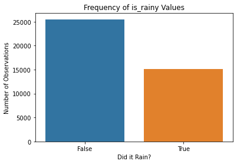

```python
sns.countplot(x="is_rainy", data=sales_rainy_df_encoded_no_11)
plt.ylabel("Number of Observations")
plt.xlabel("Did it Rain?")
plt.title("Frequency of is_rainy Values")
```

We will try to use decision tree model to predict if it is a rainy day for each store in different dates

Import relevant packages

```python
# decision tree
from sklearn import tree
from sklearn.tree import DecisionTreeClassifier

# model building
from sklearn.model_selection import train_test_split, GridSearchCV

# model evaluation
from sklearn.metrics import accuracy_score
```

Separete to attributes and labels: the label is is_rainy column

```python
X_cls = sales_rainy_df_encoded_no_11.drop('is_rainy', axis=1)
y_cls = sales_rainy_df_encoded_no_11['is_rainy']
```

Split dataset into training set and test set

```python
X_cls_train, X_cls_test, y_cls_train, y_cls_test = train_test_split(X_cls, y_cls, test_size=0.3, random_state=RSEED)
```

Define model

```python
dt = DecisionTreeClassifier(random_state=RSEED)

# define parameter grid
parameters_grid = {
    'max_depth': [20,30,40,60,80],
    'min_samples_split': [4 ,8 ,12],
    'min_samples_leaf': [2, 4, 8]
}

# define grid search
grid_search = GridSearchCV(estimator=dt, param_grid=parameters_grid)
```

Fit the model

```python
# fit estimator
start_time=datetime.now()
grid_search.fit(X_cls_train, y_cls_train)
end_time=datetime.now()
performance_time=end_time-start_time
# get best estimator
best_tree = grid_search.best_estimator_
```

print best parameters

```python
pd.DataFrame.from_dict(grid_search.best_params_, orient='index', columns=['Selected Value'])
```

|  | Selected Value |
| --- | --- |
| max_depth | 40 |
| min_samples_leaf | 8 |
| min_samples_split | 4 |

The parameters that will give us the best result are :  
maximum depth of the tree:40  
the minumum amount of samples for a leaf: 8  
From the minimum samples that under this number we do not do more splits: 4

Predict on the test dataframe

```python
y_pred_decision_tree = best_tree.predict(X_cls_test)
```

Evalute the model

```python
# calculate accuracy
acc_decison_tree = round(accuracy_score(y_cls_test, y_pred_decision_tree), 3)

df = pd.DataFrame([acc_decison_tree]).T
df = df.rename(index={0: 'Decision Tree Classifier'}, columns={0: 'Accuracy'})
run_time=performance_time.total_seconds()
df['run time(seconds)']=run_time
df
```

|  | Accuracy | run time(seconds) |
| --- | --- | --- |
| Decision Tree Classifier | 0.681 | 209.124338 |

Get features importance

```python
imp = pd.DataFrame(grid_search.best_estimator_.fit(X_cls_train, y_cls_train).feature_importances_,
                   index=X_cls_train.columns, columns=['Importance']).sort_values('Importance')
```

Sort features according to their importance

```python
imp=imp.sort_values('Importance')
imp
```

|  | Importance |
| --- | --- |
| item_nbr_1 | 0.000000 |
| store_nbr_27 | 0.000000 |
| store_nbr_24 | 0.000000 |
| store_nbr_20 | 0.000000 |
| store_nbr_19 | 0.000000 |
| ... | ... |
| item_nbr_9 | 0.051241 |
| item_nbr_5 | 0.062570 |
| item_nbr_45 | 0.072576 |
| month | 0.228644 |
| day | 0.274212 |

158 rows × 1 columns

Select top 5 feautres according to importance

```python
top_5_features=imp.tail()
top_5_features
```

|  | Importance |
| --- | --- |
| item_nbr_9 | 0.051241 |
| item_nbr_5 | 0.062570 |
| item_nbr_45 | 0.072576 |
| month | 0.228644 |
| day | 0.274212 |

Plot feature importance

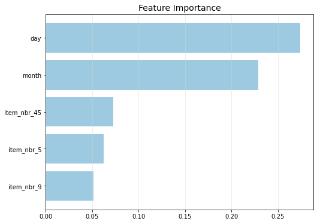

```python
plt.figure(figsize=(8, 6))
plt.barh(range(0, len(top_5_features)), top_5_features['Importance'], color='#9ecae1')
plt.grid(axis='x', alpha=0.5, color='lightgrey')
plt.yticks(range(0, len(top_5_features)), top_5_features.index)
plt.title('Feature Importance', fontsize=14)
plt.show()
```

We can see that the most important features to predict if it was a rainy day or not is day and month attributes.  
Afterwards it's item number 45, maybe an umbrella?

Now we will try using Adaboost algorithm and see if we get better predictions

Import relevant packages

```python
# adaboost
from sklearn.ensemble import AdaBoostClassifier

# model building
from sklearn.model_selection import train_test_split, GridSearchCV

# model evaluation
from sklearn.metrics import accuracy_score
```

Define the model

```python
ab = AdaBoostClassifier(random_state=RSEED)

# define parameter grid
parameters_grid = {
    'n_estimators': [20, 50,70,100,120,140]
}

# define grid search
grid_search = GridSearchCV(estimator=ab, param_grid=parameters_grid)
```

Fit the model

```python
# fit estimator
start_time=datetime.now()
grid_search.fit(X_cls_train, y_cls_train)
end_time=datetime.now()
performance_time=end_time-start_time

# get best estimator
best_adaboost = grid_search.best_estimator_
```

print best parameters

```python
pd.DataFrame.from_dict(grid_search.best_params_, orient='index', columns=['Selected Value'])
```

|  | Selected Value |
| --- | --- |
| n_estimators | 120 |

Predict

```python
y_pred_adaboost = best_adaboost.predict(X_cls_test)
```

Evalute the model

```python
# calculate accuracy
acc_adaboost = round(accuracy_score(y_cls_test, y_pred_adaboost), 3)

df_adaboost = pd.DataFrame([acc_adaboost]).T
df_adaboost = df_adaboost.rename(index={0: 'AdaBoost Classifier'}, columns={0: 'Accuracy'})
run_time=performance_time.total_seconds()
df_adaboost['run time(seconds)']=run_time
df = pd.concat([df_adaboost, df], axis=0)
df
```

|  | Accuracy | run time(seconds) |
| --- | --- | --- |
| AdaBoost Classifier | 0.644 | 665.349500 |
| Decision Tree Classifier | 0.681 | 209.124338 |

Get features importance

```python
imp = pd.DataFrame(grid_search.best_estimator_.fit(X_cls_train, y_cls_train).feature_importances_,
                   index=X_cls_train.columns, columns=['Importance']).sort_values('Importance')
```

Sort features according to their importance

```python
imp=imp.sort_values('Importance')
imp
```

|  | Importance |
| --- | --- |
| item_nbr_1 | 0.000000 |
| store_nbr_37 | 0.000000 |
| store_nbr_35 | 0.000000 |
| item_nbr_17 | 0.000000 |
| item_nbr_18 | 0.000000 |
| ... | ... |
| item_nbr_5 | 0.025000 |
| item_nbr_45 | 0.025000 |
| item_nbr_93 | 0.058333 |
| day | 0.091667 |
| month | 0.100000 |

158 rows × 1 columns

Select top 5 feautres according to importance

```python
top_5_features=imp.tail()
top_5_features
```

|  | Importance |
| --- | --- |
| item_nbr_5 | 0.025000 |
| item_nbr_45 | 0.025000 |
| item_nbr_93 | 0.058333 |
| day | 0.091667 |
| month | 0.100000 |

Plot feature importance

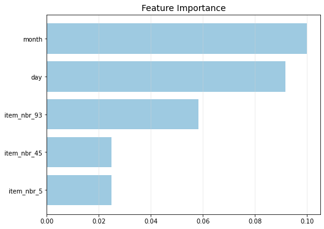

```python
plt.figure(figsize=(8, 6))
plt.barh(range(0, len(top_5_features)), top_5_features['Importance'], color='#9ecae1')
plt.grid(axis='x', alpha=0.5, color='lightgrey')
plt.yticks(range(0, len(top_5_features)), top_5_features.index)
plt.title('Feature Importance', fontsize=14)
plt.show()
```

Import relevant packages

```python
from sklearn.ensemble import RandomForestClassifier
```

Define the model

```python
# define model
rf = RandomForestClassifier(random_state=RSEED)

# define parameter grid
parameters_grid = {
    'max_depth': [20,30,40,60,80],
    'min_samples_split': [4 ,8 ,12],
    'min_samples_leaf': [2, 4, 8],
    'n_estimators': [20, 50]
}

# define grid search
grid_search = GridSearchCV(estimator=rf, param_grid=parameters_grid)
```

Fit the model

```python
# fit estimator
start_time=datetime.now()
grid_search.fit(X_cls_train, y_cls_train)
end_time=datetime.now()
performance_time=end_time-start_time

# get best estimator
best_forest = grid_search.best_estimator_
```

print best parameters

```python
pd.DataFrame.from_dict(grid_search.best_params_, orient='index', columns=['Selected Value'])
```

|  | Selected Value |
| --- | --- |
| max_depth | 80 |
| min_samples_leaf | 2 |
| min_samples_split | 12 |
| n_estimators | 50 |

The parameters that will give us the best result are :  
maximum depth of the trees:80  
the minumum amount of samples for a leaf: 2  
From the minimum samples that under this number we do not do more splits: 12  
The number of trees we use: 50

Predict

```python
y_pred_forest = best_forest.predict(X_cls_test)
```

Evalute the model

```python
# calculate accuracy
acc_forest = round(accuracy_score(y_cls_test, y_pred_forest), 3)

df_forest = pd.DataFrame([acc_forest]).T
df_forest = df_forest.rename(index={0: 'Random Forest Classifier'}, columns={0: 'Accuracy'})
run_time=performance_time.total_seconds()
df_forest['run time(seconds)']=run_time
df = pd.concat([df_forest, df], axis=0)
df
```

|  | Accuracy | run time(seconds) |
| --- | --- | --- |
| Random Forest Classifier | 0.658 | 1200.545809 |
| AdaBoost Classifier | 0.644 | 665.349500 |
| Decision Tree Classifier | 0.681 | 209.124338 |

Get features importance

```python
imp = pd.DataFrame(grid_search.best_estimator_.fit(X_cls_train, y_cls_train).feature_importances_,
                   index=X_cls_train.columns, columns=['Importance']).sort_values('Importance')
```

Sort features according to their importance

```python
imp=imp.sort_values('Importance')
imp
```

|  | Importance |
| --- | --- |
| store_nbr_11 | 0.000000 |
| item_nbr_87 | 0.000000 |
| item_nbr_110 | 0.000000 |
| item_nbr_102 | 0.000173 |
| item_nbr_111 | 0.000439 |
| ... | ... |
| item_nbr_45 | 0.054697 |
| item_nbr_9 | 0.056888 |
| item_nbr_5 | 0.060874 |
| month | 0.113119 |
| day | 0.141913 |

158 rows × 1 columns

Select top 5 feautres according to importance

```python
top_5_features=imp.tail()
top_5_features
```

|  | Importance |
| --- | --- |
| item_nbr_45 | 0.054697 |
| item_nbr_9 | 0.056888 |
| item_nbr_5 | 0.060874 |
| month | 0.113119 |
| day | 0.141913 |

Plot feature importance

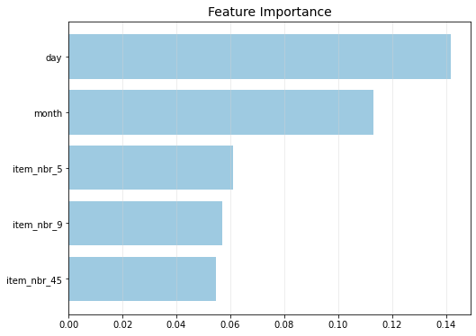

```python
plt.figure(figsize=(8, 6))
plt.barh(range(0, len(top_5_features)), top_5_features['Importance'], color='#9ecae1')
plt.grid(axis='x', alpha=0.5, color='lightgrey')
plt.yticks(range(0, len(top_5_features)), top_5_features.index)
plt.title('Feature Importance', fontsize=14)
plt.show()
```

We can see that the most important features to predict if it was a rainy day or not is day and month attributes.

```python
df
```

|  | Accuracy | run time(seconds) |
| --- | --- | --- |
| Random Forest Classifier | 0.658 | 1200.545809 |
| AdaBoost Classifier | 0.644 | 665.349500 |
| Decision Tree Classifier | 0.681 | 209.124338 |

We can see that the best model is the Decision Tree Classifier with accuracy of 68.1% on the test data and better run time.

Create a dataframe that contains only store_nbr 11 data

```python
store_nbr_11_df=sales_rainy_df_encoded[sales_rainy_df_encoded['store_nbr_11']==1]
store_nbr_11_df=store_nbr_11_df.drop('preciptotal', axis=1)
store_nbr_11_df
```

|  | item_nbr_1 | item_nbr_2 | item_nbr_3 | item_nbr_4 | item_nbr_5 | item_nbr_6 | item_nbr_7 | item_nbr_8 | item_nbr_9 | item_nbr_10 | ... | store_nbr_37 | store_nbr_38 | store_nbr_39 | store_nbr_40 | store_nbr_41 | store_nbr_42 | store_nbr_43 | store_nbr_44 | store_nbr_45 | is_rainy |
| --- | --- | --- | --- | --- | --- | --- | --- | --- | --- | --- | --- | --- | --- | --- | --- | --- | --- | --- | --- | --- | --- |
| 10 | 0 | 0 | 0 | 0 | 0 | 0 | 0 | 0 | 74 | 0 | ... | 0 | 0 | 0 | 0 | 0 | 0 | 0 | 0 | 0 | False |
| 54 | 0 | 0 | 0 | 0 | 0 | 0 | 0 | 0 | 49 | 0 | ... | 0 | 0 | 0 | 0 | 0 | 0 | 0 | 0 | 0 | False |
| 98 | 0 | 0 | 0 | 0 | 0 | 0 | 0 | 0 | 42 | 0 | ... | 0 | 0 | 0 | 0 | 0 | 0 | 0 | 0 | 0 | False |
| 142 | 0 | 0 | 0 | 0 | 0 | 0 | 0 | 0 | 60 | 0 | ... | 0 | 0 | 0 | 0 | 0 | 0 | 0 | 0 | 0 | False |
| 186 | 0 | 0 | 0 | 0 | 0 | 0 | 0 | 0 | 49 | 0 | ... | 0 | 0 | 0 | 0 | 0 | 0 | 0 | 0 | 0 | False |
| ... | ... | ... | ... | ... | ... | ... | ... | ... | ... | ... | ... | ... | ... | ... | ... | ... | ... | ... | ... | ... | ... |
| 41385 | 0 | 0 | 0 | 0 | 0 | 0 | 0 | 0 | 22 | 0 | ... | 0 | 0 | 0 | 0 | 0 | 0 | 0 | 0 | 0 | False |
| 41430 | 0 | 0 | 0 | 0 | 0 | 0 | 0 | 0 | 18 | 0 | ... | 0 | 0 | 0 | 0 | 0 | 0 | 0 | 0 | 0 | False |
| 41475 | 0 | 0 | 0 | 0 | 0 | 0 | 0 | 0 | 46 | 0 | ... | 0 | 0 | 0 | 0 | 0 | 0 | 0 | 0 | 0 | False |
| 41520 | 0 | 0 | 0 | 0 | 0 | 0 | 0 | 0 | 20 | 0 | ... | 0 | 0 | 0 | 0 | 0 | 0 | 0 | 0 | 0 | True |
| 41565 | 0 | 0 | 0 | 0 | 0 | 0 | 0 | 0 | 4 | 0 | ... | 0 | 0 | 0 | 0 | 0 | 0 | 0 | 0 | 0 | False |

898 rows × 159 columns

Create store_nbr_11_df attributes dataframe and is_rainy values dataframe seperated

```python
store_11_x = store_nbr_11_df.drop('is_rainy', axis=1)
store_11_y = store_nbr_11_df['is_rainy']
```

We will use our best model- the Decision Tree Classifier to predict for each date if it rained around store_nbr 11

```python
predicted_store_11=best_tree.predict(store_11_x)
```

Check the accuracy for predicting the rainy days for store_nbr 11

```python
acc_store_11 = round(accuracy_score(store_11_y, predicted_store_11), 3)
print("The accuracy of predicting the rainy days for store 11 is "+str(acc_store_11*100)+'%')
```

```
The accuracy of predicting the rainy days for store 11 is 64.9%
```

Create a dataframe that will tell for every given day if it rained or not at the area of store_nbr 11, according to the predicted values

```python
predicted_store_11_date=store_11_x.filter(['day','month','year'], axis=1)
predicted_store_11_date['is_rainy']=predicted_store_11
predicted_store_11_date
```

|  | day | month | year | is_rainy |
| --- | --- | --- | --- | --- |
| 10 | 1 | 1 | 2012 | False |
| 54 | 2 | 1 | 2012 | False |
| 98 | 3 | 1 | 2012 | False |
| 142 | 4 | 1 | 2012 | False |
| 186 | 5 | 1 | 2012 | False |
| ... | ... | ... | ... | ... |
| 41385 | 27 | 10 | 2014 | False |
| 41430 | 28 | 10 | 2014 | False |
| 41475 | 29 | 10 | 2014 | True |
| 41520 | 30 | 10 | 2014 | False |
| 41565 | 31 | 10 | 2014 | True |

898 rows × 4 columns

In the next cell you can enter a date and you will get an answer- if it rained at the area of store_nbr 11 at that date

```python
day=int(input("Please enter day number:"))
month=int(input("Please enter month number:"))
year=int(input("Please enter year number:"))

result = predicted_store_11_date[(predicted_store_11_date['day']==day) & (predicted_store_11_date['month']==month) & (predicted_store_11_date['year']==year)]
if result['is_rainy'].bool()==True:
    print('At '+str(day)+'/'+str(month)+'/'+str(year)+' it was a rainy day at store 11')
else:
    print('At '+str(day)+'/'+str(month)+'/'+str(year)+' it was not a rainy day at store 11')
```

```
Please enter day number:1
Please enter month number:4
Please enter year number:2013
At 1/4/2013 it was a rainy day at store 11
```

## Section E

The equation to estimate the altidude of a place according to the air pressure is:  
H = 44330 * [1 - (P/p0)^(1/5.255) ]  
H = altitude (meters)  
P = measured pressure (Pa) from the sensor  
p0 = reference pressure at sea level  
So we will calculate the average measured pressure (stnpressure) and the pressure at sea level (sealevel) for every station, using group_by on station_nbr and getting the mean stnpressure and sealevel values for every station_nbr

```python
pressure_station_df=weather_df.groupby('station_nbr')[['stnpressure', 'sealevel','tavg']].mean()
pressure_station_df['altitude(m)']=np.nan
pressure_station_df
```

| station_nbr | stnpressure | sealevel | tavg | altitude(m) |
| --- | --- | --- | --- | --- |
| 1.0 | 29.846075 | 30.013755 | 52.302534 | NaN |
| 2.0 | 28.908499 | 30.009118 | 49.905044 | NaN |
| 3.0 | 29.280267 | 29.997143 | 62.633148 | NaN |
| 4.0 | 29.318928 | 30.004476 | 71.386180 | NaN |
| 5.0 | 28.900099 | 30.017847 | 63.834948 | NaN |
| 6.0 | 29.479402 | 29.999005 | 69.240312 | NaN |
| 7.0 | 28.628712 | 29.991920 | 62.955268 | NaN |
| 8.0 | 29.654643 | 30.035629 | 68.338857 | NaN |
| 9.0 | 29.224242 | 29.995030 | 48.922965 | NaN |
| 10.0 | 30.023986 | 30.049972 | 73.130717 | NaN |
| 11.0 | 30.014164 | 30.057324 | 69.676964 | NaN |
| 12.0 | 30.008249 | 30.056469 | 71.342118 | NaN |
| 13.0 | 24.243412 | 29.973017 | 51.921552 | NaN |
| 14.0 | 28.612727 | 29.989994 | 62.960139 | NaN |
| 15.0 | 29.618016 | 30.002512 | 48.154022 | NaN |
| 16.0 | 29.871023 | 29.981264 | 51.217059 | NaN |
| 17.0 | 29.342249 | 30.031679 | 62.571086 | NaN |
| 18.0 | 29.486322 | 30.000080 | 69.381867 | NaN |
| 19.0 | 29.253978 | 30.012183 | 49.424873 | NaN |
| 20.0 | 29.288054 | 29.995001 | 68.723392 | NaN |

Apply the formula on every row to get the estimated altitude in meters of every station

```python
pressure_station_df['altitude(m)']=pressure_station_df.apply(lambda row:
                                        44330 * (1 - (row['stnpressure']/row['sealevel'])**(1/5.255)), axis=1)
pressure_station_df
```

| station_nbr | stnpressure | sealevel | tavg | altitude(m) |
| --- | --- | --- | --- | --- |
| 1.0 | 29.846075 | 30.013755 | 52.302534 | 47.235610 |
| 2.0 | 28.908499 | 30.009118 | 49.905044 | 314.090227 |
| 3.0 | 29.280267 | 29.997143 | 62.633148 | 203.578443 |
| 4.0 | 29.318928 | 30.004476 | 71.386180 | 194.549876 |
| 5.0 | 28.900099 | 30.017847 | 63.834948 | 318.960058 |
| 6.0 | 29.479402 | 29.999005 | 69.240312 | 147.148722 |
| 7.0 | 28.628712 | 29.991920 | 62.955268 | 390.682870 |
| 8.0 | 29.654643 | 30.035629 | 68.338857 | 107.557077 |
| 9.0 | 29.224242 | 29.995030 | 48.922965 | 219.066579 |
| 10.0 | 30.023986 | 30.049972 | 73.130717 | 7.297280 |
| 11.0 | 30.014164 | 30.057324 | 69.676964 | 12.120231 |
| 12.0 | 30.008249 | 30.056469 | 71.342118 | 13.542638 |
| 13.0 | 24.243412 | 29.973017 | 51.921552 | 1754.027250 |
| 14.0 | 28.612727 | 29.989994 | 62.960139 | 394.815421 |
| 15.0 | 29.618016 | 30.002512 | 48.154022 | 108.673548 |
| 16.0 | 29.871023 | 29.981264 | 51.217059 | 31.064761 |
| 17.0 | 29.342249 | 30.031679 | 62.571086 | 195.483214 |
| 18.0 | 29.486322 | 30.000080 | 69.381867 | 145.476594 |
| 19.0 | 29.253978 | 30.012183 | 49.424873 | 215.328319 |
| 20.0 | 29.288054 | 29.995001 | 68.723392 | 200.745811 |

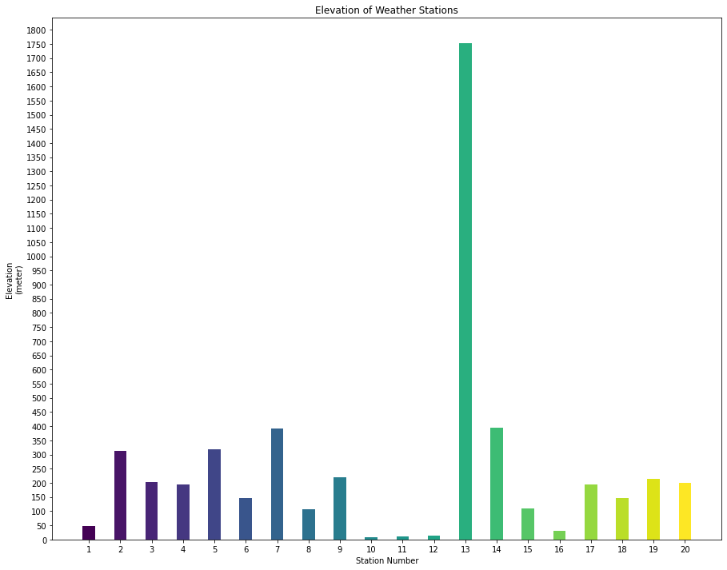

```python
plt.figure(figsize=(15, 12))
my_cmap = plt.get_cmap("viridis")
rescale = lambda y: (y - np.min(pressure_station_df.index)) / (np.max(pressure_station_df.index) - np.min(pressure_station_df.index))
plt.bar(pressure_station_df.index, pressure_station_df['altitude(m)'], color =my_cmap(rescale(pressure_station_df.index)), width = 0.4)
plt.xticks(np.arange(min(pressure_station_df.index), max(pressure_station_df.index)+1, 1.0))
plt.yticks(np.arange(0, max(pressure_station_df['altitude(m)'])+50, 50))
plt.xlabel('Station Number')
plt.ylabel('Elevation\n(meter)')
plt.title('Elevation of Weather Stations')
plt.show()
```

## Section F

We will use K Means algorithm to cluster the data of the weather stations

the weather dataframe:

```python
weather_df
```

|  | station_nbr | tavg | cool | sunrise | sunset | snowfall | preciptotal | stnpressure | sealevel | resultspeed | ... | TSSN SN BR UP | TSSN UP VCTS | UP | UP BLSN | UP HZ | VCFG | VCTS | year | month | day |
| --- | --- | --- | --- | --- | --- | --- | --- | --- | --- | --- | --- | --- | --- | --- | --- | --- | --- | --- | --- | --- | --- |
| 0 | 1.0 | 42.0 | 0.0 | 673.203060 | 1658.590332 | 0.0 | 0.05 | 29.78 | 29.92 | 3.6 | ... | 0.0 | 0.0 | 0.0 | 0.0 | 0.0 | 0.0 | 0.0 | 2012.0 | 1.0 | 1.0 |
| 1 | 2.0 | 41.0 | 0.0 | 716.000000 | 1626.000000 | 0.0 | 0.07 | 28.82 | 29.91 | 9.1 | ... | 0.0 | 0.0 | 0.0 | 0.0 | 0.0 | 0.0 | 0.0 | 2012.0 | 1.0 | 1.0 |
| 2 | 3.0 | 45.0 | 0.0 | 735.000000 | 1720.000000 | 0.0 | 0.00 | 29.77 | 30.47 | 9.9 | ... | 0.0 | 0.0 | 0.0 | 0.0 | 0.0 | 0.0 | 0.0 | 2012.0 | 1.0 | 1.0 |
| 3 | 4.0 | 55.0 | 0.0 | 728.000000 | 1742.000000 | 0.0 | 0.00 | 29.79 | 30.48 | 8.0 | ... | 0.0 | 0.0 | 0.0 | 0.0 | 0.0 | 0.0 | 0.0 | 2012.0 | 1.0 | 1.0 |
| 4 | 6.0 | 49.0 | 0.0 | 727.000000 | 1742.000000 | 0.0 | 0.00 | 29.95 | 30.47 | 14.0 | ... | 0.0 | 0.0 | 0.0 | 0.0 | 0.0 | 0.0 | 0.0 | 2012.0 | 1.0 | 1.0 |
| ... | ... | ... | ... | ... | ... | ... | ... | ... | ... | ... | ... | ... | ... | ... | ... | ... | ... | ... | ... | ... | ... |
| 20512 | 16.0 | 44.0 | 0.0 | 659.274077 | 1685.177153 | 0.0 | 0.00 | 29.90 | 29.99 | 4.5 | ... | 0.0 | 0.0 | 0.0 | 0.0 | 0.0 | 0.0 | 0.0 | 2014.0 | 10.0 | 31.0 |
| 20513 | 17.0 | 47.0 | 0.0 | 640.808551 | 1734.105631 | 0.0 | 0.00 | 29.72 | 30.39 | 9.2 | ... | 0.0 | 0.0 | 0.0 | 0.0 | 0.0 | 0.0 | 0.0 | 2014.0 | 10.0 | 31.0 |
| 20514 | 18.0 | 58.0 | 0.0 | 644.000000 | 1738.000000 | 0.0 | 0.00 | 29.78 | 30.28 | 10.6 | ... | 0.0 | 0.0 | 0.0 | 0.0 | 0.0 | 0.0 | 0.0 | 2014.0 | 10.0 | 31.0 |
| 20515 | 19.0 | 39.0 | 0.0 | 624.000000 | 1646.000000 | 0.1 | 0.02 | 29.51 | 30.24 | 20.4 | ... | 0.0 | 0.0 | 0.0 | 0.0 | 0.0 | 0.0 | 0.0 | 2014.0 | 10.0 | 31.0 |
| 20516 | 20.0 | 59.0 | 0.0 | 650.922962 | 1724.305255 | 0.0 | 0.00 | 29.57 | 30.27 | 10.5 | ... | 0.0 | 0.0 | 0.0 | 0.0 | 0.0 | 0.0 | 0.0 | 2014.0 | 10.0 | 31.0 |

20517 rows × 464 columns

Let's also Create a data frame that consists the average of every feature for every station_nbr

```python
grouped_weather_df=weather_df[weather_df.columns[0:13]]
grouped_weather_df=grouped_weather_df.groupby('station_nbr')[grouped_weather_df.columns[1:13]].agg('mean')
grouped_weather_df=grouped_weather_df.reset_index()
grouped_weather_df
```

|  | station_nbr | tavg | cool | sunrise | sunset | snowfall | preciptotal | stnpressure | sealevel | resultspeed | resultdir | avgspeed | depart |
| --- | --- | --- | --- | --- | --- | --- | --- | --- | --- | --- | --- | --- | --- |
| 0 | 1.0 | 52.302534 | 2.309052 | 539.952068 | 1783.043454 | 0.104737 | 0.097810 | 29.846075 | 30.013755 | 5.368729 | 20.353029 | 6.580770 | -0.173808 |
| 1 | 2.0 | 49.905044 | 1.624725 | 542.361608 | 1780.885209 | 0.212075 | 0.130586 | 28.908499 | 30.009118 | 8.241867 | 22.669970 | 9.707786 | 1.719891 |
| 2 | 3.0 | 62.633148 | 6.588028 | 605.385263 | 1834.296265 | 0.017519 | 0.085199 | 29.280267 | 29.997143 | 7.904831 | 18.615459 | 9.541967 | 0.828823 |
| 3 | 4.0 | 71.386180 | 9.918199 | 617.881048 | 1842.829308 | 0.000271 | 0.099903 | 29.318928 | 30.004476 | 3.431655 | 17.558512 | 5.139317 | 1.242478 |
| 4 | 5.0 | 63.834948 | 7.249864 | 536.125562 | 1775.611652 | 0.009937 | 0.044609 | 28.900099 | 30.017847 | 9.627966 | 20.458859 | 10.423338 | 1.619268 |
| 5 | 6.0 | 69.240312 | 8.729131 | 617.449565 | 1842.342599 | 0.000140 | 0.091012 | 29.479402 | 29.999005 | 6.751401 | 16.246377 | 7.921674 | 1.139916 |
| 6 | 7.0 | 62.955268 | 6.652891 | 534.894657 | 1781.068624 | 0.017243 | 0.096507 | 28.628712 | 29.991920 | 9.950131 | 17.953975 | 11.803819 | 1.502265 |
| 7 | 8.0 | 68.338857 | 9.423452 | 550.867908 | 1792.661480 | 0.000914 | 0.067672 | 29.654643 | 30.035629 | 4.822148 | 18.243614 | 5.441125 | 1.085357 |
| 8 | 9.0 | 48.922965 | 2.466292 | 544.042619 | 1784.657369 | 0.031289 | 0.082859 | 29.224242 | 29.995030 | 6.813798 | 21.111564 | 8.255626 | -3.122972 |
| 9 | 10.0 | 73.130717 | 10.131957 | 611.675048 | 1837.722206 | 0.000028 | 0.149760 | 30.023986 | 30.049972 | 6.716522 | 16.567150 | 8.401013 | 2.962467 |
| 10 | 11.0 | 69.676964 | 7.692213 | 611.505475 | 1839.514820 | 0.000010 | 0.142551 | 30.014164 | 30.057324 | 5.181791 | 17.040460 | 6.324401 | 1.118013 |
| 11 | 12.0 | 71.342118 | 8.693404 | 600.233862 | 1848.171651 | 0.000000 | 0.166309 | 30.008249 | 30.056469 | 5.233025 | 16.725833 | 6.376103 | 1.670486 |
| 12 | 13.0 | 51.921552 | 2.159059 | 596.234649 | 1802.830350 | 0.069169 | 0.046468 | 24.243412 | 29.973017 | 4.444541 | 19.344928 | 7.903569 | 0.011913 |
| 13 | 14.0 | 62.960139 | 6.469445 | 614.570194 | 1846.422731 | 0.019314 | 0.104995 | 28.612727 | 29.989994 | 9.253408 | 17.541766 | 11.162984 | 1.727771 |
| 14 | 15.0 | 48.154022 | 1.457337 | 539.364625 | 1780.795045 | 0.181869 | 0.114137 | 29.618016 | 30.002512 | 4.306040 | 22.829611 | 5.329571 | 1.149652 |
| 15 | 16.0 | 51.217059 | 1.887558 | 557.641401 | 1799.315186 | 0.075291 | 0.111857 | 29.871023 | 29.981264 | 5.965680 | 21.070866 | 7.341346 | 0.467680 |
| 16 | 17.0 | 62.571086 | 6.461922 | 567.875748 | 1834.733108 | 0.020261 | 0.084780 | 29.342249 | 30.031679 | 5.256064 | 16.249385 | 6.264902 | 1.695536 |
| 17 | 18.0 | 69.381867 | 9.429952 | 610.215902 | 1842.204658 | 0.005396 | 0.082083 | 29.486322 | 30.000080 | 7.894976 | 17.689855 | 9.428230 | 1.615215 |
| 18 | 19.0 | 49.424873 | 2.132027 | 548.224309 | 1788.601606 | 0.134541 | 0.097334 | 29.253978 | 30.012183 | 7.674589 | 19.005797 | 9.309136 | 0.672092 |
| 19 | 20.0 | 68.723392 | 8.973598 | 576.800419 | 1846.907959 | 0.003765 | 0.083123 | 29.288054 | 29.995001 | 6.401032 | 18.026806 | 7.988563 | 1.908968 |

Also create a dataframe that consists only the staion numbers

```python
stations_df=weather_df['station_nbr']
```

Since station_nbr is a categorial feature, we will use one hot encoding to transform it to numeric feature

```python
encoded = pd.get_dummies(weather_df['station_nbr'], drop_first=True, prefix='station_nbr')
weather_df.drop('station_nbr', axis=1, inplace=True)
weather_df = pd.concat([weather_df, encoded], axis=1)
weather_df
```

|  | tavg | cool | sunrise | sunset | snowfall | preciptotal | stnpressure | sealevel | resultspeed | resultdir | ... | station_nbr_11.0 | station_nbr_12.0 | station_nbr_13.0 | station_nbr_14.0 | station_nbr_15.0 | station_nbr_16.0 | station_nbr_17.0 | station_nbr_18.0 | station_nbr_19.0 | station_nbr_20.0 |
| --- | --- | --- | --- | --- | --- | --- | --- | --- | --- | --- | --- | --- | --- | --- | --- | --- | --- | --- | --- | --- | --- |
| 0 | 42.0 | 0.0 | 673.203060 | 1658.590332 | 0.0 | 0.05 | 29.78 | 29.92 | 3.6 | 20.0 | ... | 0 | 0 | 0 | 0 | 0 | 0 | 0 | 0 | 0 | 0 |
| 1 | 41.0 | 0.0 | 716.000000 | 1626.000000 | 0.0 | 0.07 | 28.82 | 29.91 | 9.1 | 23.0 | ... | 0 | 0 | 0 | 0 | 0 | 0 | 0 | 0 | 0 | 0 |
| 2 | 45.0 | 0.0 | 735.000000 | 1720.000000 | 0.0 | 0.00 | 29.77 | 30.47 | 9.9 | 31.0 | ... | 0 | 0 | 0 | 0 | 0 | 0 | 0 | 0 | 0 | 0 |
| 3 | 55.0 | 0.0 | 728.000000 | 1742.000000 | 0.0 | 0.00 | 29.79 | 30.48 | 8.0 | 35.0 | ... | 0 | 0 | 0 | 0 | 0 | 0 | 0 | 0 | 0 | 0 |
| 4 | 49.0 | 0.0 | 727.000000 | 1742.000000 | 0.0 | 0.00 | 29.95 | 30.47 | 14.0 | 36.0 | ... | 0 | 0 | 0 | 0 | 0 | 0 | 0 | 0 | 0 | 0 |
| ... | ... | ... | ... | ... | ... | ... | ... | ... | ... | ... | ... | ... | ... | ... | ... | ... | ... | ... | ... | ... | ... |
| 20512 | 44.0 | 0.0 | 659.274077 | 1685.177153 | 0.0 | 0.00 | 29.90 | 29.99 | 4.5 | 3.0 | ... | 0 | 0 | 0 | 0 | 0 | 1 | 0 | 0 | 0 | 0 |
| 20513 | 47.0 | 0.0 | 640.808551 | 1734.105631 | 0.0 | 0.00 | 29.72 | 30.39 | 9.2 | 1.0 | ... | 0 | 0 | 0 | 0 | 0 | 0 | 1 | 0 | 0 | 0 |
| 20514 | 58.0 | 0.0 | 644.000000 | 1738.000000 | 0.0 | 0.00 | 29.78 | 30.28 | 10.6 | 36.0 | ... | 0 | 0 | 0 | 0 | 0 | 0 | 0 | 1 | 0 | 0 |
| 20515 | 39.0 | 0.0 | 624.000000 | 1646.000000 | 0.1 | 0.02 | 29.51 | 30.24 | 20.4 | 34.0 | ... | 0 | 0 | 0 | 0 | 0 | 0 | 0 | 0 | 1 | 0 |
| 20516 | 59.0 | 0.0 | 650.922962 | 1724.305255 | 0.0 | 0.00 | 29.57 | 30.27 | 10.5 | 36.0 | ... | 0 | 0 | 0 | 0 | 0 | 0 | 0 | 0 | 0 | 1 |

20517 rows × 482 columns

Import relevant packages

```python
from sklearn.cluster import KMeans
from scipy.spatial.distance import cdist
import warnings
warnings.filterwarnings('ignore')
```

To select the best value of K for our dataset, we first define a function to create an elbow plot.

```python
def elbow(df):

    distortions = []
    K = range(1,10)
    for k in K:
        kmeanModel = KMeans(n_clusters=k).fit(df)
        kmeanModel.fit(df)
        distortions.append(sum(np.min(cdist(df, kmeanModel.cluster_centers_, 'euclidean'), axis=1)) / df.shape[0])

    # Plot the elbow
    plt.plot(K, distortions, 'bx-')
    plt.xlabel('k')
    plt.ylabel('sum of squares')
    plt.title('The Elbow Method showing the optimal k')
    plt.show()
```

Fit the model

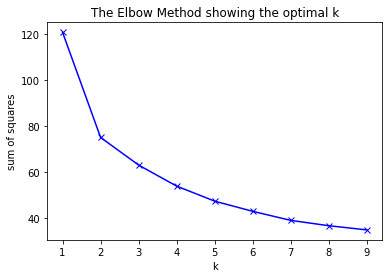

```python
elbow(weather_df)
```

We can see the best number of clusters to use is 5 , so we use K=5

```python
kmeans = KMeans(n_clusters=5, random_state=0).fit(weather_df)
```

Print the clusters' centroids:

```python
centroids = kmeans.cluster_centers_
print(centroids)
```

[output not shown]

Getting the labels for every observation

```python
kmeans = KMeans(5, random_state=0)
labels = kmeans.fit_predict(weather_df)
weather_df
```

[output not shown]

20517 rows × 483 columns

Plotting the clusters

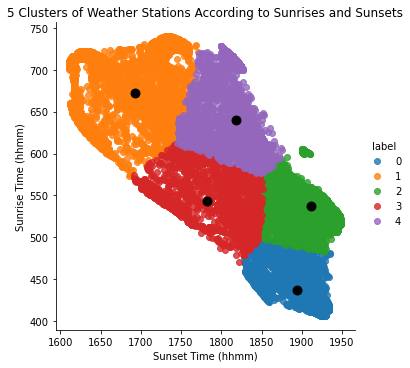

```python
weather_df['label']=labels
sns.lmplot(data=weather_df, x='sunset', y='sunrise', hue='label',
                   fit_reg=False, legend=True)
plt.scatter(centroids[:,3] , centroids[:,2] , s = 80, color = 'k')
plt.xlabel('Sunset Time (hhmm)')
plt.ylabel('Sunrise Time (hhmm)')
plt.title("5 Clusters of Weather Stations According to Sunrises and Sunsets")
```

Every color is a cluster, every black dot is a center of a cluster

We can see that we have clusters of late sunrises and early sunsets, grdually going down to early sunrises and late sunsets.  
Probably because of differences between seasons.

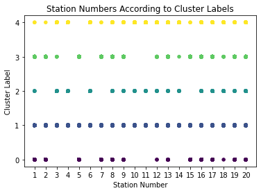

```python
plt.scatter(stations_df, weather_df['label'], c=labels, s=20, cmap='viridis')
plt.xlabel('Station Number')
plt.ylabel('Cluster Label')
plt.title("Station Numbers According to Cluster Labels")
plt.xticks(np.arange(min(stations_df), max(stations_df)+1, 1))
plt.yticks(np.arange(min(weather_df['label']), max(weather_df['label'])+1, 1))
plt.show()
```

We can see the stations that consist every cluster.

Now we will use clustering on different features to explore the similarities and differences between stations.

Cluster according to average temperature and average wind speed:

```python
temp_stations=grouped_weather_df[['avgspeed','tavg']]
temp_stations
```

|  | avgspeed | tavg |
| --- | --- | --- |
| 0 | 6.580770 | 52.302534 |
| 1 | 9.707786 | 49.905044 |
| 2 | 9.541967 | 62.633148 |
| 3 | 5.139317 | 71.386180 |
| 4 | 10.423338 | 63.834948 |
| 5 | 7.921674 | 69.240312 |
| 6 | 11.803819 | 62.955268 |
| 7 | 5.441125 | 68.338857 |
| 8 | 8.255626 | 48.922965 |
| 9 | 8.401013 | 73.130717 |
| 10 | 6.324401 | 69.676964 |
| 11 | 6.376103 | 71.342118 |
| 12 | 7.903569 | 51.921552 |
| 13 | 11.162984 | 62.960139 |
| 14 | 5.329571 | 48.154022 |
| 15 | 7.341346 | 51.217059 |
| 16 | 6.264902 | 62.571086 |
| 17 | 9.428230 | 69.381867 |
| 18 | 9.309136 | 49.424873 |
| 19 | 7.988563 | 68.723392 |

Fit the model

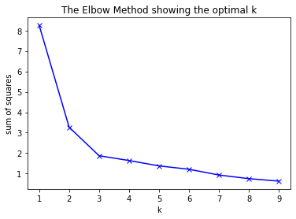

```python
elbow(temp_stations)
```

We can see the best number of clusters to use is 3 , so we use K=3

```python
kmeans = KMeans(n_clusters=3, random_state=0).fit(temp_stations)
```

Print the clusters' centroids:

```python
centroids = kmeans.cluster_centers_
print(centroids)
```

```
[[ 7.77540048 50.2640071 ]
 [ 7.1275533  70.15255094]
 [ 9.83940199 62.99091785]]
```

Getting the labels for every observation

```python
kmeans = KMeans(3, random_state=0)
labels = kmeans.fit_predict(temp_stations)
```

Plotting the clusters

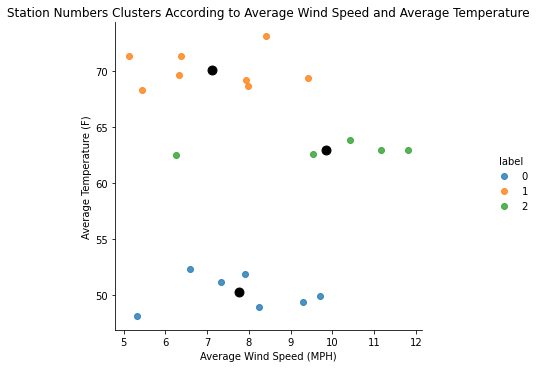

```python
temp_stations['label']=labels
sns.lmplot(data=temp_stations, x='avgspeed', y='tavg', hue='label',
                   fit_reg=False, legend=True)
plt.scatter(centroids[:,0] , centroids[:,1] , s = 80, color = 'k')
plt.xlabel('Average Wind Speed (MPH)')
plt.ylabel('Average Temperature (F)')
plt.title("Station Numbers Clusters According to Average Wind Speed and Average Temperature")
```

We can see that we have 3 clusters of stations according to average temperature and average wind speed.  
The black dots are the centroids of evert cluster.  
Cluster 1 (orange) are stations with higer temperature and slower winds, probably in the souther part of USA.  
Cluster 0 (blue) are stations with lower temperature and faster winds, probably in the norther part of USA.

Cluster according to average temperature and altitude:

We will use the altitude estimation from section E and create a joined dataframe of avg temperature and altitude data frame

```python
altitude=pressure_station_df['altitude(m)']
altitude_df=pd.DataFrame(altitude)
altitude_df=altitude_df.reset_index()
altitude_df
```

|  | station_nbr | altitude(m) |
| --- | --- | --- |
| 0 | 1.0 | 47.235610 |
| 1 | 2.0 | 314.090227 |
| 2 | 3.0 | 203.578443 |
| 3 | 4.0 | 194.549876 |
| 4 | 5.0 | 318.960058 |
| 5 | 6.0 | 147.148722 |
| 6 | 7.0 | 390.682870 |
| 7 | 8.0 | 107.557077 |
| 8 | 9.0 | 219.066579 |
| 9 | 10.0 | 7.297280 |
| 10 | 11.0 | 12.120231 |
| 11 | 12.0 | 13.542638 |
| 12 | 13.0 | 1754.027250 |
| 13 | 14.0 | 394.815421 |
| 14 | 15.0 | 108.673548 |
| 15 | 16.0 | 31.064761 |
| 16 | 17.0 | 195.483214 |
| 17 | 18.0 | 145.476594 |
| 18 | 19.0 | 215.328319 |
| 19 | 20.0 | 200.745811 |

Inner join both dataframes according to station numbers to merge them

```python
temp_altitude_stations=grouped_weather_df[['station_nbr','tavg']]
temp_altitude_stations=pd.merge(temp_altitude_stations, altitude_df, on=['station_nbr'])
temp_altitude_stations.drop('station_nbr', axis=1, inplace=True)
temp_altitude_stations
```

|  | tavg | altitude(m) |
| --- | --- | --- |
| 0 | 52.302534 | 47.235610 |
| 1 | 49.905044 | 314.090227 |
| 2 | 62.633148 | 203.578443 |
| 3 | 71.386180 | 194.549876 |
| 4 | 63.834948 | 318.960058 |
| 5 | 69.240312 | 147.148722 |
| 6 | 62.955268 | 390.682870 |
| 7 | 68.338857 | 107.557077 |
| 8 | 48.922965 | 219.066579 |
| 9 | 73.130717 | 7.297280 |
| 10 | 69.676964 | 12.120231 |
| 11 | 71.342118 | 13.542638 |
| 12 | 51.921552 | 1754.027250 |
| 13 | 62.960139 | 394.815421 |
| 14 | 48.154022 | 108.673548 |
| 15 | 51.217059 | 31.064761 |
| 16 | 62.571086 | 195.483214 |
| 17 | 69.381867 | 145.476594 |
| 18 | 49.424873 | 215.328319 |
| 19 | 68.723392 | 200.745811 |

Fit the model

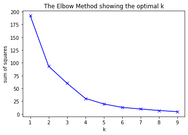

```python
elbow(temp_altitude_stations)
```

We can see the best number of clusters to use is 4 , so we use K=4

```python
kmeans = KMeans(n_clusters=4, random_state=0).fit(temp_altitude_stations)
```

Print the clusters' centroids:

```python
centroids = kmeans.cluster_centers_
print(centroids)
```

[output not shown]

Getting the labels for every observation

```python
kmeans = KMeans(4, random_state=0)
labels = kmeans.fit_predict(temp_altitude_stations)
```

Plotting the clusters

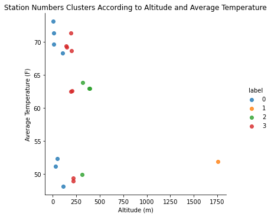

```python
temp_altitude_stations['label']=labels
sns.lmplot(data=temp_altitude_stations, x='altitude(m)', y='tavg', hue='label',
                   fit_reg=False, legend=True)
plt.xlabel('Altitude (m)')
plt.ylabel('Average Temperature (F)')
plt.title("Station Numbers Clusters According to Altitude and Average Temperature")
```